# Ch. 2 Cartesian Tensors — fluidpy

[▶ Open in Colab](https://colab.research.google.com/github/shammun/fluidpy/blob/main/notebooks/ch02_cartesian_tensors_colab.ipynb) ↓ Download .ipynb [View on GitHub](https://github.com/shammun/fluidpy/blob/main/notebooks/ch02_cartesian_tensors.ipynb)

## Interactive explainers in this chapter

🎮 1**Which rotates — the arrow or the ruler?**Turn the axes under a fixed vector (or a fixed stress state) and watch the direction-cosine matrix C, the new components x' = Cᵀx and the tensor components τ' = CᵀτC move together — one rule applied once per index.🎮 2**Cut the point any way you like: what pushes on the cut?**Drag the normal n of a cut through a stressed point: the traction f = n·τ, its normal and shear parts, the Mohr point and the σ_n(φ), τ_s(φ) curves move together; the two shear-free cuts are the eigenvectors, and their normal stresses bound everything.🎮 3**Is simple shear a rotation?**A square of fluid carried by u = G·x deforms and spins at once; the same square under S = ½(G + Gᵀ) only stretches, under A = ½(G − Gᵀ) only spins — three panels on one clock, the hidden vector ω of A, and the check that a symmetric tensor cannot see A.🎮 4**What leaks out of a box?**Move and resize a box over a plane field: the four face fluxes add up to exactly the divergence integrated inside; tile the box and watch the interior faces cancel; shrink it and watch the flux per area settle on the divergence.🎮 5**How much does the flow go round a loop?**Drag and resize a loop over a 2-D velocity field: the circulation ∮ u·t ds equals the curl integrated inside (Stokes, Eq. 2.34); a straight shear flow has it, an irrotational vortex has it only when the loop encloses its core; shrink the loop and Γ/A → (∇×u)·n (Eq. 2.35); tile the inside and watch the shared edges cancel.

# Chapter 2 — Cartesian Tensors

*Fluid Mechanics, 5th edition — Pijush K. Kundu, Ira M. Cohen, David R. Dowling (2012).* This notebook teaches every new idea of the chapter with plain words, step-by-step mathematics, small worked examples, tested Python from the `fluidpy` package, figures, animations and interactive explainers. It does not reproduce the book's text or figures; equations are cited by their numbers so you can follow along in your copy.

**The big idea in one paragraph**

A vector or a tensor is **one physical thing**; its components are what a particular set of axes sees. This chapter builds the index machinery (a repeated index is a sum), the rotation rule that *defines* vectors and tensors, the two tensors fluid mechanics runs on (the stress and the velocity gradient), and the two theorems that turn 'inside a volume' into 'on its boundary' (Gauss and Stokes). Everything here is mathematics, but it is the mathematics Ch. 3–5 and Ch. 13 are written in.

**Road map** — the new ideas of this chapter, in the order they build on each other:

1. §2.1–2.3 the summation convention (C01), the direction-cosine matrix (C02) and how components rotate (C03)
2. §2.4–2.6 the stress tensor and its signs (C04), Cauchy's traction f = n·τ (C05), the rule that makes τ a tensor (C06)
3. §2.5, 2.7, 2.8 contraction and invariants (C07); δ, ε and the cross product (C08)
4. §2.9 gradient, divergence, curl — on a grid you will reuse in every later chapter (C09–C11)
5. §2.10–2.11 symmetric + antisymmetric parts (C12); principal axes (C13)
6. §2.12–2.14 Gauss (C14, C15) and Stokes (C16); comma notation

**What you should already know** (each is recapped where it is used):

- vectors and matrices (Ch. 1 primers P53–P58 for determinants, rank, null space)
- partial derivatives (Ch. 1 P25) and the first-order Taylor expansion (P26)
- the definite integral (P27) and the trapezoid rule (P37)
- stress as force per area (Ch. 1 §1.3, P05) and the free-body diagram (P09)

## 🎮 Interactive explainers in this chapter

| # | Explainer | What it makes clear |
| --- | --- | --- |
| 1 | **Which rotates — the arrow or the ruler?** | C02 C03 C06: passive rotation, x' = Cᵀx, τ' = CᵀτC |
| 2 | **Cut the point any way you like: what pushes on the cut?** | C05 C13 C04: f = n·τ, Mohr's circle, principal axes |
| 3 | **Is simple shear a rotation?** | C12: G = S + A, the hidden vector of A |
| 4 | **What leaks out of a box?** | C14 C15: Gauss' theorem → divergence as outflux per volume |
| 5 | **How much does the flow go round a loop?** | C16 C11: Stokes' theorem → curl as circulation per area |

Each one opens right where its idea is taught and fills the window (no scrolling). Start with the **Walkthrough**, then **Explore** with the sliders and presets, read **Explain** (every number worked out with your settings, and what it means), step through the **Derivation** where there is one, read the **Equations** and the **Code**, and finish with **Check yourself**. On the web page they are full-window; in Colab and Jupyter they appear in the cell output (use ⤢ *Full screen* or *Open in new tab* for more room).

## ⚙️ Setup — run this cell first

It works in three places without changes:

- **Google Colab** — clones the public repository into `/content/fluidpy` (the `fluidpy` package, its tests and the interactive explainers) and installs the one package Colab lacks (`pint`). No GPU is needed.
- **Jupyter / VS Code on your computer** — finds the repository root (the folder with `book.yaml`) and imports from it.
- **The published web page** — already executed; nothing to run.

```python
# ── Setup: find (or fetch) the fluidpy repository, then load the house style ─────────────────────────────
import os, sys, subprocess, pathlib                     # standard library only, so this cell never fails on imports

IN_COLAB = "google.colab" in sys.modules                 # True when this notebook runs inside Google Colab
REPO_URL = "https://github.com/shammun/fluidpy.git"               # the public repository with the fluidpy package

if IN_COLAB:
    ROOT = pathlib.Path("/content/fluidpy")              # where the repository is cloned on Colab
    if not ROOT.exists():                                 # first run in this Colab session: clone it
        subprocess.run(["git", "clone", "--depth", "1", REPO_URL, str(ROOT)], check=True)
    else:                                                 # later runs: fetch the newest version
        subprocess.run(["git", "-C", str(ROOT), "pull", "--ff-only", "-q"], check=False)
    subprocess.run([sys.executable, "-m", "pip", "install", "-q", "-r", str(ROOT / "requirements-colab.txt")], check=True)
else:
    ROOT = pathlib.Path.cwd().resolve()                   # start where Jupyter was launched …
    while not (ROOT / "book.yaml").exists() and ROOT != ROOT.parent:
        ROOT = ROOT.parent                                # … and walk up until we find the repository root

os.chdir(ROOT)                                            # relative paths (outputs/, viz/) now resolve from the root
if str(ROOT) not in sys.path:
    sys.path.insert(0, str(ROOT))                         # make `import fluidpy` work

from fluidpy.core.style import setup_notebook            # matplotlib + plotly style shared with the explainers
from fluidpy.core.embed import show_viz                  # shows an interactive explainer in the notebook
from fluidpy.core.anim import show_animation             # plays a matplotlib animation inline
FAST = setup_notebook()                                   # FAST=True (env FLUIDPY_FAST=1) shrinks grids for quick runs
print(f"IN_COLAB = {IN_COLAB} | repository root: {ROOT} | FAST = {FAST}")
```

```
IN_COLAB = False | repository root: C:\Users\sislam27\Work\Climate Dynamics PHD\Fluid Dynamics | FAST = False
```

```python
from fluidpy import ch02_cartesian_tensors as ch02      # the tested chapter-2 module: every function cites its book section and equation
import numpy as np                                      # arrays (Ch. 1 primer P03)
import sympy as sp                                      # symbolic algebra (Ch. 1 primer P40)
import matplotlib.pyplot as plt                         # static figures (Ch. 1 primer P01)
import plotly.graph_objects as go                       # rotatable 3-D figures (Ch. 1 primer P41)
from fluidpy.core.style import COLORS                   # the house palette: teal = old axes, orange = new axes, blue = normal, rose = shear
import logging                                          # standard library: controls library log messages
logging.getLogger("matplotlib.font_manager").setLevel(logging.ERROR)   # hide harmless font-substitution notes (as in Ch. 1)
print(f"{len(ch02.__all__)} public functions in fluidpy.ch02_cartesian_tensors")   # the toolbox this notebook calls (f-string: Ch. 1 primer P04)
```

```
145 public functions in fluidpy.ch02_cartesian_tensors
```

**What does the code above do?**

1. `ch02` is the chapter module; it re-exports the reusable primitives of `fluidpy/core/` (tensors, index notation, grids, differential operators, integral theorems) so that one name covers the whole chapter.
2. The other imports are the Ch. 1 toolbox: numpy (P03), sympy (P40), matplotlib (P01) and plotly (P41), plus the shared colour palette.

**Notation used in this notebook.** Indices $i, j, k, l, m, n$ run over 1, 2, 3 (Python: 0, 1, 2 — we say which whenever a printed index appears). $\equiv$ means "is defined as". Boldface $\mathbf u$ is the object; $u_i$ its components. A superscript on an eigenvalue, $\lambda^k$, is a *label*, not a power. Colours: **teal** = the original axes, **orange** = rotated axes, **blue** = normal stress, **rose** = shear, **purple** = the quantity being taught.

**Where this chapter is used later**

| Result here | Used in |
| --- | --- |
| the tensor rule $\tau'_{mn} = C_{im}C_{jn}\tau_{ij}$ (2.12) | Ch. 3 strain rate, Ch. 4 stress, Ch. 12 Reynolds stress |
| Cauchy's formula $\mathbf f = \mathbf n\cdot\boldsymbol\tau$ (2.15) | Ch. 4 §4.3 wall forces, Ch. 8–9 drag and skin friction |
| $\varepsilon_{ijk} = \pm1$ or $0$ (2.18) | Ch. 4 Coriolis $2\boldsymbol\Omega\times\mathbf u$, Ch. 5 vorticity identities |
| Gauss, $\iiint_V \partial Q/\partial x_i\,dV = \iint_A n_iQ\,dA$ (2.30) | Ch. 4 §4.2 continuity, every conservation law in differential form |
| Stokes, $\iint_A(\nabla\times\mathbf u)\cdot\mathbf n\,dA = \oint_C\mathbf u\cdot\mathbf t\,ds$ (2.34) | Ch. 5 Kelvin's theorem, Ch. 6 and 14 lift |

*Climate hook:* the Coriolis term and the geostrophic balance of Ch. 13 are one $\varepsilon_{ijk}$ and one $\nabla p$ away from what is built here.

## 2.1 Scalars, Vectors, Tensors, Notation

**What is this section about?** Three kinds of quantity (one number, three numbers, nine numbers), the index notation that writes all of them as symbols with subscripts, and the one convention — a repeated index means "add over 1, 2, 3" — that lets the whole book drop its Σ signs.

📝 **Note.** **A scalar (zero-order tensor)** `N01` — is one number at each point, the same whatever axes you choose: pressure $p$, temperature $T$, density $\rho$ — the fields of Ch. 1. Zero free indices.

📝 **Note.** **A vector (first-order tensor)** `N02` — has a size and a direction: position $\mathbf x$, velocity $\mathbf u$, gravity $\mathbf g$. Its three components $u_1, u_2, u_3$ depend on the axes; the arrow does not. §2.2 sharpens this into a test (C03).

📝 **Note.** **A second-order tensor** `N06` — has one component for each *pair* of directions, $3\times3 = 9$: the stress $\tau_{ij}$ (which face, which force direction — C04). Two free indices.

📝 **Note.** **Hierarchy 1 → 3 → 9** `N24` — Newtonian fluid mechanics needs orders 0–2, with one fourth-order exception: the viscosity tensor of Ch. 4 §4.5 (N28).

### 🧩 The summation convention: a repeated index is a sum `C01`

*The question:* Why does the book never write a Σ sign — and how do you read $a_i b_i$, $A_{ik}B_{kj}$ or $C_{im}C_{jn}\tau_{ij}$ without one?

#### The problem in plain words

Every equation of fluid mechanics is really three or nine equations at once (one per direction, one per pair). Written out, the momentum equation fills a page; in index notation it is one line. The price is a reading rule you must run in your head: **if a letter appears twice in a term, add that term up for the letter = 1, 2, 3.** Once the rule is automatic, $\tau_{ji}n_j$ *is* a matrix–vector product and $\partial u_i/\partial x_i$ *is* the divergence.

#### The idea

```
a_i b_i        →  i is repeated     →  a_1 b_1 + a_2 b_2 + a_3 b_3            (one number:   no free index)
A_ik B_kj      →  k is repeated     →  A_i1 B_1j + A_i2 B_2j + A_i3 B_3j      (nine numbers: free i, j)
C_im C_jn τ_ij →  i, j repeated     →  9 terms for each (m, n)                (nine numbers: free m, n)
```

**Free index = shape of the answer; repeated (dummy) index = a loop.** A dummy letter can be renamed at will ($a_ib_i = a_kb_k$); a free letter must match on both sides of an equation.

📝 **Note.** **The position vector in a basis** `N03` — $\mathbf x = \mathbf e_1 x_1 + \mathbf e_2 x_2 + \mathbf e_3 x_3$ — the position vector is its components times the unit vectors; the subscript on $\mathbf e$ names an *axis*, not a component. In code `ch02.unit_vectors()` returns the three $\mathbf e_i$ as rows and `ch02.vector_from_components(x, E)` rebuilds the arrow. **Column form** `N04`: the book also writes $\mathbf x = [x_1\ x_2\ x_3]^{\rm T}$ (the transpose ᵀ turns a row into a column) or a triplet $(x_1, x_2, x_3)$ — in code `x = np.array([1., 2., 3.])`, `x.T`.

$$ \mathbf x = \mathbf e_1 x_1 + \mathbf e_2 x_2 + \mathbf e_3 x_3 \qquad \text{(2.1)} $$

> 📎 **Primer — np.einsum index strings.** `P62` · The code form of the summation convention: `np.einsum('i,i', a, b)` sums over the repeated letter i; `'ik,kj->ij'` sums over k and keeps i, j; the letters after `->` are the free indices (the shape of the answer). Nothing else is needed to write any formula of this chapter.

```python
a, b = np.array([1., 2., 3.]), np.array([4., 5., 6.])      # two vectors (any unit)
print(np.einsum('i,i', a, b))                              # 32.0 = 4 + 10 + 18: the repeated i is summed
A = np.arange(9.).reshape(3, 3)                            # a 3×3 matrix 0…8
print(np.einsum('ik,kj->ij', A, A)[0, 1])                  # P_12 = A_1k A_k2 (Python row 0, column 1) = 0·1 + 1·4 + 2·7 = 18
```

```
32.0
18.0
```

> 📎 **Primer — matrix multiplication, transpose and identity.** `P63` · Row-by-column: $(AB)_{ij} = \sum_k A_{ik}B_{kj}$ — walk along row i of A and down column j of B, multiply pairs, add. In Python `A @ B`; `A.T` swaps rows and columns ($A^{\rm T}_{ij} = A_{ji}$); `np.eye(3)` is the identity (1 on the diagonal, 0 elsewhere) — it leaves any matrix unchanged.

```python
A = np.array([[1., 2.], [3., 4.]]); B = np.array([[0., 1.], [1., 0.]])   # two 2×2 matrices
print(A @ B)             # [[2, 1], [4, 3]]: row i of A · column j of B
print(A.T)               # [[1, 3], [2, 4]]: rows and columns swapped
print(np.eye(2) @ A)     # A again: the identity changes nothing
```

```
[[2. 1.]
 [4. 3.]]
[[1. 3.]
 [2. 4.]]
[[1. 2.]
 [3. 4.]]
```

#### The maths, step by step (three equations expanded by hand)

1. **Dot product (2.2):** $\mathbf a\cdot\mathbf b = a_1b_1 + a_2b_2 + a_3b_3 = \sum_{i=1}^{3} a_ib_i \equiv a_ib_i$ — one repeated letter, one sum, a scalar.
2. **Matrix product (2.9):** $P_{ij} = \sum_{k=1}^{3} A_{ik}B_{kj} \equiv A_{ik}B_{kj}$ — k summed, i and j free, nine numbers.
3. **Kronecker substitution (2.17):** $\delta_{ij}u_j = \delta_{i1}u_1 + \delta_{i2}u_2 + \delta_{i3}u_3 = u_i$ — only the term with j = i survives, so δ *replaces* its summed index.

📝 **Note.** **The dot product as an implied sum** `N07` — the ≡ is the summation convention at work: the last form *means* the middle one. **Also** `N45`: $\mathbf u\cdot\mathbf v = uv\cos\theta$ (the projection of one vector on the other), and $\mathbf u\cdot\mathbf v$ is the trace of the nine products $u_iv_j$ — the contraction idea of §2.5 (C07); `ch02.angle_between(u, v)` returns θ.

$$ \mathbf a\cdot\mathbf b = a_1 b_1 + a_2 b_2 + a_3 b_3 = \sum_{i=1}^{3} a_i b_i \equiv a_i b_i \qquad \text{(2.2)} $$

📝 **Note.** **The Kronecker delta** `N40` — $\delta_{ij} = 1$ if $i = j$, 0 otherwise — the identity matrix in index clothes (`ch02.kronecker_delta()` is `np.eye(3)`). We need it now because the rotation matrix's orthogonality (C02) is written with it.

$$ \delta_{ij} = \begin{cases} 1 & i = j \\ 0 & i \neq j\end{cases} \qquad \text{(2.16)} $$

📝 **Note.** **δ substitutes its summed index** `N41` — $\delta_{ij}u_j = u_i$, $\delta_{ij}A_{jk} = A_{ik}$, and — the classic slip — $\delta_{ii} = 3$ (a summed pair), not 1.

$$ \delta_{ij} u_j = u_i \qquad \text{(2.17)} $$

📝 **Note.** **Matrix product as an index sum** `N21` — $P_{ij} = A_{ik}B_{kj}$ sums the *adjacent* index k; `ch02.inner(A, B)` is `np.einsum('ik,kj->ij')` and equals `A @ B`. **Single dot** `N22`: (2.10) $\mathbf P = \mathbf A\cdot\mathbf B$ — a single dot means one index summed, the same dot that later reads $\mathbf n\cdot\boldsymbol\tau$ (C05) and $\nabla\cdot\mathbf u$ (C10). **Explicitly** `N23`: (2.11) $P_{12} = A_{11}B_{12} + A_{12}B_{22} + A_{13}B_{32}$ — row 1 of A against column 2 of B; the figure below boxes them.

$$ P_{ij} = \sum_{k=1}^{3} A_{ik} B_{kj} \equiv A_{ik} B_{kj} \qquad \text{(2.9)} $$

📝 **Note.** **Boldface for meaning, indices for manipulation** `N08` — $\mathbf a\mathbf b$ is ambiguous for tensors ($\mathbf a\mathbf b \neq \mathbf b\mathbf a$) and hides the order; indices never do: **order = number of free indices**. `ch02.tensor_order('A_ij B_kl')` → 4. **Free vs dummy** `N12`: $x_iC_{ij} = x_kC_{kj}$ (rename the summed letter freely); the free j must appear on both sides. A letter appearing three times in one term is an error (`ch02.classify_indices` raises).

#### ✏️ Tiny example: (1, 2, 3)·(4, 5, 6) and δ_ij u_j for i = 2

1. $a_ib_i$ with i = 1, 2, 3: $1\times4 + 2\times5 + 3\times6 = 4 + 10 + 18 = 32$.
2. $\delta_{2j}u_j = \delta_{21}u_1 + \delta_{22}u_2 + \delta_{23}u_3 = 0 + u_2 + 0 = u_2$.
3. $P_{12}$ for $A = B = \begin{bmatrix}1&2&3\\4&5&6\\7&8&9\end{bmatrix}$: $1\cdot2 + 2\cdot5 + 3\cdot8 = 2 + 10 + 24 = 36$.

```python
a, b = np.array([1., 2., 3.]), np.array([4., 5., 6.])           # the two vectors of the tiny example
print(ch02.expand_indices_str("a_i b_i"))                       # the expander writes the hidden sum of (2.2): a_1*b_1 + a_2*b_2 + a_3*b_3
print(ch02.dot(a, b))                                           # (2.2) evaluated: 32.0 (dot = np.einsum('i,i'))
print(ch02.expand_indices_str("delta_ij u_j"))                  # (2.17): one line per free i — δ collapses the sum to u_i
A = np.arange(1., 10.).reshape(3, 3)                            # the 1…9 matrix of the example
print(ch02.inner(A, A)[0, 1], (A @ A)[0, 1])                    # (2.9)/(2.11): P_12 (Python [0, 1]) = 36.0, and `@` gives the same
print(ch02.classify_indices("x_i C_ij"), ch02.tensor_order("A_ij B_kl"))   # (free, dummy) = (['j'], ['i']); order 4
print(ch02.rename_dummy("x_i C_ij", "i", "k"))                  # renaming the summed letter: x_k C_kj — the same nine numbers
```

```
a_1*b_1 + a_2*b_2 + a_3*b_3
32.0
result_1 = u_1
result_2 = u_2
result_3 = u_3
36.0 36.0
(['j'], ['i']) 4
x_k C_kj
```

**What does the code above do?**

1. `expand_indices_str` parses the subscripts, finds the repeated letter and writes the hidden sum.
2. `dot` is `np.einsum('i,i')` — $\mathbf a\cdot\mathbf b = a_ib_i$ (2.2) as one call.
3. δ collapses the sum: for each free i only one term survives.
4. `inner` is $P_{ij} = A_{ik}B_{kj}$ (2.9) and equals the `@` operator (P63).
5. `classify_indices` splits free from dummy letters; `tensor_order` counts the free ones.
6. Renaming a dummy changes nothing (N12).

```python
mine = 0.0                                                   # from scratch: the sum the convention hides
for i in range(3):                                           # i = 1, 2, 3 (Python 0, 1, 2)
    mine += a[i] * b[i]                                      # add a_i b_i
assert np.allclose(mine, ch02.dot(a, b))                     # same 32 → dot is exactly this loop (Ch. 1 primer P15)
P = np.zeros((3, 3))                                         # P_ij = A_ik A_kj, built term by term
for i in range(3):                                           # free index i …
    for j in range(3):                                       # … free index j: the shape of the answer
        for k in range(3):                                   # dummy k: the loop
            P[i, j] += A[i, k] * A[k, j]                     # one term of (2.9)
assert np.allclose(P, ch02.inner(A, A))                      # the library does the same
assert np.allclose(P, np.einsum('ik,kj->ij', A, A))          # and so does einsum (P62)
print("the triple loop IS the summation convention; einsum only writes it faster")
```

```
the triple loop IS the summation convention; einsum only writes it faster
```

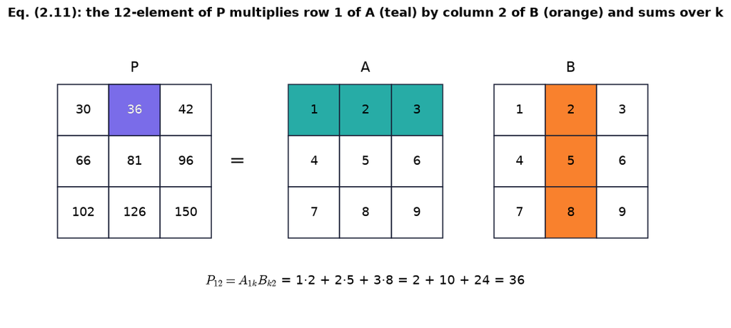

```python
from scripts.ch02_matrix_product_highlight import matrix_product_figure   # drawing helper (no physics) for Eq. (2.11)
fig = matrix_product_figure(i=1, j=2, A=A, B=A)                          # book indices: row 1 of A (teal) × column 2 of B (orange) → P_12
plt.show()                                                               # the three boxed products and their sum 36
```

**What you see.** Three boxed pairs, one sum: the highlighted row of A and column of B, the three products written out and their total under the cell $P_{12}$.

**How to read it.** The highlighted row and column are the two copies of the dummy k walking together: $A_{1k}$ and $B_{k2}$ for k = 1, 2, 3.

**What would change if…** pick i = 3, j = 1: row 3 and column 1 light up and $P_{31} = 7\cdot1 + 8\cdot4 + 9\cdot7 = 102$ (`matrix_product_figure(i=3, j=1, A=A, B=A)`).

> 📎 **Primer — plotly 3-D arrows, lines and meshes.** `P64` · Ch. 1 used `go.Surface` and `go.Scatter3d` points. Arrows are `go.Cone(x, y, z, u, v, w)` (position and direction), edges are `go.Scatter3d(mode='lines')`, faces are `go.Mesh3d` (vertices + triangles). All stay rotatable on the published page. `scripts.ch02_drawings.plotly_arrow` bundles one shaft line and one cone into an arrow.

```python
fig = go.Figure(go.Cone(x=[0], y=[0], z=[0], u=[1], v=[0], w=[0], sizemode='absolute', sizeref=0.5))   # one cone at the origin pointing along x
fig.update_layout(height=250, scene_aspectmode='cube', margin=dict(l=0, r=0, t=0, b=0))               # a small cubic scene
fig.show()                                                                                            # drag to rotate
```

[interactive chart not shown]

```python
from scripts.ch02_drawings import plotly_arrow, plotly_layout_3d   # drawing helpers (P64): arrow = shaft + cone; equal-aspect layout
x = np.array([1., 2., 3.])                                         # the running position vector OP (any unit)
E = ch02.unit_vectors()                                            # rows e_1, e_2, e_3 (2.1)
assert np.allclose(ch02.vector_from_components(x, E), x)           # (2.1): x = e_1 x_1 + e_2 x_2 + e_3 x_3 rebuilds the same array
fig = go.Figure()                                                  # our own Fig. 2.1
for k in range(3):                                                 # the three unit vectors, teal
    fig.add_traces(plotly_arrow((0, 0, 0), E[k], COLORS["teal"], name="unit vectors e_i", showlegend=(k == 0)))
fig.add_traces(plotly_arrow((0, 0, 0), x, COLORS["accent"], name="x = OP", showlegend=True, width=7))   # the arrow itself, purple
foot = np.array([x[0], x[1], 0.])                                  # the shadow of P on the x_1 x_2 plane
for a_, b_ in (((0, 0, 0), foot), (foot, x), ((x[0], 0, 0), foot), ((0, x[1], 0), foot)):   # dashed projections
    fig.add_trace(go.Scatter3d(x=[a_[0], b_[0]], y=[a_[1], b_[1]], z=[a_[2], b_[2]], mode="lines",
                               line=dict(color=COLORS["muted"], dash="dash"), showlegend=False, hoverinfo="skip"))
plotly_layout_3d(fig, ((-0.3, 3.3),) * 3, title="Eq. (2.1): one arrow, three shadows x₁ = 1, x₂ = 2, x₃ = 3", height=480)
fig.show()                                                         # rotate it: the shadows are the components
```

[interactive chart not shown]

**What does the code above do?**

1. `unit_vectors` gives the basis $\mathbf e_i$ as rows; `vector_from_components` performs $\mathbf x = x_i\mathbf e_i$ (2.1) and returns the same array we started from — the equation is a reconstruction rule.
2. The rest is drawing (P64): three teal unit arrows, the purple arrow OP and the dashed shadows that mark $x_1$, $x_2$ and $x_3$. `N05`: this is our own version of the book's Fig. 2.1.

**What you see.** One purple arrow from the origin to P = (1, 2, 3); its dashed shadows drop onto the $x_1x_2$ plane and then onto the axes; three short teal arrows are the unit vectors.

**How to read it.** The numbers (1, 2, 3) are the *shadows* of one arrow on three rulers. Rotate the view: the arrow is the same object however you look at it.

**What would change if…** …§2.2 changes the rulers: the same arrow will cast different shadows, and the rule connecting the two sets of shadows is the whole point of the chapter.

**What would change if…** you meet $\varepsilon_{ijk}u_iv_j$ (§2.7)? The same rule: i and j are summed (nine terms), k is free — a vector. And $\partial u_i/\partial x_i$ (§2.9) is a sum of three derivatives, a scalar. Every later formula is read this way; try `ch02.expand_indices_str` on it when in doubt.

## 2.2 Rotation of Axes: Formal Definition of a Vector

**What is this section about?** Keep the arrow, turn the rulers. The nine cosines between old and new axes form a matrix C; the components of *any* vector change by the same rule x' = Cᵀx — and that rule becomes the definition of a vector.

### 🧩 The direction-cosine matrix C_ij = e_i · e'_j `C02`

*The question:* Two sets of axes share an origin. What is the one table of numbers that relates them — and what does a single entry $C_{ij}$ measure?

#### The problem in plain words

A weather model uses axes east/north/up; a wind sensor on a tilted mast reports its own three components; a stress calculation wants axes normal and tangent to a wall. Same wind, same stress, different numbers. We need the dictionary between two frames — and it turns out to be nine cosines.

#### The idea

```
old axes  e_1, e_2, e_3  (teal)        new axes  e'_1, e'_2, e'_3  (orange), same origin O
C_ij = e_i · e'_j = cos(angle between old axis i and new axis j)
row i    = "how much of old axis i lies along each new axis"
column j = "the new axis e'_j written in old components"     ← the whole matrix, one picture
```

For a turn by θ about $\mathbf e_3$: $\mathbf e'_1 = (\cos\theta, \sin\theta, 0)$, $\mathbf e'_2 = (-\sin\theta, \cos\theta, 0)$, $\mathbf e'_3 = \mathbf e_3$ — these are the **columns** of C.

📝 **Note.** **The rotated frame** `N09` — O1'2'3' shares the origin; its unit vectors are $\mathbf e'_j$; the vector $\mathbf x$ is *the same arrow* with new components $x'_j$. **Fig. 2.2** `N17` is our own 3-D drawing below (two frames, one arrow) and the animation after it.

📝 **Note.** **The same vector in the primed basis** `N10` — $\mathbf x = x'_1\mathbf e'_1 + x'_2\mathbf e'_2 + x'_3\mathbf e'_3$ — the same vector spelled in the primed basis; in code `ch02.vector_from_components(xp, E_new)` rebuilds the very same array as `ch02.vector_from_components(x, E_old)`.

$$ \mathbf x = x'_1 \mathbf e'_1 + x'_2 \mathbf e'_2 + x'_3 \mathbf e'_3 \qquad \text{(2.3)} $$

> 📎 **Primer — orthonormal basis, projection and completeness.** `P65` · A basis is orthonormal when each vector has length 1 and any two are perpendicular: $\mathbf e_i\cdot\mathbf e_j = \delta_{ij}$. The component of a vector along a unit vector is the dot product (its projection). **Completeness**: a vector is the sum of its projections, $\mathbf v = \sum_j (\mathbf v\cdot\mathbf e'_j)\,\mathbf e'_j$ — nothing is lost, because three perpendicular unit vectors span 3-D space.

```python
E = ch02.rotation_matrix_3d([0, 0, 1], np.deg2rad(30)).T    # rows = the new unit vectors of a frame turned 30° about e_3
print(np.round(E @ E.T, 12))                                # the identity: each row has length 1, rows are perpendicular → orthonormal
v = np.array([1., 2., 3.])                                  # any vector
print(sum((v @ E[j]) * E[j] for j in range(3)))            # [1 2 3]: the sum of the three projections is v again (completeness)
```

```
[[1. 0. 0.]
 [0. 1. 0.]
 [0. 0. 1.]]
[1. 2. 3.]
```

> 📎 **Primer — cosines of angles between unit vectors.** `P66` · For unit vectors the dot product *is* the cosine of the angle between them. Two identities we use: $\cos(\pi/2 - \theta) = \sin\theta$ and $\cos(\theta + \pi/2) = -\sin\theta$. Python trigonometry works in radians: `np.deg2rad(30)` = 0.5236.

```python
th = np.deg2rad(30)                                  # 30° in radians
print(np.cos(np.pi/2 - th), np.sin(th))              # 0.5 0.5: the angle between e_2 and e'_1 is 90° − θ
print(np.cos(th + np.pi/2), -np.sin(th))             # -0.5 -0.5: the angle between e_1 and e'_2 is 90° + θ
```

```
0.4999999999999999 0.49999999999999994
-0.4999999999999998 -0.49999999999999994
```

> 📎 **Primer — np.linalg.norm and np.linalg.qr.** `P67` · `np.linalg.norm(v)` is the length $\sqrt{v_iv_i}$. `np.linalg.qr(M)` factors a matrix into an orthogonal Q and a triangular R — we use Q of a random matrix as a random rotation (after fixing det Q = +1), which is what `ch02.random_rotation` does.

```python
rng = np.random.default_rng(0)                       # seeded generator (Ch. 1 primer P10): reproducible "random" numbers
Q, _ = np.linalg.qr(rng.normal(size=(3, 3)))         # Q: the orthogonal factor of a random 3×3 matrix (tuple unpacking, Ch. 1 P14: `_` discards R)
print(np.round(Q.T @ Q, 12))                         # the identity: Q is orthogonal
print(np.linalg.norm(Q @ [3., 4., 0.]))              # 5.0: an orthogonal matrix keeps lengths (3-4-5 triangle)
```

```
[[ 1. -0. -0.]
 [-0.  1. -0.]
 [-0. -0.  1.]]
4.999999999999999
```

#### The maths, step by step

1. Define $C_{ij} \equiv \mathbf e_i\cdot\mathbf e'_j$ (nine numbers; dimensionless).
2. Column j of C is $\mathbf e'_j$ in old components: $(\mathbf e'_j)_i = \mathbf e_i\cdot\mathbf e'_j = C_{ij}$.
3. Row i of C is $\mathbf e_i$ in new components.
4. Because both bases are orthonormal, C is **orthogonal**: $C_{ij}C_{kj} = \delta_{ik}$ and $C_{ji}C_{jk} = \delta_{ik}$ — matrix form $\mathbf C\mathbf C^{\rm T} = \mathbf C^{\rm T}\mathbf C = \mathbf I$ (D02 below).
5. Hence $\mathbf C^{-1} = \mathbf C^{\rm T}$ and $\det\mathbf C = +1$ for a rotation (−1 would be a mirror).

#### 🧮 Derivation — Why C is orthogonal: C Cᵀ = Cᵀ C = I and det C = +1 (Exercise 2.8)

**What we want to show.** Show that the direction-cosine matrix undoes itself when transposed, so that going back to the old components is free (D03), lengths are preserved, and contracted index pairs of C become δ (D18). The book leaves this to Exercise 2.8.

**Assumptions.** Both bases orthonormal and complete in 3-D (steps 2, 4, 5) · "rotation" means reachable from the identity by turning (step 8).

**The plan.**

1. Expand an old unit vector in the new basis (completeness).
2. Dot with another old unit vector: δ on one side, a product of two C's on the other.
3. Repeat with the roles of the bases swapped.
4. Take determinants for the sign.

**Tools we use** (each explained before this point): completeness of an orthonormal basis, $\mathbf v = (\mathbf v\cdot\mathbf e'_j)\mathbf e'_j$ (P65) · orthonormality of both bases (P65) · bilinearity of the dot product (it distributes over sums; scalars pull out — D01 step 2 says it again) · matrix product as an index sum $P_{ij} = A_{ik}B_{kj}$ (2.9) (N21) · det(AB) = det A det B (Ch. 1 primer P53) · continuity argument for the sign (gloss in step 8)

**We start from**

$$ C_{ij} = \mathbf e_i\cdot\mathbf e'_j $$

*In words:* the definition of the direction cosines (C02).

**Step 1 of 8 — Write the product we want to evaluate.**

$$ C_{ij}C_{kj} = (\mathbf e_i\cdot\mathbf e'_j)(\mathbf e_k\cdot\mathbf e'_j) $$

- *Why we can do this:* Just the definition of C inserted twice; j is summed. We choose this product because it is $(\mathbf C\mathbf C^{\rm T})_{ik}$.
- *In words:* Row i of C dotted with row k of C.

**Step 2 of 8 — Expand $\mathbf e_i$ in the new basis.**

$$ \mathbf e_i = (\mathbf e_i\cdot\mathbf e'_j)\,\mathbf e'_j = C_{ij}\,\mathbf e'_j $$

- *Why we can do this:* Completeness: any vector is the sum of its projections on an orthonormal basis. We expand an *old* axis in *new* axes because that produces exactly a row of C.
- *In words:* An old axis is a sum of new axes weighted by its row of C.

**Step 3 of 8 — Dot with $\mathbf e_k$.**

$$ \mathbf e_i\cdot\mathbf e_k = C_{ij}\,(\mathbf e'_j\cdot\mathbf e_k) = C_{ij}C_{kj} $$

- *Why we can do this:* Bilinearity pulls $C_{ij}$ out; $\mathbf e'_j\cdot\mathbf e_k = \mathbf e_k\cdot\mathbf e'_j = C_{kj}$ by the definition of C. The right side is now the product of step 1.
- *In words:* The same product equals a dot product of two old axes.

**Step 4 of 8 — Use orthonormality of the old basis.**

$$ C_{ij}C_{kj} = \delta_{ik}\qquad(\mathbf C\mathbf C^{\rm T} = \mathbf I) $$

- *Why we can do this:* $\mathbf e_i\cdot\mathbf e_k = \delta_{ik}$ for perpendicular unit vectors. This is the first orthogonality relation; in matrix form the summed second indices make $\mathbf C\mathbf C^{\rm T}$.
- *In words:* The rows of C are perpendicular unit vectors.

**Step 5 of 8 — Swap the roles: expand a new axis in the old basis.**

$$ \mathbf e'_i = (\mathbf e'_i\cdot\mathbf e_j)\,\mathbf e_j = C_{ji}\,\mathbf e_j $$

- *Why we can do this:* Completeness again, now of the old basis. The second relation does not follow from the first without this second argument — a common gap.
- *In words:* A new axis is a sum of old axes weighted by its column of C.

**Step 6 of 8 — Dot with $\mathbf e'_k$ and use orthonormality of the new basis.**

$$ C_{ji}C_{jk} = \delta_{ik}\qquad(\mathbf C^{\rm T}\mathbf C = \mathbf I) $$

- *Why we can do this:* Bilinearity and $\mathbf e_j\cdot\mathbf e'_k = C_{jk}$ on the right; $\mathbf e'_i\cdot\mathbf e'_k = \delta_{ik}$ on the left. Now the *first* indices are summed.
- *In words:* The columns of C are perpendicular unit vectors too.

**Step 7 of 8 — Take the determinant of step 6.**

$$ (\det\mathbf C)^2 = 1\ \Rightarrow\ \det\mathbf C = \pm1 $$

- *Why we can do this:* det(AB) = det A · det B and det Cᵀ = det C, while det I = 1 — the determinant is the volume-scale factor of a linear map, and scale factors multiply (Ch. 1 P53 gave the cofactor recipe for computing it). We take determinants because the sign tells a rotation from a mirror.
- *In words:* C cannot stretch volumes; it may or may not flip them.

**Step 8 of 8 — Fix the sign for a rotation.**

$$ \det\mathbf C = +1 $$

- *Why we can do this:* Turning the axes gradually from θ = 0 changes det C continuously; it starts at det I = +1 and can never pass through 0 (it is ±1), so it stays +1. A mirror (−1) cannot be reached by turning.
- *In words:* A genuine rotation keeps the handedness of the axes.

**Result**

$$ C_{ij}C_{kj} = C_{ji}C_{jk} = \delta_{ik}, \qquad \det\mathbf C = +1 $$

*In words:* Cᵀ is the inverse of C, and C is a proper rotation.

**What it means.** A rotation is a relabelling of directions that loses nothing: lengths, angles and volumes are kept; the inverse costs a transpose (D03). Every time two C's share a summed index in a formula, they collapse to δ — the engine of D06 and D18. It fails for skewed or non-unit axes (then $\mathbf C^{-1} \neq \mathbf C^{\rm T}$).

**Check it.** θ = 30° in 2-D: row 1 · row 1 = 0.75 + 0.25 = 1, row 1 · row 2 = 0.866(0.5) + (−0.5)(0.866) = 0 ✓; det = 0.866² + 0.5² = 1 ✓ (`orthogonality_residual` ≈ 1e-17, `is_proper_rotation` True below). Limit: C = I trivially ✓. 200 random rotations from `random_rotation` all pass (code below).

> ⚠️ **Common confusion (traps in this derivation):** proving CᵀC = I and assuming CCᵀ = I "obviously" — for square matrices it is true, but the basis argument needs steps 5–6 to say why. A det of −1 passes the orthogonality test and is still not a rotation.

📝 **Note.** **Orthogonality of C** `N15` — the result of D02 — checked in code with `ch02.is_orthogonal(C)`, `ch02.orthogonality_residual(C)` (≈ 1e-16) and `ch02.is_proper_rotation(C)` (det +1).

$$ C_{ij} C_{kj} = C_{ji} C_{jk} = \delta_{ik}, \qquad \det \mathbf C = +1 \qquad \text{(Exercise 2.8)} $$

#### 🧮 Derivation — The inverse transformation x_j = x'_i C_ji (Eq. 2.7)

**What we want to show.** Get the old components back from the new ones — the book says "it can be shown (Exercise 2.2)".

**Assumptions.** Same as D01/D02: orthonormal bases (enters through D02 in step 2).

**The plan.**

1. Multiply by a C with the free index and sum.
2. Two C's with a shared summed index become δ (D02).
3. Let δ substitute.
4. Rename.

**Tools we use** (each explained before this point): dummy renaming (N12) · orthogonality $C_{ij}C_{kj} = \delta_{ik}$ (D02, C02) · Kronecker substitution $\delta_{ij}u_j = u_i$ (2.17) (N41)

**We start from**

$$ x'_j = x_iC_{ij} $$

*In words:* the forward rule (2.5) of D01 (derived in C03; here we only need that it holds).

**Step 1 of 4 — Multiply both sides by $C_{kj}$ and sum on j.**

$$ x'_j\,C_{kj} = x_i\,C_{ij}C_{kj} $$

- *Why we can do this:* Multiplying an identity by the same factor on both sides keeps it true; summing on the now-repeated j too. We choose $C_{kj}$ so that the C-pair on the right can collapse.
- *In words:* Contract the new components with a row of C.

**Step 2 of 4 — Collapse the C-pair with D02.**

$$ x'_j\,C_{kj} = x_i\,\delta_{ik} $$

- *Why we can do this:* Orthogonality $C_{ij}C_{kj} = \delta_{ik}$ (second indices summed) from D02 step 4. This is where "C is orthogonal" does its work.
- *In words:* The two C's cancel each other.

**Step 3 of 4 — Let δ substitute its summed index.**

$$ x_k = x'_j\,C_{kj} $$

- *Why we can do this:* Kronecker substitution (2.17): $x_i\delta_{ik} = x_k$. We now have an old component alone.
- *In words:* An old component is a weighted sum of the new ones.

**Step 4 of 4 — Rename the letters to the book's (k → j, j → i).**

$$ x_j = x'_i\,C_{ji} $$

- *Why we can do this:* Renaming a free index on both sides and a dummy anywhere changes nothing (N12); this is (2.7). Note the summed index of C is now its *second* one.
- *In words:* Going back uses C with its indices the other way round: x = C x'.

**Result**

$$ x_j = x'_iC_{ji}, \qquad \mathbf x = \mathbf C\,\mathbf x' $$

*In words:* the inverse of $\mathbf x' = \mathbf C^{\rm T}\mathbf x$ is multiplication by C itself, because $\mathbf C^{-1} = \mathbf C^{\rm T}$.

**What it means.** Rotating back is as cheap as rotating forward — no matrix inversion. In $x'_j = x_iC_{ij}$ (2.5) the first index of C is summed, in $x_j = x'_iC_{ji}$ (2.7) the second: the two index placements are the whole difference between C and Cᵀ.

**Check it.** Round trip with the D01 numbers: $x_1 = 1.866(0.866) + 1.232(-0.5) = 1.616 - 0.616 = 1.000$ ✓, $x_2 = 1.866(0.5) + 1.232(0.866) = 0.933 + 1.067 = 2.000$ ✓ (`inverse_transform_vector`). Limit θ = 0: identity ✓.

> ⚠️ **Common confusion (traps in this derivation):** using $x'_j = x_iC_{ij}$ (2.5) with the indices swapped and calling it the inverse without D02 — it happens to be right only because C is orthogonal.

📝 **Note.** **Back to the old components** `N14` — $x_j = x'_iC_{ji}$ — now the *second* index of C is summed (matrix form $\mathbf x = \mathbf C\mathbf x'$). Round trip in code: `ch02.inverse_transform_vector(ch02.transform_vector(x, C), C)` returns x to 1e-16 (C03).

$$ x_j = \sum_{i=1}^{3} x'_i C_{ji} \equiv x'_i C_{ji} \qquad \text{(2.7)} $$

#### ✏️ Tiny example: a 30° turn about e₃

1. $\cos 30° = 0.866$, $\sin 30° = 0.5$.
2. New axes in old components: $\mathbf e'_1 = (0.866, 0.5, 0)$, $\mathbf e'_2 = (-0.5, 0.866, 0)$, $\mathbf e'_3 = (0, 0, 1)$.
3. Columns → $C = \begin{bmatrix}0.866 & -0.5 & 0\\ 0.5 & 0.866 & 0\\ 0 & 0 & 1\end{bmatrix}$.
4. Check one entry of $C^{\rm T}C$: column 1 · column 1 = $0.866^2 + 0.5^2 = 0.75 + 0.25 = 1$; column 1 · column 2 = $0.866\cdot(-0.5) + 0.5\cdot0.866 = 0$ ✓.
5. $\det C = \cos^2 30° + \sin^2 30° = 1$ ✓ (a rotation, not a mirror).

```python
C = ch02.rotation_matrix_3d([0, 0, 1], np.deg2rad(30))      # passive C for a frame turned 30° about e_3 (columns = new axes) — Rodrigues' formula: the closed form cos θ I + sin θ [k×] + (1 − cos θ) k kᵀ for a rotation by θ about the unit axis k (see the docstring)
print(np.round(C, 3))                                       # the 3×3 of the tiny example
E_old = ch02.unit_vectors()                                 # rows e_1, e_2, e_3
E_new = C.T                                                 # rows e'_1, e'_2, e'_3 = the columns of C
C2 = ch02.direction_cosines(E_old, E_new)                   # C_ij = e_i·e'_j from nine dot products
assert np.allclose(C, C2)                                   # the same matrix both ways
print(ch02.orthogonality_residual(C), ch02.is_proper_rotation(C))   # max|CᵀC − I| ≈ 1e-17, det +1 → True  (D02)
rng = np.random.default_rng(0)                              # seeded generator (Ch. 1 P10)
R = ch02.random_rotation(rng)                               # a random proper rotation for later invariance tests (P67)
print(ch02.is_orthogonal(R), np.round(np.linalg.det(R), 12))   # True 1.0
ok = all(ch02.is_proper_rotation(ch02.random_rotation(rng)) for _ in range(200))   # D02's check: 200 random rotations
print("200 random rotations pass CᵀC = I, det = +1:", ok)
```

```
[[ 0.866 -0.5    0.   ]
 [ 0.5    0.866  0.   ]
 [ 0.     0.     1.   ]]
7.437084071668725e-18 True
True 1.0
200 random rotations pass CᵀC = I, det = +1: True
```

**What does the code above do?**

1. `rotation_matrix_3d` builds the passive C (columns = new axes) for a turn by 30° about $\mathbf e_3$.
2. `direction_cosines` computes the same C from the nine dot products $\mathbf e_i\cdot\mathbf e'_j$ — the definition.
3. The orthogonality residual and the determinant are D02's two results, as numbers.
4. `random_rotation` (QR of a Gaussian matrix, P67) gives rotations we will use to test invariance later; 200 of them pass D02.

```python
C_mine = np.zeros((3, 3))                                   # from scratch: nine cosines
for i in range(3):                                          # old axis i
    for j in range(3):                                      # new axis j
        C_mine[i, j] = E_old[i] @ E_new[j]                  # C_ij = e_i · e'_j (a dot product of unit vectors = a cosine, P66)
assert np.allclose(C_mine, ch02.direction_cosines(E_old, E_new))          # same matrix
assert np.allclose(C_mine[:2, :2], ch02.rotation_matrix_2d(np.deg2rad(30)))   # the 2×2 block is the plane rotation matrix
print("nine dot products = the direction-cosine matrix; its upper 2×2 block is the 2-D C")
```

```
nine dot products = the direction-cosine matrix; its upper 2×2 block is the 2-D C
```

> ⚠️ **Common confusion (passive vs active):** Wikipedia's rotation matrix $R(\theta)$ rotates a *vector* counterclockwise; it has exactly the entries of our C for a frame turned by +θ. But the book uses C *passively*: the arrow stays, the axes turn, so the new components are $\mathbf x' = \mathbf C^{\rm T}\mathbf x$ — the transpose. Turning the axes by +θ looks, from the axes' point of view, like turning the arrow by −θ. `scipy.spatial.transform.Rotation.as_matrix()` is active too. Code: every C-returning function's docstring says "passive"; the explainer of C03 has a "what rotates?" toggle that shows both.

```python
from scripts.ch02_fig2_2_rotated_axes import rotated_axes_figure   # drawing helper (P64): two frames, one arrow, both component sets
fig = rotated_axes_figure(C, x=[1, 2, 3])                          # teal old frame, orange new frame (columns of C), the arrow x and its shadows in both
fig.show()                                                         # rotate: the arrow is drawn once
```

[interactive chart not shown]

**What does the code above do?**

1. The helper draws the old frame (teal), the new frame (orange, the columns of C) and the single arrow x = (1, 2, 3).
2. The two dashed "staircases" are the components $x_i$ (teal) and $x'_j$ (orange) — the numbers the two observers would write down; the title lists both and confirms $|\mathbf x| = |\mathbf x'|$ and $\mathbf C^{\rm T}\mathbf C = \mathbf I$.

**What you see.** Two sets of three axes through one origin; one purple arrow; two dashed staircases climbing to its tip, one per frame.

**How to read it.** The arrow is drawn once; two sets of shadows fall from it. Each orange shadow is a weighted sum of the teal ones with the cosines of C as weights (C03).

**What would change if…** …C were a turn about $\mathbf e_1$ instead: the orange 1-axis would stay on the teal one and the 2- and 3-shadows would reshuffle (`ch02.rotation_matrix_3d([1, 0, 0], θ)`).

🔁 *Reminder (Ch. 1 primer P16):* `animate(update, frames, fig)` calls `update(i)` once per frame; `show_animation(…, player="frames")` embeds it with ◀ ▮▮ ▶ step buttons.

```python
from fluidpy.core.anim import animate                                     # animation helper (Ch. 1 primer P16)
from scripts.ch02_fig2_2_rotated_axes import frame_rotation_frames        # drawing helper: fixed arrow, turning orange axes, live C and bars
n_fr = 10 if not FAST else 6                                              # frames at 0°, 10°, … 90° (FAST: 6 frames)
thetas = np.deg2rad(np.linspace(0, 90, n_fr))                             # the frame angles [rad] (np.linspace: evenly spaced values, Ch. 1 P06)
fig, update = frame_rotation_frames(thetas, x=(1.0, 2.0))                 # left: the plane with the arrow (1, 2); right: bars x_i (teal) and x'_j (orange)
fig.set_layout_engine("none")                                             # fixed layout: the automatic layout engine would re-run on every frame
show_animation(animate(update, frames=n_fr, fig=fig, interval=500), player="frames")   # step frame by frame
```

[figure not shown]

**What does the code above do?**

1. Each frame turns the orange axes to the next θ and recomputes `ch02.rotation_matrix_2d(θ)` and `ch02.transform_vector((1, 2), C)`, i.e. $x'_j = x_iC_{ij}$ (2.5).
2. The left panel keeps the arrow fixed; the right panel's teal bars ($x_i$) never move, the orange bars ($x'_j$) do; the text box prints the live 2×2 C and max|CᵀC − I|.

**What you see.** The arrow never moves; the orange rulers turn under it. The orange bars change; the teal ones do not; the C box updates at every frame.

**How to read it.** At θ = 90° the roles swap: $x'_1 = x_2 = 2$, $x'_2 = -x_1 = -1$ — read it off the last frame's bars.

**What would change if…** …you turned by −30° instead: C becomes its transpose (columns and rows swap), and the orange bars go the other way.

**What would change if…** the second frame were *mirrored* ($\mathbf e'_3 = -\mathbf e_3$)? C is still orthogonal but det C = −1: not a rotation. §2.7 will show that ε changes sign under such a frame — the book's "rotation" always means det C = +1.

### 🧩 How components transform: x'_j = x_i C_ij — the formal definition of a vector `C03`

*The question:* If the arrow does not change but its numbers do, exactly how do the numbers change — and which triples of numbers deserve the name "vector"?

#### The problem in plain words

Any three numbers can be stacked into a column. Are (temperature, pressure, density) a vector? Are the three squares $(x_1^2, x_2^2, x_3^2)$? Physics says no: turn the axes and those triples do not turn like an arrow. The book's answer is operational — **a vector is anything whose components change under a rotation exactly as the position vector's do.**

#### The idea

The same arrow casts two shadows: onto the old axes and onto the new. Each new shadow is a weighted sum of the old ones, the weights being cosines: $x'_j = x_1C_{1j} + x_2C_{2j} + x_3C_{3j}$. Projection does the work: dot $\mathbf x$ with $\mathbf e'_j$ in both spellings of $\mathbf x$.

📝 **Note.** **The first projection** `N11` — For θ = 30° and x = (1, 2, 0): $1\times0.866 + 2\times0.5 + 0 = 1.866$.

$$ \mathbf x\cdot\mathbf e'_1 = x_1\,\mathbf e_1\cdot\mathbf e'_1 + x_2\,\mathbf e_2\cdot\mathbf e'_1 + x_3\,\mathbf e_3\cdot\mathbf e'_1 = x'_1 \qquad \text{(2.4)} $$

#### 🧮 Derivation — The transformation rule for components (Eq. 2.5)

**What we want to show.** Find how the three numbers that describe a vector change when the axes are rotated — the rule that will *define* what a vector is.

**Assumptions.** Both bases orthonormal (step 3) · same origin, pure rotation — no translation (start line: the same arrow has the same tail).

**The plan.**

1. Dot both spellings with one new unit vector.
2. On the primed side orthonormality kills every term but one.
3. Name the cosines that remain: that is C.
4. Do it for a general new axis, not only e'_1.

**Tools we use** (each explained before this point): dot product $\mathbf a\cdot\mathbf b = a_ib_i$ (2.2) (N07) · bilinearity of the dot product (gloss in step 2) · orthonormality $\mathbf e'_i\cdot\mathbf e'_j = \delta_{ij}$ (P65) · Kronecker substitution $\delta_{ij}u_j = u_i$ (2.17) (N41) · the direction cosines $C_{ij} = \mathbf e_i\cdot\mathbf e'_j$ (C02)

**We start from**

$$ \mathbf x = x_i\mathbf e_i = x'_j\mathbf e'_j $$

*In words:* the same arrow written once in the old basis (2.1) and once in the new basis (2.3); only the numbers differ.

**Step 1 of 6 — Write the arrow in both bases.**

$$ x_i\,\mathbf e_i = x'_j\,\mathbf e'_j $$

- *Why we can do this:* Equations $\mathbf x = x_i\mathbf e_i$ (2.1) and $\mathbf x = x'_j\mathbf e'_j$ (2.3) describe one and the same arrow, so their right sides are equal. We put them side by side to compare coefficients.
- *In words:* Two spellings, one vector.

**Step 2 of 6 — Dot both sides with $\mathbf e'_k$.**

$$ x_i\,(\mathbf e_i\cdot\mathbf e'_k) = x'_j\,(\mathbf e'_j\cdot\mathbf e'_k) $$

- *Why we can do this:* The dot product is bilinear: it distributes over the sums and lets the scalars $x_i$, $x'_j$ pull out. We dot with a *new* unit vector to isolate one new component.
- *In words:* Project both spellings onto the new axis k.

**Step 3 of 6 — Use orthonormality of the new basis.**

$$ x_i\,(\mathbf e_i\cdot\mathbf e'_k) = x'_j\,\delta_{jk} $$

- *Why we can do this:* The new unit vectors are perpendicular and of length 1, so $\mathbf e'_j\cdot\mathbf e'_k$ is 1 for j = k and 0 otherwise — that is δ. This is the move the book leaves silent.
- *In words:* On the primed side only the k-th term can survive.

**Step 4 of 6 — Let δ substitute its summed index.**

$$ x_i\,(\mathbf e_i\cdot\mathbf e'_k) = x'_k $$

- *Why we can do this:* Kronecker substitution (2.17): $x'_j\delta_{jk} = x'_k$, because the sum over j has one nonzero term. We now have one new component alone on one side.
- *In words:* The new component k is a weighted sum of the old ones.

**Step 5 of 6 — Name the weights as direction cosines.**

$$ x'_k = x_i\,C_{ik},\qquad C_{ik} \equiv \mathbf e_i\cdot\mathbf e'_k $$

- *Why we can do this:* Each weight is the cosine of the angle between old axis i and new axis k (unit vectors); giving them a name turns the projection into a matrix. For k = 1 this line is $\mathbf x\cdot\mathbf e'_1 = x_i\,\mathbf e_i\cdot\mathbf e'_1 = x'_1$ (2.4).
- *In words:* The weights are the nine cosines between old and new axes.

**Step 6 of 6 — Rename the free index k → j.**

$$ x'_j = x_i\,C_{ij} $$

- *Why we can do this:* A free index may be renamed on both sides at once (N12); k = 1, 2, 3 are three equations and this one line holds them all — no "similarly" needed.
- *In words:* The new components are the old ones multiplied into C, first index summed.

**Result**

$$ x'_j = x_iC_{ij}, \qquad \mathbf x' = \mathbf C^{\rm T}\mathbf x $$

*In words:* each new component is the old components weighted by the cosines in column j of C.

**What it means.** The rule contains no property of x except its components: **anything** with three components that obey it is a Cartesian vector, $u'_j = u_iC_{ij}$ (2.8); anything that does not is a list of numbers. It fails for triples like $(x_1^2, x_2^2, x_3^2)$ and for components in a non-orthonormal basis (then δ is replaced by a metric — Appendix B).

**Check it.** Units: both sides carry the unit of x (C is dimensionless) ✓. Limit θ = 0: C = I, x' = x ✓. Number: x = (1, 2), θ = 30°: $x'_1 = 1(0.866) + 2(0.5) = 1.866$, $x'_2 = 1(-0.5) + 2(0.866) = 1.232$; lengths 2.236 both ✓ (`transform_vector` below).

> ⚠️ **Common confusion (traps in this derivation):** writing $C_{ji}$ for $C_{ij}$ (row = old axis, column = new axis). Forgetting step 3, which is why only one primed term survives. Doing j = 1 and saying "similarly" — one indexed line does all three.

📝 **Note.** **The same rule with other letters** `N13` — (2.6) $x'_i = x_kC_{ki}$ says the same nine things as $x'_j = x_iC_{ij}$ (2.5) — `ch02.expand_indices_str` of both prints identical sums (the §2.3 cell below prints the (2.6) form).

📝 **Note.** **Matrix forms** `N16` — $\mathbf x' = \mathbf C^{\rm T}\mathbf x$ (2.5: the first index of C summed = rows of Cᵀ) and $\mathbf x = \mathbf C \mathbf x'$ (2.7). In code `ch02.transform_vector(x, C)` is `C.T @ x` — asserted below.

$$ \mathbf x' = \mathbf C^{\rm T}\cdot\mathbf x, \qquad \mathbf x = \mathbf C\cdot\mathbf x' \qquad \text{(§2.3)} $$

📝 **Note.** **The formal definition of a vector** `N18` — $\mathbf u$ is a Cartesian vector if and only if $u'_j = u_iC_{ij}$ for every rotation. Pass: $\mathbf x$, $3\mathbf x$, $\mathbf b\times\mathbf x$, $\nabla\phi$. Fail: $(x_1^2, x_2^2, x_3^2)$ and $(|\mathbf x|, 0, 0)$ — the residual table below shows the failures are not small.

$$ u'_j = \sum_{i=1}^{3} u_i C_{ij} \equiv u_i C_{ij} \qquad \text{(2.8)} $$

#### ✏️ Tiny example: x = (1, 2) seen from axes turned by 30°

1. $C = \begin{bmatrix}0.866 & -0.5\\ 0.5 & 0.866\end{bmatrix}$ (columns = new axes).
2. $x'_1 = x_1C_{11} + x_2C_{21} = 1\times0.866 + 2\times0.5 = 1.866$.
3. $x'_2 = x_1C_{12} + x_2C_{22} = 1\times(-0.5) + 2\times0.866 = 1.232$.
4. Length check: $1^2 + 2^2 = 5$ and $1.866^2 + 1.232^2 = 3.482 + 1.518 = 5.000$ ✓ — a rotation cannot change a length.
5. Back with (2.7): $x_1 = x'_1C_{11} + x'_2C_{12} = 1.866\times0.866 + 1.232\times(-0.5) = 1.616 - 0.616 = 1.000$ ✓.

📝 **Note.** **Polar components (Ex. 2.1)** `N19` — are $x'_j = x_iC_{ij}$ (2.5) with j ∈ {r, θ}: $u_r = u_1\cos\theta + u_2\sin\theta$, $u_\theta = -u_1\sin\theta + u_2\cos\theta$, i.e. $C = \begin{bmatrix}\cos\theta & -\sin\theta\\ \sin\theta & \cos\theta\end{bmatrix}$ — the 2-D matrix of the tiny example (stated; the book works it out). With u = (1, 2), θ = 30°: $u_r = 1.866$, $u_\theta = 1.232$; the point's polar frame *is* our rotated frame. **Fig. 2.3** `N20` is the "polar" mode of the explainer below (our drawing).

```python
C2 = ch02.rotation_matrix_2d(np.deg2rad(30))                # the passive 2-D C (columns = new axes)
x = np.array([1., 2.])                                      # the arrow (any unit)
xp = ch02.transform_vector(x, C2)                           # (2.5): x'_j = x_i C_ij
print(np.round(xp, 3), np.round(C2.T @ x, 3))               # [1.866 1.232] twice: transform_vector IS Cᵀx (N16)
print(np.round(ch02.inverse_transform_vector(xp, C2), 12))  # (2.7) round trip: [1. 2.]
print(np.round(ch02.polar_components(1., 2., np.deg2rad(30)), 3))   # Ex. 2.1 is the same call: (u_r, u_θ) = (1.866, 1.232)
print(np.linalg.norm(x), np.linalg.norm(xp))                # 2.236 2.236: a rotation keeps lengths (P67)
```

```
[1.866 1.232] [1.866 1.232]
[1. 2.]
[1.866 1.232]
2.23606797749979 2.23606797749979
```

**What does the code above do?**

1. `rotation_matrix_2d` is the passive C of the tiny example.
2. $x'_j = x_iC_{ij}$ (2.5) as `transform_vector` and as `C.T @ x` — identical numbers (N16).
3. $x_j = x'_iC_{ji}$ (2.7) brings the components back exactly (D03).
4. Ex. 2.1's polar components are the same transformation (N19).
5. The lengths agree — D02's orthogonality at work.

```python
xp_mine = np.array([sum(x[i] * C2[i, j] for i in range(2)) for j in range(2)])   # (2.5) by hand: x'_j = Σ_i x_i C_ij (first index of C summed)
assert np.allclose(xp_mine, ch02.transform_vector(x, C2))                       # the library does exactly this
print(np.round(xp_mine, 3), "= the tiny example's numbers")
```

```
[1.866 1.232] = the tiny example's numbers
```

🔁 *Reminder (Ch. 1 primers P23, P29):* a `dict` maps names to values, and a `lambda x: …` is a one-line function that can be stored in it — here a dictionary of candidate "vector formulas" to test.

```python
rng = np.random.default_rng(1)                                     # seeded (Ch. 1 P10)
R = ch02.random_rotation(rng)                                      # one random rotation C
pts = rng.normal(size=(20, 3))                                     # 20 random points x
b = np.array([0., 0., 1.])                                         # a fixed vector b for the b × x candidate
cands = {"x":         (lambda x: x, ()),                            # the position vector itself
         "3x":        (lambda x: 3 * x, ()),                        # a scalar multiple
         "b×x":       (lambda x, bb: np.cross(bb, x), (b,)),        # b × x — b is a vector parameter, so the test rotates it too
         "x_i²":      (lambda x: x**2, ()),                         # the three squares — NOT a vector
         "(|x|,0,0)": (lambda x: np.array([np.linalg.norm(x), 0, 0]), ())}   # a length stacked into a column — NOT a vector
for name, (fn, params) in cands.items():                           # each candidate: evaluate in the old frame, transform with (2.8), compare with the formula in the new frame
    print(f"{name:10s} residual of the vector test (2.8): {ch02.transforms_as_vector(fn, R, pts, vector_params=params):.2e}")
```

```
x          residual of the vector test (2.8): 0.00e+00
3x         residual of the vector test (2.8): 1.78e-15
b×x        residual of the vector test (2.8): 1.55e-15
x_i²       residual of the vector test (2.8): 4.42e+00
(|x|,0,0)  residual of the vector test (2.8): 3.16e+00
```

**What does the code above do?**

1. One random rotation and 20 random points.
2. For each candidate, `transforms_as_vector` evaluates the triple in the old frame and transforms it with $u'_j = u_iC_{ij}$ (2.8), and evaluates the same *formula* in the new frame's coordinates (rotating any vector parameter such as b as well).
3. The residual is the largest difference — zero (to round-off) only for true vectors: the first three pass, the squares and the stacked length fail by order one.

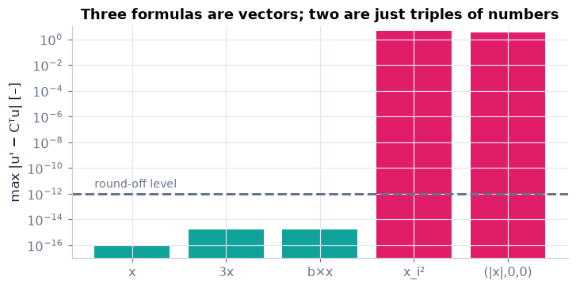

```python
names = list(cands)                                                                     # the five candidates
res = [ch02.transforms_as_vector(fn, R, pts, vector_params=p) for fn, p in cands.values()]   # their (2.8) residuals
fig, ax = plt.subplots(figsize=(6.5, 3.2))                                              # one panel
cols = [COLORS["teal"] if r < 1e-10 else COLORS["rose"] for r in res]                   # teal = passes, rose = fails
ax.bar(names, np.maximum(res, 1e-16), color=cols)                                       # floor at 1e-16 so zero shows on a log axis
ax.set_yscale("log"); ax.set_ylim(1e-17, 10)                                            # residuals span 17 decades
ax.axhline(1e-12, ls="--", color=COLORS["muted"]); ax.text(-0.4, 3e-12, "round-off level", ha="left", color=COLORS["muted"], fontsize=9)   # the noise floor
ax.set_ylabel("max |u' − Cᵀu| [–]"); ax.set_title("Three formulas are vectors; two are just triples of numbers")
plt.show()
```

**What you see.** Three bars at the round-off floor (teal), two bars at order one (rose).

**How to read it.** A vector's formula gives the same arrow whichever axes you compute it in, so its residual is zero; a non-vector's components disagree between observers by numbers of order one — not by a rounding error.

**What would change if…** …you replaced `x**2` by `x**3`: it fails too; `x * (x @ x)` passes (a scalar, $|\mathbf x|^2$, times a vector is a vector).

🔁 *Reminder (Ch. 1 primer P18):* `show_viz("ch02", slug)` embeds a chapter explainer (the local file in Jupyter, the GitHub Pages copy in Colab, a full-window block on the published page).

#### 🎮 Interactive: Which rotates — the arrow or the ruler?

One object, two sets of numbers: only motion shows that the arrow stays put while C, $x'_j$ and (later) $\tau'_{mn}$ move together — and the toggle settles the passive/active confusion once.

**What to try:**

- Drag θ to 90° and read C: the columns are the new axes (0, 1) and (−1, 0).
- Flip 'what rotates' to the arrow: the same C now moves the vector the other way (x' = Cx).
- Polar mode: move the point round its circle and watch u_r, u_θ — Ex. 2.1 live.
- Tensor mode, pure shear: find the angle where τ'₁₂ = 0 (45°) — that is §2.11's principal axis.

```python
show_viz("ch02", "rotation_of_axes")   # full-width explainer; ⤢ Full screen for more room
```

🎮 Interactive 1/5 Which rotates — the arrow or the ruler? Open alone ↗

[interactive chart not shown]

**What would change if…** you applied the rule *twice*, once per index? You would get the transformation of a 3×3 array — and that is precisely the definition of a second-order tensor, $\tau'_{mn} = C_{im}C_{jn}\tau_{ij}$ (2.12), which we reach in §2.4 after meeting the stress tensor and Cauchy's formula.

## 2.3 Multiplication of Matrices

**What is this section about?** The matrix product is the summation convention with one adjacent index — we already used it: $P_{ij} = A_{ik}B_{kj}$ (2.9), $\mathbf P = \mathbf A\cdot\mathbf B$ (2.10) and the written-out product $P_{12} = A_{11}B_{12} + A_{12}B_{22} + A_{13}B_{32}$ (2.11) in C01, and the matrix forms $\mathbf x' = \mathbf C^{\rm T}\mathbf x$, $\mathbf x = \mathbf C\mathbf x'$ in C03. This short section only collects them.

📝 (2.9) $P_{ij} = A_{ik}B_{kj}$ and its boxes (2.11), $P_{12} = A_{11}B_{12} + A_{12}B_{22} + A_{13}B_{32}$, were expanded in **C01** (N21–N23); the rule "a single dot sums one index" is $\mathbf P = \mathbf A\cdot\mathbf B$ (2.10) (N22). (2.6) written with the summed index adjacent, $x'_i = C^{\rm T}_{ik}x_k$, gives the matrix form of **C03** (N16): $\mathbf x' = \mathbf C^{\rm T}\cdot\mathbf x$, and (2.7) is $\mathbf x = \mathbf C\cdot \mathbf x'$.

```python
C = ch02.rotation_matrix_3d([0, 0, 1], np.deg2rad(30)); x = np.array([1., 2., 3.])   # the 30° frame and an arrow
assert np.allclose(ch02.transform_vector(x, C), C.T @ x)        # (2.5) as a matrix product: x' = Cᵀ·x  (N16)
assert np.allclose(ch02.inverse_transform_vector(C.T @ x, C), C @ (C.T @ x))   # (2.7): x = C·x'
assert np.allclose(ch02.inner(C.T, C), np.eye(3))               # CᵀC = I as the (2.9) product `inner`  (D02)
print(ch02.expand_indices_str("C_ki x_k"))                      # the (2.6) form: for each free i, C_1i*x_1 + C_2i*x_2 + C_3i*x_3
```

```
result_1 = C_11*x_1 + C_21*x_2 + C_31*x_3
result_2 = C_12*x_1 + C_22*x_2 + C_32*x_3
result_3 = C_13*x_1 + C_23*x_2 + C_33*x_3
```

**What does the code above do?**

1–2. The two matrix forms of C03, asserted against the index-form functions. 3. $\mathbf C^{\rm T}\mathbf C = \mathbf I$ written as the $P_{ij} = A_{ik}B_{kj}$ (2.9) product `inner`. 4. The adjacent-index form $x'_i = x_kC_{ki}$ (2.6) expanded: the same nine numbers as $x'_j = x_iC_{ij}$ (2.5) with other letters (N13).

## 2.4, 2.6 Second-Order Tensors and the Force on a Surface

**What is this section about?** The stress tensor: nine numbers that tell the force per area on *any* plane through a point. We meet its sign convention (C04), derive Cauchy's formula $\mathbf f = \mathbf n\cdot\boldsymbol\tau$ from a tiny tetrahedron (C05, the book's §2.6), and only then prove the rule that makes τ a tensor, $\tau'_{mn} = C_{im}C_{jn}\tau_{ij}$ (2.12) (C06). The book states (2.12) first and cites a tetrahedron argument it never shows; deriving $f_i = \tau_{ji}n_j$ (2.15) first lets us *prove* (2.12) in eight moves.

### 🧩 The stress tensor τ_ij and its sign convention `C04`

*The question:* Nine stress components sit on a cube. Which index is the face, which is the force — and which way do positive arrows point?

#### The problem in plain words

Ch. 1 split stress into "normal" (push/pull) and "shear" (slide) on one surface (🔁 Ch. 1 primer P05: stress is force per area). But at a point in a fluid there are infinitely many surfaces. Pick three perpendicular ones — the faces of a tiny cube — and write down the force per area on each: three faces × three force directions = nine numbers. That array is the stress tensor. Ch. 4 will balance forces on this cube to get the equation of motion, so every sign here matters.

#### The idea (rule table)

```
τ_ij :  i = the face (its outward normal is ±e_i)      j = the direction of the force per area
face with outward normal +e_i : positive τ_ij points along +e_j   (tensile normal stress is positive)
face with outward normal −e_i : the arrows reverse (traction −τ_i·)   ← Newton III at a point (R01)
i = j : normal stress (τ_11, τ_22, τ_33)      i ≠ j : shear stress (τ_12 = force along 2 on the face ⊥ 1)
```

> 🔁 **Recap — Opposite faces carry equal and opposite stresses** (Ch. 1 §1.7 C20). Ch. 1 §1.7 balanced pressure on the two faces of a box (D05, P09): at a point the two sides of one plane push on each other with equal and opposite force — Newton's third law. So the −e₂ face of the book's Fig. 2.4 carries exactly −(τ₂₁, τ₂₂, τ₂₃). Across a *finite* cube the values differ by a Taylor step, and that difference is Ch. 4's net force.

🔁 *Reminder (P64 above):* 3-D arrows, edges and faces are `go.Cone`, `go.Scatter3d(mode='lines')` and `go.Mesh3d`.

#### The maths, step by step

1. On the face whose outward normal is $+\mathbf e_2$, the force per area is the vector $(\tau_{21}, \tau_{22}, \tau_{23})$ [Pa]: the first index names the face, the second the component.
2. On the opposite face ($-\mathbf e_2$) it is $-(\tau_{21}, \tau_{22}, \tau_{23})$ (R01).
3. Collect the three "+" faces as rows: $\boldsymbol\tau = \begin{bmatrix}\tau_{11}&\tau_{12}&\tau_{13}\\ \tau_{21}&\tau_{22}&\tau_{23}\\ \tau_{31}&\tau_{32} &\tau_{33}\end{bmatrix}$ — **row i = traction on the +e_i face**.
4. Pressure will enter Ch. 4 as $\tau_{ij} = -p\,\delta_{ij} + (\text{viscous})$: a pressure pushes *inward*, so its normal stress is negative.

📝 **Note.** **Array vs tensor** `N26` — The 3×3 array above is what the code carries everywhere (`tau[i, j]`, Python indices 0–2); it is a *tensor* only because it obeys $\tau'_{mn} = C_{im}C_{jn}\tau_{ij}$ (2.12) — C06. **Fig. 2.4** `N25` is our rotatable cube below: nine arrows on the three visible faces, a toggle (`show_hidden=True`) for the hidden faces with their reversed arrows.

#### ✏️ Tiny example: a pressure p with one shear a

τ = [[−p, a, 0], [a, −p, 0], [0, 0, −p]] with p = 3 Pa, a = 1 Pa.

1. Face $+\mathbf e_1$: traction = row 1 = (−3, 1, 0) Pa — pushed *into* the cube by 3 Pa (compression, negative normal stress) and dragged along $+\mathbf e_2$ by 1 Pa.
2. Face $-\mathbf e_1$: (+3, −1, 0) Pa (reversed).
3. Face $+\mathbf e_3$: (0, 0, −3) Pa: pure pressure, no shear.
4. $\tau_{12} = \tau_{21} = 1$ Pa: the shear on the face ⊥ 1 along 2 equals the shear on the face ⊥ 2 along 1 — Ch. 4 shows this symmetry is forced by angular momentum; here we simply chose it.

```python
p, a = 3.0, 1.0                                                   # pressure and shear level [Pa]
tau = np.array([[-p, a, 0.], [a, -p, 0.], [0., 0., -p]])          # the running stress state of C04, C05 (PRESSURE_SHEAR)
faces = ch02.cube_face_tractions(tau)                             # six faces → outward normal and traction by the sign rule (row i, sign of the normal)
for name, f in faces.items():                                     # keys '+1' … '-3' (book axis numbers)
    print(f"face {name}: n = {f['normal']}, traction = {f['traction']} Pa")
total = sum(f["traction"] for f in faces.values())                # add the six tractions
print("sum over the six faces:", total)                           # [0 0 0]: stresses AT A POINT carry no net force (R01)
print(ch02.stress_component_meaning(2, 3))                        # the rule table's sentence, generated for τ_23
```

```
face +1: n = [1. 0. 0.], traction = [-3.  1.  0.] Pa
face -1: n = [-1.  0.  0.], traction = [ 3. -1. -0.] Pa
face +2: n = [0. 1. 0.], traction = [ 1. -3.  0.] Pa
face -2: n = [ 0. -1.  0.], traction = [-1.  3. -0.] Pa
face +3: n = [0. 0. 1.], traction = [ 0.  0. -3.] Pa
face -3: n = [ 0.  0. -1.], traction = [-0. -0.  3.] Pa
sum over the six faces: [0. 0. 0.]
tau_23: force per unit area along +x3 on the face whose outward normal is +x2 (normal along x2, force along x3) — shear stress
```

**What does the code above do?**

1. The running stress state: a pressure of 3 Pa on the diagonal (negative = compression) and one shear pair a = 1 Pa.
2. `cube_face_tractions` applies the sign rule: the +e_i face carries row i, the −e_i face carries −row i.
3. The six tractions cancel — at a point, stresses exert no net force (R01); Ch. 4's net force comes from how τ *changes* across a finite cube.
4. `stress_component_meaning` says in words what τ₂₃ is: the face ⊥ 2, the force along 3 — a shear stress.

```python
mine = {}                                                         # from scratch: the sign rule by hand
for i in range(3):                                                # face index i (Python 0–2 = book 1–3)
    e = np.eye(3)[i]                                              # the unit vector e_i
    mine[f"+{i + 1}"] = (e, tau[i])                               # +e_i face: traction = row i of τ
    mine[f"-{i + 1}"] = (-e, -tau[i])                             # −e_i face: the reversed row (R01)
for k in mine:                                                    # every face
    assert np.allclose(mine[k][1], faces[k]["traction"])          # the library applies exactly this rule
print("row i of τ is the traction on the +e_i face; the −e_i face reverses it")
```

```
row i of τ is the traction on the +e_i face; the −e_i face reverses it
```

```python
from scripts.ch02_fig2_4_stress_cube import stress_cube_figure   # drawing helper (P64): one cone per non-zero component on the + faces
fig = stress_cube_figure(tau, show_hidden=False)                 # normal stresses blue, shears rose; the book's face letters A–H on hover
fig.show()                                                       # rotate the cube
```

[interactive chart not shown]

**What does the code above do?**

1. The helper reads `ch02.cube_face_tractions(tau)` and draws one arrow per non-zero component on each visible + face.
2. Blue arrows are normal stresses (here pointing *into* the cube: compression), rose arrows are shears lying in the face; `show_hidden=True` adds the three − faces with reversed grey arrows.

**What you see.** On each visible face one arrow points straight in (the normal stress −p) and one lies in the face (the shear a) — on the +3 face only the inward arrow.

**How to read it.** The face's index is the first subscript, the arrow's direction the second; a negative normal stress points *into* the cube.

**What would change if…** …you set a = 0: only the three inward pressure arrows remain, equal on every face — an isotropic stress, Ch. 1's pressure (`stress_cube_figure(-3 * np.eye(3))`).

**What would change if…** you cut the point with a *slanted* plane? None of the nine arrows sits on it — yet the force per area there is fixed by them. That is Cauchy's formula, next.

### 🧩 Cauchy's traction formula f = n·τ `C05`

*The question:* Given the nine stresses on the coordinate faces, what is the force per unit area on a plane with an arbitrary unit normal $\mathbf n$?

#### The problem in plain words

The drag on a wing, the friction on a river bed, the pressure on a dam: each is the force per area on a surface whose normal points wherever the surface happens to face. The nine $\tau_{ij}$ were measured on three special planes. Cauchy's formula says the answer on *any* plane is a matrix–vector product, $f_i = \tau_{ji}n_j$, and every wall force of the book is $\oint \mathbf n\cdot\boldsymbol\tau\,dA$.

#### The idea

Slice a corner off the cube: a tiny tetrahedron with three coordinate faces (outward normals $-\mathbf e_1, -\mathbf e_2, -\mathbf e_3$) and one slanted face with normal $\mathbf n$. Balance forces on it (🔁 Ch. 1 primer P09: Newton's second law on a free-body diagram). Face forces scale like (size)², volume forces (weight, inertia) like (size)³ — shrink it and only the faces matter. The slanted face's traction must then balance the three coordinate faces'.

> 📎 **Primer — limits and orders of smallness.** `P68` · When an element of size h shrinks, a quantity ∝ h² (an area) shrinks more slowly than one ∝ h³ (a volume); their ratio h³/h² = h → 0. So in a balance of face terms (∝ h²) and volume terms (∝ h³), the volume terms drop out in the limit — Ch. 1 §1.7 used the same idea once, glossed. Here it is the hinge of the derivation.

```python
for h in [1e-1, 1e-2, 1e-3]:                 # element size [m]
    print(h, h**3 / h**2)                    # the volume/area ratio is h itself → 0
```

```
0.1 0.1
0.01 0.010000000000000002
0.001 0.001
```

> 📎 **Primer — vector area of a closed surface.** `P69` · Give every patch of a closed surface the vector n dA (outward normal times area). Their sum is zero: the surface has no net "direction" (think of a closed box: each face's vector is cancelled by the opposite face's). For the tetrahedron this gives $\mathbf n\,dA = \mathbf e_1 dA_1 + \mathbf e_2 dA_2 + \mathbf e_3 dA_3$, i.e. $dA_i = n_i\,dA$ — the coordinate face i is the shadow of the slanted face.

```python
n = np.array([0.6, 0.0, 0.8]); dA = 2.0                     # a unit normal and the slanted face's area [m²]
print(ch02.tetrahedron_face_areas(n, dA))                   # [1.2 0. 1.6] = n * dA: the three shadows
print(n * dA - ch02.tetrahedron_face_areas(n, dA))          # closed-surface sum n dA − Σ e_i dA_i: zero
```

```
[1.2 0.  1.6]
[0. 0. 0.]
```

📝 **Note.** **A surface element is a vector** `N34` — $d\mathbf A = \mathbf n\,dA$ — size dA, direction the outward normal. Fluxes (C14) and forces (here) are dot products with it.

📝 **Note.** **The tetrahedron balance** `N35` — in the 1-direction: the book's two lines, which are steps 5–7 of the derivation below (`ch02.tetrahedron_face_areas`).

$$ f_1\,dA = \tau_{11}\,dA_1 + \tau_{21}\,dA_2 + \tau_{31}\,dA_3, \qquad dA_i = n_i\,dA \qquad \text{(§2.6)} $$

#### 🧮 Derivation — Cauchy's traction formula from a shrinking tetrahedron (Eq. 2.15)

**What we want to show.** Find the force per unit area on a plane with *any* unit normal n from the nine stresses on the three coordinate planes.

**Assumptions.** Stresses continuous at the point (step 3: the face tractions are the point's τ) · body force and acceleration finite (step 4) · the tetrahedron shrinks to the point (steps 8–9).

**The plan.**

1. List the forces: the slanted face, the three coordinate faces, weight and inertia.
2. Write the coordinate faces' tractions with C04's sign rule.
3. Relate the face areas to n.
4. Shrink: volume terms vanish faster than face terms.

**Tools we use** (each explained before this point): free-body diagram and Newton's second law (Ch. 1 primer P09) · the stress sign convention on the −e_j faces (C04) · vector area of a closed surface, $dA_j = n_j\,dA$ (P69) · orders of smallness h² vs h³ (P68) · limits

**We start from**

$$ \sum\mathbf F = m\,\mathbf a \ \text{ on a tiny tetrahedron} $$

*In words:* Newton's second law for the fluid inside a tetrahedron with three faces on the coordinate planes and one slanted face with outward normal n.

**Step 1 of 9 — Write the force balance on the tetrahedron.**

$$ \mathbf F_{\rm slant} + \mathbf F_1 + \mathbf F_2 + \mathbf F_3 + \mathbf F_{\rm body} = \rho\,dV\,\mathbf a $$

- *Why we can do this:* Newton's second law for the mass ρ dV inside; every force on the boundary and in the volume is listed (free-body diagram, P09).
- *In words:* Four face forces plus the body force equal mass times acceleration.

**Step 2 of 9 — Write the slanted face's force.**

$$ \mathbf F_{\rm slant} = \mathbf f\,dA $$

- *Why we can do this:* By definition $\mathbf f$ is the force per unit area on the plane with normal n, and dA is that face's area. This is the unknown we want.
- *In words:* The slanted face carries the traction we are after.

**Step 3 of 9 — Write the coordinate faces' forces with the sign rule.**

$$ (F_j)_i = -\,\tau_{ji}\,dA_j\quad(j = 1, 2, 3\text{, no sum}) $$

- *Why we can do this:* The face perpendicular to axis j has *outward* normal $-\mathbf e_j$; by C04's rule the traction on a − face is the reversed row j, so its i-component is $-\tau_{ji}$.
- *In words:* Each coordinate face pushes with minus its row of τ.

**Step 4 of 9 — Write body force and inertia together.**

$$ \mathbf F_{\rm body} - \rho\,dV\,\mathbf a = \rho(\mathbf g - \mathbf a)\,dV $$

- *Why we can do this:* Both are proportional to the mass, hence to the volume dV; we group them because they will share the same fate when the element shrinks.
- *In words:* Weight and inertia scale with the volume.

**Step 5 of 9 — Assemble the i-component.**

$$ f_i\,dA - \tau_{1i}dA_1 - \tau_{2i}dA_2 - \tau_{3i}dA_3 + \rho(g_i - a_i)\,dV = 0 $$

- *Why we can do this:* Steps 2–4 substituted into step 1, component i. The book's first line is this one without the volume term (and for i = 1).
- *In words:* Slanted face minus the three coordinate faces plus volume terms is zero.

**Step 6 of 9 — Relate the face areas to the normal.**

$$ dA_j = n_j\,dA $$

- *Why we can do this:* The vector area of a closed surface vanishes: $\mathbf n\,dA - \mathbf e_1dA_1 - \mathbf e_2dA_2 - \mathbf e_3dA_3 = 0$ (P69); reading component j gives this. The coordinate face j is the shadow of the slanted face.
- *In words:* Each coordinate face is the slanted face times a cosine.

**Step 7 of 9 — Substitute the areas and write the sum with an index.**

$$ f_i\,dA - \tau_{ji}\,n_j\,dA + \rho(g_i - a_i)\,dV = 0 $$

- *Why we can do this:* Step 6 into step 5; the three face terms share the pattern $\tau_{ji}n_j dA$ with j summed (summation convention, C01).
- *In words:* The three faces together give τ contracted with n on its first index.

**Step 8 of 9 — Divide by dA and compare sizes.**

$$ f_i - \tau_{ji}n_j + \rho(g_i - a_i)\,\frac{dV}{dA} = 0,\qquad \frac{dV}{dA}\propto h $$

- *Why we can do this:* dA ≠ 0. For a tetrahedron of size h, dA ∝ h² and dV ∝ h³, so dV/dA ∝ h (P68); ρ, g, a stay finite.
- *In words:* The volume term is smaller than the face terms by the element's size.

**Step 9 of 9 — Let the element shrink to the point.**

$$ f_i = \tau_{ji}\,n_j $$

- *Why we can do this:* As h → 0 the last term of step 8 vanishes while the others do not depend on h (stresses continuous at the point). This is (2.15).
- *In words:* The traction on any plane is τ contracted with the normal on its first index.

**Result**

$$ f_i = \tau_{ji}n_j, \qquad \mathbf f = \mathbf n\cdot\boldsymbol\tau $$

*In words:* the nine numbers on the coordinate planes determine the force per area on every plane through the point.

**What it means.** Stress is nine numbers, not a vector, precisely because the force per area depends on the cut; yet those nine suffice for every cut. Every wall force in the book is $\oint\mathbf n\cdot\boldsymbol\tau\,dA$. The formula contracts the *first* index; $\boldsymbol\tau\cdot\mathbf n$ equals it only when τ is symmetric (Ch. 4 proves that for the stress). It fails where stresses are discontinuous (a shock, an interface with surface tension — then the jump conditions of Ch. 4 apply).

**Check it.** Units: Pa on both sides ✓. Limit n = e₃: $f_i = \tau_{3i}$, the traction on the coordinate face — the formula returns its inputs ✓. Number (Ex. 2.2, a = 1 Pa, φ = 30°): $f = (0\cdot0.866 + 1\cdot0.5,\ 1\cdot0.866 + 0\cdot0.5) = (0.5, 0.866)$ Pa ✓ (`traction`, `example_2_2` below). Pure pressure τ = −pδ: f = −p n for every n (Ch. 1's isotropic pressure) ✓.

> ⚠️ **Common confusion (traps in this derivation):** forgetting the minus signs of step 3 (outward normal −e_j). Dropping the volume terms without saying why (they are O(h³) against O(h²)). Writing $\tau_{ij}n_j$ — that needs symmetry.

📝 **Note.** **Contract with the normal** `N37` — (2.15) $\mathbf f = \mathbf n\cdot\boldsymbol\tau$ is to τ what $u_n = \mathbf u\cdot\mathbf n$ is to $\mathbf u$ — contract with the normal — except that $\mathbf f$ is a vector.

> ⚠️ **Common confusion (which index?):** $f_i = \tau_{ji}n_j$ contracts the *first* index (row = face). $\boldsymbol\tau\cdot\mathbf n$ contracts the second and equals $\mathbf n\cdot\boldsymbol\tau$ only when τ is symmetric — true for the stress (Ch. 4), false for a general tensor; the code never assumes it (`traction` uses `einsum('ji,j->i')`).

> 📎 **Primer — np.arctan2.** `P70` · `np.arctan2(y, x)` returns the angle of the point (x, y) in the correct quadrant (−π, π]; `np.arctan(y/x)` cannot tell (−1, −1) from (1, 1). Add 2π (or take `% 360` in degrees) when you want 0–360°.

```python
print(np.rad2deg(np.arctan2(0.866, 0.5)))                   # 60.0: the direction of f for a > 0
print(np.rad2deg(np.arctan2(-0.866, -0.5)) % 360)           # 240.0: the direction of f for a < 0 (opposite quadrant)
```

```
59.999272219172624
239.9992722191726
```

#### ✏️ Tiny example: Ex. 2.2 with a = 1 Pa, φ = 30°

τ = [[0, a], [a, 0]] (pure shear in a channel, $x_1$ along the flow).

1. $\mathbf n = (\cos30°, \sin30°) = (0.866, 0.5)$.
2. $f_1 = \tau_{11}n_1 + \tau_{21}n_2 = 0 + 1\times0.5 = 0.5$ Pa.
3. $f_2 = \tau_{12}n_1 + \tau_{22}n_2 = 1\times0.866 + 0 = 0.866$ Pa.
4. $|\mathbf f| = \sqrt{0.25 + 0.75} = 1 = |a|$.
5. Direction: $\theta = \arctan2(0.866, 0.5) = 60°$; for a = −1 Pa both components flip → 240°.
6. Normal part $\sigma_n = \mathbf f\cdot\mathbf n = 0.5\times0.866 + 0.866\times0.5 = 0.866 = a\sin60°$; shear part $\tau_s = |\mathbf f - \sigma_n\mathbf n| = 0.5 = a\cos60°$ — in general $\sigma_n = a\sin2\phi$, $\tau_s = a\cos2\phi$ (stated; the Mohr-circle preview of C13).

📝 **Note.** **Ex. 2.2, stated** `N38` — the numbers of the tiny example, plus the $\tau'_{mn} = C_{im}C_{jn}\tau_{ij}$ (2.12) route the book also takes: $\tau'_{11} = \sqrt3 a/2 = 0.866a$, $\tau'_{12} = a/2$ — the same two numbers as $\sigma_n$ and $\tau_s$, because the rotated frame's 1'-axis *is* n; repeated inside C06. **Fig. 2.6** `N39` (channel, element at 30°) is the "channel shear" preset of the explainer and the slider figure below.

```python
tau2 = ch02.shear_flow_stress(1.0)                               # Ex. 2.2's 2×2 pure shear [[0, a], [a, 0]], a = 1 Pa
n = np.array([np.cos(np.deg2rad(30)), np.sin(np.deg2rad(30))])   # the unit normal at 30° from the flow direction
f = ch02.traction(tau2, n)                                       # (2.15): f_i = τ_ji n_j  (einsum 'ji,j->i')
print(np.round(f, 4))                                            # [0.5 0.866] Pa
res = ch02.example_2_2(1.0, np.deg2rad(30))                      # Ex. 2.2 packaged: magnitude, direction, normal and shear parts
print(np.round(res["magnitude"], 4), np.round(np.rad2deg(res["angle_rad"]), 1), np.round(res["sigma_n"], 4), np.round(res["tau_s"], 4))   # 1.0 60.0 0.866 0.5
res_neg = ch02.example_2_2(-1.0, np.deg2rad(30))                 # the other half of the channel: a < 0
print(np.round(np.rad2deg(res_neg["angle_rad"]), 1))             # 240.0: f flips through the origin
f3 = ch02.traction(tau, [0.6, 0, 0.8])                           # the same formula on C04's 3-D state with n = (0.6, 0, 0.8)
print(f3)                                                        # [-1.8 0.6 -2.4] Pa = (−3·0.6, 1·0.6, −3·0.8)
```

```
[0.5   0.866]
1.0 60.0 0.866 0.5
240.0
[-1.8  0.6 -2.4]
```

**What does the code above do?**

1. `shear_flow_stress` builds the 2×2 stress of a channel flow at one point.
2. The unit normal at 30°.
3. $f_i = \tau_{ji}n_j$ (2.15) by `einsum('ji,j->i')` — the first index of τ is contracted.
4. `example_2_2` returns the magnitude (= |a|), the direction (60°, P70) and the normal/shear split.
5. a < 0 flips the direction to 240°.
6. The same formula on the 3-D state of C04: each component is a row-wise weighted sum.

```python
f_mine = np.array([sum(tau2[j, i] * n[j] for j in range(2)) for i in range(2)])   # (2.15) by hand: f_i = Σ_j τ_ji n_j
assert np.allclose(f_mine, ch02.traction(tau2, n))                               # the library contracts the first index
tau_ns = np.array([[0., 2.], [0., 0.]])                                          # a NON-symmetric 2×2 (not a stress; a test)
print(ch02.traction(tau_ns, n), tau_ns @ n)                                      # [0 1.732] vs [1 0]: n·τ ≠ τ·n
print("different: the index order is not a formality; only a symmetric τ lets you forget it")
```

```
[0.     1.7321] [1. 0.]
different: the index order is not a formality; only a symmetric τ lets you forget it
```

```python
from scripts.ch02_fig2_5_tetrahedron import tetrahedron_figure   # drawing helper (P64): Fig. 2.5 as a force balance
fig = tetrahedron_figure(tau, n=[0.6, 0, 0.8])                   # coordinate faces with reversed arrows; slanted face with f = (−1.8, 0.6, −2.4) Pa
fig.show()                                                       # rotate
```

[interactive chart not shown]

**What does the code above do?**

1. The three coordinate faces carry the reversed rows of τ (C04's − faces); the slanted face carries $\mathbf f = \mathbf n\cdot\boldsymbol\tau$ as one bold arrow, with n as a thin arrow.
2. The face areas are `ch02.tetrahedron_face_areas(n, dA)` = (0.6, 0, 0.8) dA — D05 step 6.

**What you see.** Three coordinate faces (shadows) and one slanted face; the bold arrow on the slanted face is the balance of the three faces' arrows.

**How to read it.** f is not along n: it has a normal part (blue, along n) and a shear part (rose, in the plane) — here $\sigma_n = \mathbf f\cdot\mathbf n = -3$ Pa (the pressure) and a shear of 0.6 Pa.

**What would change if…** …n = $\mathbf e_3$: f = row 3 = (0, 0, −3) Pa — Cauchy's formula returns the coordinate face (`tetrahedron_figure(tau, n=[0, 0, 1])`).

🔁 *Reminders (Ch. 1 primers P17, P06):* `slider_figure(fn, name, values)` precomputes `fn(value) → {trace: (x, y)}` for every slider position so the plotly figure keeps working on the published page; `np.linspace(a, b, n)` gives n evenly spaced values.

```python
from fluidpy.core.interact import slider_figure                          # precomputed-slider plotly figures (Ch. 1 P17)
sq = np.array([[-1, 1, 1, -1, -1], [-1, -1, 1, 1, -1]]) * 0.5             # the square element's outline (drawing units)
def cut(phi_deg):                                                        # one slider position: the cut with normal at φ
    d = ch02.traction_2d(tau2, np.deg2rad(phi_deg))                      # (2.15) + the split: n, f, σ_n, τ_s for a = +1 Pa
    n_, f_ = d["n"], d["f"]                                              # unit normal and traction [Pa]
    sn = d["sigma_n"] * n_                                               # the normal part σ_n n (blue)
    return {"element": (sq[0], sq[1]),                                   # the square (fixed)
            "cut (plane ⊥ n)": (np.array([-n_[1], n_[1]]) * 0.7, np.array([n_[0], -n_[0]]) * 0.7),   # the cut line through the centre
            "n (unit normal)": ([0, n_[0]], [0, n_[1]]),                 # n
            "f = n·τ  (|f| = a)": ([0, f_[0]], [0, f_[1]]),              # the traction
            "σ_n n = a sin2φ · n": ([0, sn[0]], [0, sn[1]]),             # normal part
            "shear part, |·| = |a cos2φ|": ([sn[0], f_[0]], [sn[1], f_[1]])}   # from the tip of σ_n n to the tip of f
phis = np.linspace(0, 180, 37 if not FAST else 25)                       # 37 slider positions (FAST: 25)
fig = slider_figure(cut, "φ", phis, unit="°", xlabel="x₁ (flow direction)", ylabel="x₂",
                    title="Ex. 2.2: turn the cut — f turns twice as fast as n (a = 1 Pa)",
                    xrange=[-1.3, 1.3], yrange=[-1.3, 1.3], height=520, active=6)   # start at φ = 30°
fig.update_yaxes(scaleanchor="x", scaleratio=1)                          # equal axes so right angles look right
fig.show()                                                               # drag φ
```

[interactive chart not shown]

**What does the code above do?**

1. `traction_2d` evaluates $f_i = \tau_{ji}n_j$ (2.15) for the normal at angle φ and splits f into $\sigma_n\mathbf n$ and the shear part.
2. Each slider position redraws the cut, n, f, the blue normal part and the rose shear part (the leg from the tip of $\sigma_n\mathbf n$ to the tip of f). `N36`: this is our version of the book's traction sketch.

**What you see.** A square element, a cut line through its centre, the normal n and the traction f drawn from the centre with its normal and shear legs.

**How to read it.** f turns twice as fast as n: at 45° f is along n (pure normal stress a, no shear); at 0° and 90° f is perpendicular to n (pure shear). $\sigma_n = a\sin2\phi$, $\tau_s = a\cos2\phi$.

**What would change if…** …a < 0 (the other half of the channel): every f arrow is mirrored through the origin — `ch02.traction_2d(ch02.shear_flow_stress(-1.0), φ)`.

#### 🎮 Interactive: Cut the point any way you like: what pushes on the cut?

The traction is a function of the cut direction; only dragging n and watching f, $\sigma_n$, $\tau_s$ and the Mohr point move together makes $\mathbf f = \mathbf n\cdot\boldsymbol\tau$ (2.15) a picture — and lets you *find* the shear-free planes before §2.11 proves they are eigenvectors.

**What to try:**

- Channel-shear preset: drag φ to 45° — the shear vanishes and σ_n = a.
- Hydrostatic preset: f stays along n whatever φ; every plane is principal.
- Toggle 'contract second index' on the non-symmetric demo: f changes — the index order matters.
- Read the Explain tab at φ = 30°: f₁ = 0·0.866 + 1·0.5 = 0.5 Pa, term by term.

```python
show_viz("ch02", "cauchy_traction_principal_axes")   # full-width explainer; ⤢ Full screen for more room
```

🎮 Interactive 2/5 Cut the point any way you like: what pushes on the cut? Open alone ↗

[interactive chart not shown]

**What would change if…** a second observer used rotated axes? Both $\mathbf f$ and $\mathbf n$ are vectors, $u'_j = u_iC_{ij}$ (2.8), and $\mathbf f = \mathbf n\cdot\boldsymbol\tau$ (2.15) must hold for both observers — that forces the nine $\tau_{ij}$ to transform in one particular way. That way is the definition of a tensor: C06.

### 🧩 The transformation rule of a second-order tensor: τ' = Cᵀ τ C `C06`

*The question:* How do the nine stress components change when the axes turn — and why does *that* rule, not the array itself, define a tensor?

#### The problem in plain words

The same stress state must give the same force on the same plane whichever axes you compute in. Two observers, two 3×3 arrays. The only way they can agree about every plane is if the arrays are related by one C per index: $\tau'_{mn} = C_{im}C_{jn}\tau_{ij}$. Ch. 3 will need it for the strain rate, Ch. 4 for the stress, Ch. 12 for the Reynolds stress — it is the working definition of "tensor".

#### The idea

(2.8) once per index. A vector: $u'_n = u_iC_{in}$. A tensor has two slots, each behaves like a vector: $\tau'_{mn} = C_{im}\,C_{jn}\,\tau_{ij}$. Matrix form: $\boldsymbol\tau' = \mathbf C^{\rm T}\boldsymbol\tau\,\mathbf C$ — Cᵀ on the left for the first index, C on the right for the second.

The book states this rule, $\tau'_{mn} = C_{im}C_{jn}\tau_{ij}$ (2.12), and points to a tetrahedron argument (Sommerfeld); we have the tetrahedron result $f_i = \tau_{ji}n_j$ (2.15) in hand, so we derive (2.12) from it.

#### 🧮 Derivation — The tensor transformation rule from Cauchy's formula (Eq. 2.12)

**What we want to show.** Show how the nine stress components must change under a rotation of axes, given only that force per area and the normal are vectors. The book states $\tau'_{mn} = C_{im}C_{jn}\tau_{ij}$ (2.12) and cites Sommerfeld's tetrahedron; we have the tetrahedron result $f_i = \tau_{ji}n_j$ (2.15) already, so we derive (2.12) from it.

**Assumptions.** τ is *defined* in each frame by $f_i = \tau_{ji}n_j$ (2.15) (start and step 5) · C orthogonal (enters through $x_j = x'_iC_{ji}$ (2.7) in step 3).

**The plan.**

1. Transform f as a vector.
2. Insert Cauchy's formula in the old frame.
3. Express the old n through the new n'.
4. Compare with Cauchy's formula in the new frame, for every n'.

**Tools we use** (each explained before this point): f and n are vectors, $u'_j = u_iC_{ij}$ (2.8) (C03) · Cauchy's formula $f_i = \tau_{ji}n_j$ (2.15) (C05) · the inverse transformation $x_j = x'_iC_{ji}$ (2.7) (D03) · dummy renaming (N12) · "true for every n' ⇒ the coefficients agree" (gloss in step 7)

**We start from**

$$ f_i = \tau_{ji}n_j \ \text{(old frame)}, \qquad f'_n = \tau'_{mn}n'_m \ \text{(new frame)} $$

*In words:* Cauchy's formula holds for every observer, each with their own components of τ.

**Step 1 of 8 — Transform the traction as a vector.**

$$ f'_n = f_i\,C_{in} $$

- *Why we can do this:* f is a physical force per area, hence a vector, so its components obey $u'_j = u_iC_{ij}$ (2.8) with the first index of C summed. We start from f because both frames must agree on it.
- *In words:* The new observer's traction components come from the old ones by C.

**Step 2 of 8 — Insert Cauchy's formula in the old frame.**

$$ f'_n = \tau_{ji}\,n_j\,C_{in} $$

- *Why we can do this:* (2.15), $f_i = \tau_{ji}n_j$, gives $f_i$ in terms of the old τ and the old n; substituting expresses the new traction through old quantities.
- *In words:* The new traction, written with the old stresses and the old normal.

**Step 3 of 8 — Write the old normal through the new one.**

$$ n_j = n'_m\,C_{jm} $$

- *Why we can do this:* n is a unit vector, so the inverse rule $x_j = x'_iC_{ji}$ (2.7) applies (second index of C summed). We need n' because the new observer measures n'.
- *In words:* The old components of the normal from the new ones.

**Step 4 of 8 — Substitute the normal.**

$$ f'_n = C_{jm}\,C_{in}\,\tau_{ji}\,n'_m $$

- *Why we can do this:* Step 3 into step 2; the factors are reordered (scalars commute) so that both C's sit in front. Everything on the right is now old τ, two C's and the new normal.
- *In words:* The new traction equals two C's times the old τ times the new normal.

**Step 5 of 8 — Write Cauchy's formula in the new frame.**

$$ f'_n = \tau'_{mn}\,n'_m $$

- *Why we can do this:* The new observer sees the same physics, so (2.15) holds with primed components everywhere — this *defines* the new observer's τ'.
- *In words:* The new observer's own stress tensor gives the same traction.

**Step 6 of 8 — Equate steps 4 and 5.**

$$ \big(\tau'_{mn} - C_{jm}C_{in}\tau_{ji}\big)\,n'_m = 0 $$

- *Why we can do this:* Both are the same $f'_n$; subtracting and factoring the common $n'_m$ (a sum on m) collects the difference. The bracket does not depend on n'.
- *In words:* A certain matrix, applied to any unit normal, gives zero.

**Step 7 of 8 — Conclude the bracket vanishes.**

$$ \tau'_{mn} = C_{jm}\,C_{in}\,\tau_{ji} $$

- *Why we can do this:* Step 6 holds for every unit n'; choose n' = e'_1, e'_2, e'_3 in turn and each picks out one column of the bracket, which must be zero (compare coefficients).
- *In words:* The new stress components are fixed by the old ones and C.

**Step 8 of 8 — Rename the dummies (j → i, i → j).**

$$ \tau'_{mn} = C_{im}\,C_{jn}\,\tau_{ij}\qquad(\boldsymbol\tau' = \mathbf C^{\rm T}\boldsymbol\tau\,\mathbf C) $$

- *Why we can do this:* Swapping the names of two summed letters changes nothing (N12); this is the book's (2.12). In matrix form $C_{im} = (\mathbf C^{\rm T})_{mi}$, so Cᵀ stands on the left and C on the right.
- *In words:* One C per index — the vector rule applied twice.

**Result**

$$ \tau'_{mn} = C_{im}C_{jn}\tau_{ij}, \qquad \boldsymbol\tau' = \mathbf C^{\rm T}\boldsymbol\tau\,\mathbf C $$

*In words:* a second-order tensor transforms with one direction-cosine matrix per index; whatever obeys this is a tensor.

**What it means.** The rule contains nothing about stress: any nine numbers that obey it are the components of a physical object, and any that do not are not (N27). Ch. 3's strain rate, Ch. 4's stress and Ch. 12's Reynolds stress all pass. The book's order — the rule $\tau'_{mn} = C_{im}C_{jn}\tau_{ij}$ (2.12) stated first, Cauchy's $f_i = \tau_{ji}n_j$ (2.15) derived later — is reversed here on purpose.

**Check it.** Units: Pa ✓. Limit C = I: τ' = τ ✓. Number (Ex. 2.2, a = 1, θ = 30°): $\tau'_{11} = 2(0.866)(0.5) = 0.866$, $\tau'_{12} = 0.75 - 0.25 = 0.5$, $\tau'_{22} = -0.866$ ✓ (`transform_tensor` = `C.T @ tau @ C` below). Trace 0 before and after (D18).

> ⚠️ **Common confusion (traps in this derivation):** writing $\mathbf C\boldsymbol\tau\mathbf C^{\rm T}$ — that is the *active* convention; ours is passive. Forgetting the final rename and comparing $C_{jm}C_{in}\tau_{ji}$ with the book. Assuming symmetry of τ anywhere — not needed.

📝 **Note.** **Tensor ≠ matrix** `N27` — Any 3×3 array is a matrix; its entries are the components of a tensor only if they obey $\tau'_{mn} = C_{im}C_{jn}\tau_{ij}$ (2.12) in every frame. The code below declares an array "the same in every frame" and measures the (2.12) residual: not small.

📝 **Note.** **Fourth order** `N28` — one C per index, four of them, $3^4 = 81$ components — `ch02.transform_tensor(A4, C)` handles any order; the viscosity tensor of Ch. 4 §4.5 is the one we will meet.

$$ A'_{mnpq} = C_{im} C_{jn} C_{kp} C_{lq} A_{ijkl} \qquad \text{(2.13)} $$

📝 **Note.** **Examples that pass** `N29` — the stress $\tau_{ij}$, the velocity gradient $\partial u_i/\partial x_j$ (N52), and the outer product $u_iv_j$ of two vectors (Exercise 2.10) — asserted below with `ch02.outer`.

#### ✏️ Tiny example: Ex. 2.2's rotated stress, a = 1 Pa, θ = 30°

1. $C = \begin{bmatrix}0.866 & -0.5\\ 0.5 & 0.866\end{bmatrix}$.
2. $\tau'_{11} = C_{i1}C_{j1}\tau_{ij} = C_{11}C_{21}\tau_{12} + C_{21}C_{11}\tau_{21} = 2\times0.866\times0.5\times1 = 0.866$ Pa.
3. $\tau'_{12} = C_{11}C_{22}\tau_{12} + C_{21}C_{12}\tau_{21} = 0.866^2 - 0.5^2 = 0.75 - 0.25 = 0.5$ Pa.
4. $\tau'_{22} = 2C_{12}C_{22}\tau_{12} = -2\times0.5\times0.866 = -0.866$ Pa.
5. So $\tau' = \begin{bmatrix}0.866 & 0.5\\ 0.5 & -0.866\end{bmatrix}$: the 1'-axis is n, so $\tau'_{11} = \sigma_n$ and $\tau'_{12} = \tau_s$ of C05 ✓; the trace is still 0 (C07).

```python
C2 = ch02.rotation_matrix_2d(np.deg2rad(30))                        # the passive 2-D C
tp = ch02.transform_tensor(tau2, C2)                                # (2.12): τ'_mn = C_im C_jn τ_ij  (einsum 'im,jn,ij->mn')
print(np.round(tp, 4))                                              # [[0.866 0.5], [0.5 −0.866]] Pa
print(np.round(C2.T @ tau2 @ C2, 4))                                # the matrix form CᵀτC — identical
print(np.round(ch02.example_2_2(1.0, np.deg2rad(30))["tau_rot"], 4))   # Ex. 2.2's own route — identical again (N38)
R = ch02.random_rotation(np.random.default_rng(2))                  # a random 3-D rotation
print(ch02.transforms_as_tensor(lambda x, bb: ch02.outer(x, np.cross(bb, x)), R, pts, vector_params=(b,)))   # outer product of two vector fields x and b × x (b rotated too): ≈ 1e-15 → a tensor (N29)
print(ch02.transforms_as_tensor(lambda x: np.diag([1., 2., 3.]), R, pts))   # a fixed array declared "the same in every frame": order 1 → NOT a tensor (N27)
A4 = np.random.default_rng(3).normal(size=(3, 3, 3, 3))            # 81 random numbers
print(ch02.transform_tensor(A4, R).shape)                           # (3, 3, 3, 3): (2.13), four C's  (N28)
```

```
[[ 0.866  0.5  ]
 [ 0.5   -0.866]]
[[ 0.866  0.5  ]
 [ 0.5   -0.866]]
[[ 0.866  0.5  ]
 [ 0.5   -0.866]]
2.220446049250313e-15
1.3195302361237258
(3, 3, 3, 3)
```

**What does the code above do?**

1. $\tau'_{mn} = C_{im}C_{jn}\tau_{ij}$ (2.12) as `transform_tensor` — an einsum with one C per index.
2. The matrix form $\mathbf C^{\rm T}\boldsymbol\tau\mathbf C$ — identical numbers.
3. Ex. 2.2's route gives the same τ'.
4. The outer product $x_i(\mathbf b\times\mathbf x)_j$ of two vector fields passes the tensor test (residual at round-off); as in C03, the fixed vector b is handed over as a `vector_params` entry so that the test rotates it too.
5. A fixed array "the same in every frame" fails by order one — a matrix, not a tensor.
6. $A'_{mnpq} = C_{im}C_{jn}C_{kp}C_{lq}A_{ijkl}$ (2.13): four C's, 81 numbers.

```python
tp_mine = np.zeros((2, 2))                                          # (2.12) by hand
for m in range(2):                                                  # free m
    for n_ in range(2):                                             # free n
        for i in range(2):                                          # dummy i
            for j in range(2):                                      # dummy j
                tp_mine[m, n_] += C2[i, m] * C2[j, n_] * tau2[i, j]   # one term of C_im C_jn τ_ij
assert np.allclose(tp_mine, ch02.transform_tensor(tau2, C2))        # the library's einsum is this quadruple loop
assert np.allclose(tp_mine, C2.T @ tau2 @ C2)                       # and so is the matrix form
print(np.round(tp_mine, 4), "= the tiny example")
```

```
[[ 0.866  0.5  ]
 [ 0.5   -0.866]] = the tiny example
```

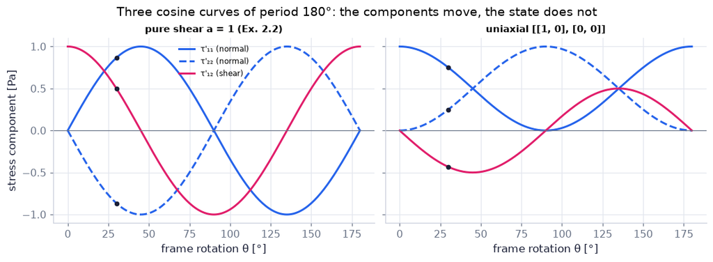

```python
thetas = np.deg2rad(np.linspace(0, 180, 181))                       # frame angles 0…180°
presets = {"pure shear a = 1 (Ex. 2.2)": tau2, "uniaxial [[1, 0], [0, 0]]": np.array([[1., 0.], [0., 0.]])}   # two stress states
fig, axs = plt.subplots(1, 2, figsize=(10, 3.6), sharey=True)       # one panel per preset
for ax, (name, T) in zip(axs, presets.items()):                     # for each preset …
    tps = np.array([ch02.transform_tensor(T, ch02.rotation_matrix_2d(t)) for t in thetas])   # … τ'(θ) by (2.12) at every angle
    ax.plot(np.rad2deg(thetas), tps[:, 0, 0], color=COLORS["blue"], label="τ'₁₁ (normal)")     # normal stress on the 1' face
    ax.plot(np.rad2deg(thetas), tps[:, 1, 1], color=COLORS["blue"], ls="--", label="τ'₂₂ (normal)")
    ax.plot(np.rad2deg(thetas), tps[:, 0, 1], color=COLORS["rose"], label="τ'₁₂ (shear)")      # shear stress in the new frame
    k30 = 30; ax.plot([30] * 3, tps[k30, [0, 1, 0], [0, 1, 1]], "o", color=COLORS["ink"], ms=4)   # the θ = 30° values of the tiny example
    ax.axhline(0, color=COLORS["muted"], lw=0.8); ax.set_xlabel("frame rotation θ [°]"); ax.set_title(name, fontsize=10)
axs[0].set_ylabel("stress component [Pa]"); axs[0].legend(fontsize=8)
fig.suptitle("Three cosine curves of period 180°: the components move, the state does not")
plt.show()
```

**What you see.** Three cosine curves of period 180° in each panel; the dots at θ = 30° are the tiny example's 0.866, 0.5 and −0.866 Pa.

**How to read it.** τ'₁₂ crosses zero at 45° for pure shear (and at 0° for the uniaxial state) — a principal axis (C13); the shear curve's amplitude is the largest shear any plane can carry.

**What would change if…** …you added a pressure (−p on the diagonal): both normal curves shift down by p, the shear curve does not move.

```python
def mohr(theta_deg):                                                 # one slider position: the frame turned by θ
    C_ = ch02.rotation_matrix_2d(np.deg2rad(theta_deg))              # passive C
    T = ch02.transform_tensor(tau2, C_)                              # τ' = CᵀτC (2.12) for pure shear a = 1 Pa
    c, r = ch02.mohr_circle_2d(tau2)                                 # Mohr's circle: centre (τ₁₁ + τ₂₂)/2 = 0 (half the trace — an invariant, C07), radius √(((τ₁₁ − τ₂₂)/2)² + τ₁₂²) = 1 Pa
    ang = np.linspace(0, 2 * np.pi, 181)                             # to draw the circle
    return {"Mohr circle (all planes)": (c + r * np.cos(ang), r * np.sin(ang)),          # fixed circle
            "(τ'₁₁, τ'₁₂): the 1' face": ([c, T[0, 0]], [0, T[0, 1]]),                    # radius to the current point
            "(τ'₂₂, −τ'₁₂): the 2' face": ([c, T[1, 1]], [0, -T[0, 1]])}                   # its antipode: the perpendicular face
fig = slider_figure(mohr, "θ", np.linspace(0, 180, 37 if not FAST else 25), unit="°", xlabel="normal stress σ_n [Pa]",
                    ylabel="shear stress τ_s [Pa]", title="Mohr's circle: as the frame turns by θ, the point runs round at 2θ",
                    xrange=[-1.3, 1.3], yrange=[-1.3, 1.3], height=480, active=6)   # start at 30°
fig.update_yaxes(scaleanchor="x", scaleratio=1)                      # a circle should look like a circle
fig.show()                                                           # drag θ
```

[interactive chart not shown]

**What does the code above do?**

1. For each θ the stress is rotated with $\tau'_{mn} = C_{im}C_{jn}\tau_{ij}$ (2.12) and the pair $(\tau'_{11}, \tau'_{12})$ — the normal and shear stress on the 1' face — is plotted as a point.
2. **Mohr's circle** (Ch. 4 uses it for stresses; here it is a fact about any symmetric 2×2): the set of all $(\sigma_n, \tau_s)$ pairs over all planes through the point is a circle of centre $(\tau_{11} + \tau_{22})/2$ — half the trace, an invariant (C07); here 0 — and radius $\sqrt{((\tau_{11} - \tau_{22})/2)^2 + \tau_{12}^2}$ (here 1 Pa); `mohr_circle_2d` returns both. The second radius marks the perpendicular face $(\tau'_{22}, -\tau'_{12})$ — always the antipode.

**What you see.** A circle of radius 1 Pa centred at the origin; two radii from the centre to opposite points, turning as you drag θ.

**How to read it.** One turn of the frame (180°) is one full turn of the point (360°): the double angle of the cosine curves above. The circle's radius is the largest shear any plane can carry; where the radius hits the σ axis (θ = 45°) the shear is zero — a principal axis (C13).

**What would change if…** …you added a pressure −p: the circle slides left by p; its radius (the shear) is unchanged.

**What would change if…** you contracted the two indices of τ' with each other? $\tau'_{mm} = C_{im}C_{jm}\tau_{ij} = \delta_{ij}\tau_{ij} = \tau_{ii}$: the trace is the same in every frame. That is the next section — contraction makes invariants.

## 2.5 Contraction and Multiplication

**What is this section about?** Setting two indices equal and summing (contraction) lowers the order by two; multiplying raises it. Contracted quantities with no free index are the same in every frame — the invariants of a tensor — and the einsum patterns here are used in every later notebook.

### 🧩 Contraction: the trace, the three invariants and the double dot `C07`

*The question:* Which combinations of the nine numbers $\tau_{ij}$ are the same for every observer — and why exactly those?

#### The problem in plain words

The pressure in a flowing fluid is defined in Ch. 4 as $-\tau_{ii}/3$; the rate of volume expansion in Ch. 3 is $S_{ii}$; turbulence models in Ch. 12 are built from invariants of the Reynolds stress. Each is a number that must not depend on how you set up your axes. Contraction is the recipe that produces such numbers.

#### The idea

```
A_ij  →  set j = i and sum  →  A_ii = A_11 + A_22 + A_33        (a chain of indices closing on itself)
under a rotation each index brings one C; a closed pair  C_im C_jm  is  δ_ij  (D02)  →  the C's vanish
A_ij A_ji = a closed chain of two  →  invariant, and it is the one that enters I₂
A_ij A_ij = tr(A Aᵀ) is also invariant*  — but it is NOT the λ-coefficient of the characteristic polynomial
```

(*both scalars survive a rotation — $\mathbf C^{\rm T}\mathbf A\mathbf C$ leaves $\mathrm{tr}(\mathbf A\mathbf A^{\rm T})$ unchanged too. The distinction is that $I_2 = \tfrac12(I_1^2 - A_{ij}A_{ji})$ needs the closed chain $A_{ij}A_{ji}$; the two coincide when A is symmetric.)

> 📎 **Primer — Vieta's formulas.** `P71` · For a cubic with roots $\lambda^1, \lambda^2, \lambda^3$: $(\lambda - \lambda^1)(\lambda - \lambda^2)(\lambda - \lambda^3) = \lambda^3 - (\sum\lambda^k)\lambda^2 + (\sum_{k<l}\lambda^k\lambda^l)\lambda - \lambda^1\lambda^2\lambda^3$ — the coefficients are the sum, the pair-sums and the product of the roots. (🔁 Ch. 1 primer P40: sympy `expand`.)

```python
l, a_, b_, c_ = sp.symbols('lambda a b c')                    # the variable and three roots
print(sp.expand((l - a_) * (l - b_) * (l - c_)))              # lambda**3 − (a+b+c) lambda**2 + (ab+ac+bc) lambda − abc
```

```
-a*b*c + a*b*lambda + a*c*lambda - a*lambda**2 + b*c*lambda - b*lambda**2 - c*lambda**2 + lambda**3
```

#### The maths, step by step

1. **Contraction:** $\sum_j A_{jj} \equiv A_{jj} = A_{11} + A_{22} + A_{33}$, the trace.
2. **Invariance:** apply $A'_{mn} = C_{im}C_{jn}A_{ij}$ (2.12) and set n = m — D18 below shows every closed index chain survives the rotation unchanged.
3. **The three invariants:** $I_1 = A_{ii}$, $I_2 = \tfrac12(I_1^2 - A_{ij}A_{ji})$, $I_3 = \det\mathbf A$; they are the coefficients of $\det(\mathbf A - \lambda\boldsymbol\delta) = 0$ (Exercise 2.9), so the eigenvalues of C13 are invariants too. *Gloss (C13 makes this precise):* an eigenvalue λ and eigenvector b satisfy $\mathbf A\cdot\mathbf b = \lambda\mathbf b$ — a direction that A only stretches; for symmetric A three perpendicular such directions exist and, taken as axes (the *principal frame*), make A diagonal. The roots of the cubic are exactly these λ.
4. **Products** raise the order (N30); contractions of products such as $A_{ij}B_{ki} = (\mathbf B\cdot\mathbf A)_{kj}$ (2.14) are matrix products in disguise (N31).

#### 🧮 Derivation — Why the trace, I₂ and the determinant do not depend on the axes (Exercise 2.9)

**What we want to show.** Show that three combinations of the nine components of a tensor are the same for every observer, that they are the coefficients of the characteristic polynomial, and what they become in the principal frame. The book gives hints in Exercise 2.9.

**Assumptions.** A any second-order tensor (steps 1–7); for step 8 A symmetric (so that a principal frame exists).

**The plan.**

1. Contract $A'_{mn} = C_{im}C_{jn}A_{ij}$ (2.12) on m = n: a C-pair collapses to δ.
2. Do the same for the chain A_ij A_ji.
3. Take determinants.
4. Expand det(A − λδ) and identify the coefficients; evaluate them in the principal frame.

**Tools we use** (each explained before this point): the transformation rule $A'_{mn} = C_{im}C_{jn}A_{ij}$ (2.12) (C06) · orthogonality as "a contracted C-pair is δ", $C_{im}C_{jm} = \delta_{ij}$ (D02) · Kronecker substitution (N41) · det(AB) = det A det B (Ch. 1 primer P53) · Vieta's formulas (P71) · the principal frame (D17 fact 3, forward pointer; step 8 only needs "τ' = diag(λ)")

**We start from**

$$ A'_{mn} = C_{im}\,C_{jn}\,A_{ij} $$

*In words:* how any second-order tensor's components change under a rotation (2.12, D06).

**Step 1 of 8 — Contract (2.12) on its free indices.**

$$ A'_{mm} = C_{im}\,C_{jm}\,A_{ij} $$

- *Why we can do this:* Set n = m and sum (contraction, C07). The two C's now share their summed second index m. We contract because a fully contracted quantity has no free index — a candidate scalar.
- *In words:* The trace in the new frame, written with the old components.

**Step 2 of 8 — Collapse the C-pair.**

$$ A'_{mm} = \delta_{ij}\,A_{ij} = A_{ii} $$

- *Why we can do this:* $C_{im}C_{jm} = \delta_{ij}$ (D02, second indices summed), then δ substitutes. The trace is the same in both frames: $I_1 = A_{ii}$ is invariant.
- *In words:* Every observer measures the same trace.

**Step 3 of 8 — Transform the two-link chain.**

$$ A'_{mn}A'_{nm} = C_{im}C_{jn}A_{ij}\;C_{kn}C_{lm}A_{kl} $$

- *Why we can do this:* Apply $A'_{mn} = C_{im}C_{jn}A_{ij}$ (2.12) to each factor with fresh dummy letters (i, j) and (k, l) — reusing a letter would wrongly sum it. We choose $A_{ij}A_{ji}$ because its indices close into a loop.
- *In words:* The chain in the new frame, with four C's.

**Step 4 of 8 — Pair the C's and collapse.**

$$ A'_{mn}A'_{nm} = (C_{im}C_{lm})(C_{jn}C_{kn})\,A_{ij}A_{kl} = \delta_{il}\delta_{jk}A_{ij}A_{kl} = A_{ij}A_{ji} $$

- *Why we can do this:* Scalars commute, so group the C's sharing m and those sharing n; each pair is a δ (D02); the δ's substitute l → i and k → j. Hence $I_2 = \tfrac12(I_1^2 - A_{ij}A_{ji})$ is invariant.
- *In words:* Any closed chain of indices survives a rotation unchanged.

**Step 5 of 8 — Take the determinant of the matrix form.**

$$ \det\mathbf A' = \det(\mathbf C^{\rm T}\mathbf A\,\mathbf C) = (\det\mathbf C)^2\det\mathbf A = \det\mathbf A $$

- *Why we can do this:* det of a product is the product of dets (scale factors of volume multiply — D02 step 7); det Cᵀ = det C and (det C)² = 1 (D02 step 7). So $I_3 = \det\mathbf A$ is invariant.
- *In words:* The determinant is the third frame-independent number.

**Step 6 of 8 — Expand the characteristic determinant in λ.**

$$ \det(\mathbf A - \lambda\boldsymbol\delta) = -\lambda^3 + A_{ii}\,\lambda^2 - M\,\lambda + \det\mathbf A $$

- *Why we can do this:* Expanding a 3×3 determinant whose diagonal entries are $A_{ii} - \lambda$ (cofactors, P53): the λ³ and λ² coefficients come from the diagonal product, the constant term is det A, and M is the sum of the three principal 2×2 minors.
- *In words:* A cubic whose coefficients are built from A alone.

**Step 7 of 8 — Identify M with I₂.**

$$ M = (A_{11}A_{22} - A_{12}A_{21}) + (A_{22}A_{33} - A_{23}A_{32}) + (A_{11}A_{33} - A_{13}A_{31}) = \tfrac12(A_{ii}A_{jj} - A_{ij}A_{ji}) $$

- *Why we can do this:* Expand $A_{ii}A_{jj} = (A_{11} + A_{22} + A_{33})^2$ and subtract $A_{ij}A_{ji}$ (diagonal squares and the pairs $A_{12}A_{21}$ …): the diagonal squares cancel, each cross product appears twice, hence the ½. So the cubic is $\lambda^3 - I_1\lambda^2 + I_2\lambda - I_3 = 0$ (sign flipped).
- *In words:* The middle coefficient is exactly the second invariant.

**Step 8 of 8 — Evaluate in the principal frame.**

$$ I_1 = \lambda^1 + \lambda^2 + \lambda^3,\quad I_2 = \lambda^1\lambda^2 + \lambda^2\lambda^3 + \lambda^3\lambda^1,\quad I_3 = \lambda^1\lambda^2\lambda^3 $$

- *Why we can do this:* For symmetric A the principal frame — the axes along the three perpendicular eigenvectors b, the directions with A·b = λb that A only stretches (gloss above; proved as D17 fact 3) — has A' = diag(λ¹, λ², λ³); the invariants may be computed in any frame, so use this one: trace, sum of 2×2 minors, determinant of a diagonal matrix — Vieta's formulas (P71) for the cubic's roots.
- *In words:* The invariants are the sum, the pair-sums and the product of the eigenvalues — so the eigenvalues are frame-independent too.

**Result**

$$ I_1 = A_{ii},\quad I_2 = \tfrac12(I_1^2 - A_{ij}A_{ji}),\quad I_3 = \det\mathbf A \ \text{ unchanged by (2.12)};\qquad \det(\mathbf A - \lambda\boldsymbol\delta) = -(\lambda^3 - I_1\lambda^2 + I_2\lambda - I_3) $$

*In words:* three numbers, and hence the eigenvalues, belong to the tensor, not to the observer; in the principal frame they are the symmetric functions of the λ's.

**What it means.** The pressure $-\tau_{ii}/3$ (Ch. 4), the volume strain rate $S_{ii} = \nabla\cdot\mathbf u$ (Ch. 3), and the turbulence invariants of Ch. 12 are physical because they are contractions. $A_{ij}A_{ij} = \mathrm{tr}(\mathbf A \mathbf A^{\rm T})$ is also frame-independent, but it is not the coefficient of λ in the cubic — $I_2$ needs the closed chain $A_{ij}A_{ji}$ (equal to it only for symmetric A).

**Check it.** Units: A, A², A³ respectively ✓. Limit A = δ: I = (3, 3, 1), polynomial $(1 - \lambda)^3$ ✓. Number: A = [[2, 1, 0], [1, 3, 1], [0, 1, 4]]: $I_1 = 9$, $A_{ij}A_{ji} = 29 + 4 = 33$, $I_2 = ½(81 − 33) = 24$, $I_3 = 18$; roots 1.268, 3.000, 4.732 sum to 9.000 and multiply to 18.00 ✓ (`invariants`, `characteristic_polynomial` below, `principal_axes` in C13).

> ⚠️ **Common confusion (traps in this derivation):** reusing a dummy letter in step 3. Using $A_{ij}A_{ij}$ for $I_2$. The sign pattern of the cubic. Reading $\lambda^k$ as a power.

📝 **Note.** **Multiplication raises the order** `N30` — $P_{ijkl} = A_{ij}B_{kl}$ has four free indices (`ch02.tensor_product(A, B)` = `np.multiply.outer`); it transforms by $A'_{mnpq} = C_{im}C_{jn}C_{kp}C_{lq}A_{ijkl}$ (2.13).

📝 **Note.** **The four contractions of (2.14) are matrix products** `N31` —

| index string | matrix form |
| --- | --- |
| `A_ij B_ki` | $(\mathbf B\cdot\mathbf A)_{kj}$ |
| `A_ij B_ik` | $(\mathbf A^{\rm T}\cdot\mathbf B)_{jk}$ |
| `A_ij B_kj` | $(\mathbf A\cdot\mathbf B^{\rm T})_{ik}$ |
| `A_ij B_jk` | $(\mathbf A\cdot\mathbf B)_{ik}$ |

Rearrange until the summed index is adjacent, then it is a matrix product; each row is asserted below with `ch02.contract(A, B, pattern)`.

$$ A_{ij}B_{ki} = (\mathbf B\cdot\mathbf A)_{kj}, \quad A_{ij}B_{ik} = (\mathbf A^{\rm T}\cdot\mathbf B)_{jk}, \quad A_{ij}B_{kj} = (\mathbf A\cdot\mathbf B^{\rm T})_{ik}, \quad A_{ij}B_{jk} = (\mathbf A\cdot\mathbf B)_{ik} \qquad \text{(2.14)} $$

📝 **Note.** **Tensor · vector, two ways** `N32` — $A_{ij}u_j = (\mathbf A\cdot\mathbf u)_i$ vs $A_{ij}u_i = (\mathbf A^{\rm T}\cdot\mathbf u)_j$ — `ch02.dot_tensor_vector(A, u, index=1 or 0)`; exactly the distinction of C05 ($\mathbf n\cdot\boldsymbol\tau$ vs $\boldsymbol\tau\cdot\mathbf n$).

📝 **Note.** **⚠️ Double dot, two conventions** `N33` — the book's $\mathbf A:\mathbf B = A_{ij}B_{ji}$ (transpose pairing) vs the common Frobenius $A_{ij}B_{ij}$ (Wikipedia, most continuum texts). For A = [[1, 2], [3, 4]], B = [[0, 1], [1, 0]]: book 2·1 + 3·1 = 5, Frobenius 2·1 + 3·1 = 5 too — a symmetric B hides the difference; take B = [[0, 1], [0, 0]]: book $A_{12}B_{21} + A_{21}B_{12} = 3$, Frobenius $A_{12}B_{12} = 2$. They agree whenever one operand is symmetric (Ch. 4's dissipation $\tau_{ij}\,\partial u_i/\partial x_j$). `ch02.double_dot(A, B, convention=…)` — always say which.

#### ✏️ Tiny example: invariants of A = [[2, 1, 0], [1, 3, 1], [0, 1, 4]]

1. $I_1 = 2 + 3 + 4 = 9$.
2. $A_{ij}A_{ji}$ = sum of squares (A symmetric) = $4 + 9 + 16 + 2(1 + 0 + 1) = 33$, so $I_2 = \tfrac12(81 - 33) = 24$.
3. $I_3 = 2(3\cdot4 - 1\cdot1) - 1(1\cdot4 - 0) + 0 = 22 - 4 = 18$.
4. Characteristic polynomial $\lambda^3 - 9\lambda^2 + 24\lambda - 18 = 0$; its roots multiply to 18 and add to 9 (Vieta) — C13 finds them numerically: 1.27, 3.00, 4.73 (sum 9.00 ✓).

```python
A = np.array([[2., 1., 0.], [1., 3., 1.], [0., 1., 4.]])            # the running symmetric example (EXAMPLE_TENSOR; reused in C13)
print(ch02.trace(A), ch02.invariants(A))                            # 9.0 (9.0, 24.0, 18.0): I₁, I₂, I₃
print(ch02.characteristic_polynomial(A))                            # [1 −9 24 −18]: λ³ − I₁λ² + I₂λ − I₃  (D18)
R = ch02.random_rotation(np.random.default_rng(4))                  # a random rotation
Ap = ch02.transform_tensor(A, R)                                    # the same tensor seen by another observer (2.12)
print(np.round(Ap, 3))                                              # nine different numbers …
print(np.round(ch02.invariants(Ap), 10))                            # … the same three invariants (9, 24, 18)
print(ch02.double_dot(A, Ap, convention="book"), ch02.double_dot(A, Ap, convention="frobenius"))   # equal: both operands symmetric (N33)
B = np.array([[0., 1.], [0., 0.]]); A2 = np.array([[1., 2.], [3., 4.]])   # N33's counter-example
print(ch02.double_dot(A2, B, "book"), ch02.double_dot(A2, B, "frobenius"))   # 3.0 2.0: the conventions differ for non-symmetric operands
```

```
9.0 (9.0, 24.0, 17.999999999999996)
[  1.  -9.  24. -18.]
[[ 1.624  0.27  -0.845]
 [ 0.27   4.092 -0.793]
 [-0.845 -0.793  3.284]]
[ 9. 24. 18.]
27.61405867261695 27.614058672616945
3.0 2.0
```

**What does the code above do?**

1–2. `invariants` and `characteristic_polynomial` compute $I_1, I_2, I_3$ and the cubic's coefficients (D18 steps 6–7). 3. Rotating the tensor changes every entry but leaves the three invariants untouched (D18 steps 2, 4, 5). 4–5. The two double-dot conventions agree for symmetric operands and differ otherwise (N33).

```python
I1 = sum(A[i, i] for i in range(3))                                                   # I₁ = A_ii
I2 = 0.5 * (I1**2 - sum(A[i, j] * A[j, i] for i in range(3) for j in range(3)))       # I₂ = ½(I₁² − A_ij A_ji): the closed chain
I3 = (A[0, 0] * (A[1, 1] * A[2, 2] - A[1, 2] * A[2, 1])                               # I₃ = det A by cofactors along row 1 (Ch. 1 P53)
      - A[0, 1] * (A[1, 0] * A[2, 2] - A[1, 2] * A[2, 0])
      + A[0, 2] * (A[1, 0] * A[2, 1] - A[1, 1] * A[2, 0]))
assert np.allclose((I1, I2, I3), ch02.invariants(A))                                  # (9, 24, 18)
B3 = np.random.default_rng(7).normal(size=(3, 3))                                     # a random second operand for (2.14)
for pat, mat in [("ij,ki->kj", B3 @ A), ("ij,ik->jk", A.T @ B3), ("ij,kj->ik", A @ B3.T), ("ij,jk->ik", A @ B3)]:   # N31's four rows
    assert np.allclose(ch02.contract(A, B3, pat), mat)                                # each index string IS the stated matrix product
u = np.array([1., 0., 0.])                                                            # a test vector
assert np.allclose(ch02.dot_tensor_vector(A, u, index=1), A @ u) and np.allclose(ch02.dot_tensor_vector(A, u, index=0), A.T @ u)   # N32
print("invariants by hand = library; the four (2.14) patterns are the four matrix products")
```

```
invariants by hand = library; the four (2.14) patterns are the four matrix products
```

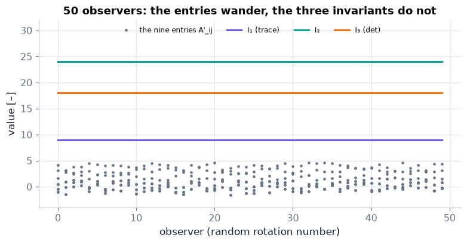

```python
rng = np.random.default_rng(5)                                       # seeded
n_rot = 50                                                           # observers
ents, invs = [], []                                                  # the nine entries and the three invariants per observer
for k in range(n_rot):                                               # one random rotation per observer
    Ak = ch02.transform_tensor(A, ch02.random_rotation(rng))         # (2.12)
    ents.append(Ak.ravel()); invs.append(ch02.invariants(Ak))        # collect
ents, invs = np.array(ents), np.array(invs)                          # shapes (50, 9), (50, 3)
fig, ax = plt.subplots(figsize=(7, 3.6))                             # one panel
ax.plot(np.repeat(np.arange(n_rot), 9), ents.ravel(), ".", color=COLORS["muted"], ms=4, label="the nine entries A'_ij")   # grey dots
for c, (lab, col) in enumerate([("I₁ (trace)", COLORS["accent"]), ("I₂", COLORS["teal"]), ("I₃ (det)", COLORS["orange"])]):
    ax.plot(invs[:, c], color=col, lw=2, label=lab)                  # three flat lines
ax.set_ylim(-4, 32); ax.legend(fontsize=8, ncol=4, loc="upper center")   # room above I₂ = 24 for the legend
ax.set_xlabel("observer (random rotation number)"); ax.set_ylabel("value [–]")
ax.set_title("50 observers: the entries wander, the three invariants do not")
plt.show()
```

**What you see.** Grey dots wander over roughly [−2, 5]; three lines stay perfectly flat at 9, 24 and 18.

**How to read it.** Each dot is one observer's opinion about one component; the lines are facts about the tensor itself (D18).

**What would change if…** …you used a non-symmetric A and also plotted $A_{ij}A_{ij}$: it too stays flat (it is $\mathrm{tr}(\mathbf A\mathbf A^{\rm T})$, invariant), but it is no longer equal to $A_{ij}A_{ji}$ — the one that belongs in $I_2$.

**What would change if…** you contracted a *third-order* object? $\varepsilon_{ijk}$ contracted with two vectors is the cross product — the alternating tensor of the next section.

## 2.7, 2.8 Kronecker Delta and Alternating Tensor; Vector, Dot, and Cross Products

**What is this section about?** Two constant tensors that look the same to every observer: δ (met in C01) and the alternating tensor ε_ijk. ε turns the cross product, the curl and the rotation tensor into index sums, and one identity — the epsilon–delta relation — closes every vector identity you will ever need.

### 🧩 The alternating tensor ε_ijk `C08`

*The question:* How can 27 numbers, all 0 or ±1, encode "right-handed perpendicular" — and give the cross product, the curl and the Coriolis term as index sums?

#### The problem in plain words

The Coriolis acceleration $2\boldsymbol\Omega\times\mathbf u$, the vorticity $\nabla\times\mathbf u$, the torque $\mathbf r\times\mathbf F$ — fluid mechanics is full of cross products, and the component formula $\mathbf u\times\mathbf v = (u_2v_3 - u_3v_2)\mathbf e_1 + (u_3v_1 - u_1v_3)\mathbf e_2 + (u_1v_2 - u_2v_1)\mathbf e_3$ (2.20) is a mess to manipulate. $\varepsilon_{ijk}$ is the bookkeeping device that turns "cross" into "sum", and $\varepsilon_{ijk}\varepsilon_{klm} = \delta_{il}\delta_{jm} - \delta_{im}\delta_{jl}$ (2.19) is the one identity that turns products of two ε's back into δ's.

#### The idea

```
ε_ijk = +1  for ijk = 123, 231, 312   (cyclic: walk round 1→2→3→1)
      = −1  for ijk = 321, 213, 132   (anticyclic: walk backwards)
      =  0  whenever two indices agree                 → 6 nonzero entries out of 27
swap two indices → sign flips;  move one index two places (a cyclic shift) → sign kept
```

> 📎 **Primer — permutations, cyclic order and parity.** `P72` · A permutation of (1, 2, 3) is a reordering. It is *even* if it takes an even number of pairwise swaps to reach from 123 (123, 231, 312 — the cyclic shifts) and *odd* otherwise (132, 213, 321). $\varepsilon_{ijk}$ is +1 on even, −1 on odd permutations, 0 if not a permutation. `itertools.permutations` lists them (sibling of Ch. 1's `combinations`, P55).

```python
from itertools import permutations                         # standard library: every ordering of a tuple
for p in permutations((1, 2, 3)):                          # the six orderings of (1, 2, 3)
    print(p, ch02.permutation_sign(*p))                    # (1,2,3) 1, (1,3,2) −1, (2,1,3) −1, (2,3,1) 1, (3,1,2) 1, (3,2,1) −1
```

```
(1, 2, 3) 1
(1, 3, 2) -1
(2, 1, 3) -1
(2, 3, 1) 1
(3, 1, 2) 1
(3, 2, 1) -1
```

> 📎 **Primer — numpy arrays with three axes and np.transpose.** `P73` · `eps[i, j, k]` indexes a 3×3×3 array (shape (3, 3, 3)). `np.transpose(a, axes)` puts old axis `axes[p]` in position p, so `np.transpose(eps, (1, 2, 0))[i, j, k] = eps[k, i, j]` — the code form of "move an index" (here: the old last index k has moved to the front, a two-place move). ε is unchanged by both cyclic shifts, so the demo below also uses a plain 0…26 array, where a wrong reading of the rule *would* fail.

```python
eps = ch02.levi_civita()                                                   # ε_ijk as a (3, 3, 3) array, Python 0-based
print(eps.shape, eps[0, 1, 2], eps[0, 2, 1], eps[0, 0, 1])                 # (3,3,3) 1 −1 0 = ε_123, ε_132, ε_112
a3 = np.arange(27).reshape(3, 3, 3)                                        # a non-symmetric 3×3×3 array: a3[i, j, k] = 9i + 3j + k
print(np.transpose(a3, (1, 2, 0))[0, 1, 2], a3[2, 0, 1], a3[1, 2, 0])      # 19 19 15: new[0,1,2] = a3[2,0,1] (old axis 2 moved to the front) — NOT a3[1,2,0]
print(np.array_equal(np.transpose(eps, (1, 2, 0)), eps))                   # True: the two-place move ε_kij = ε_ijk keeps ε  (np.array_equal: exact equality)
```

```
(3, 3, 3) 1.0 -1.0 0.0
19 19 15
True
```

> 📎 **Primer — right-hand rule and orientation.** `P74` · Point the fingers of your right hand along the first vector, curl them toward the second: the thumb gives the direction of the cross product. $\mathbf e_1\times\mathbf e_2 = \mathbf e_3$ fixes a right-handed frame; the same rule orients the boundary of a surface in §2.13 (thumb along n, fingers along t).

```python
print(np.cross([1, 0, 0], [0, 1, 0]))    # [0 0 1] = e_3: right-handed
```

```
[0 0 1]
```

#### The maths, step by step

1. **Definition (2.18):** $\varepsilon_{ijk} = +1$ (cyclic), $-1$ (anticyclic), $0$ (an index repeated) — as in the idea box.
2. **Index moves** (N43): swapping two indices flips the sign, $\varepsilon_{ijk} = -\varepsilon_{ikj}$; moving one index two places keeps it, $\varepsilon_{ijk} = \varepsilon_{jki} = \varepsilon_{kij}$.
3. **Cross product (2.21):** $(\mathbf u\times\mathbf v)_k = \varepsilon_{ijk}u_iv_j$ — nine terms, two survive for each k; k = 1: $\varepsilon_{231}u_2v_3 + \varepsilon_{321}u_3v_2 = u_2v_3 - u_3v_2$ ✓ (2.20).
4. **Epsilon–delta (2.19):** $\varepsilon_{ijk}\varepsilon_{klm} = \delta_{il}\delta_{jm} - \delta_{im}\delta_{jl}$; contracted once $\varepsilon_{pqi}\varepsilon_{pqj} = 2\delta_{ij}$, twice $\varepsilon_{pqr}\varepsilon_{pqr} = 6$ — D09.
5. **Isotropy** (N42): δ and ε (up to a factor) are the only constant tensors of order 2 and 3 unchanged by every proper rotation.

📝 **Note.** **Cross product, the geometric definition** `N46` — $\mathbf w = \mathbf u\times\mathbf v$ has length $uv\sin\theta$, is perpendicular to both, and $(\mathbf u, \mathbf v, \mathbf w)$ is right-handed (P74); $\mathbf u\times\mathbf v = -\mathbf v\times\mathbf u$; $\mathbf e_1\times\mathbf e_2 = \mathbf e_3$.

📝 **Note.** **Cross product in components (stated)** `N47` — because $\mathbf e_i\times\mathbf e_j = \varepsilon_{ijk}\mathbf e_k$ and the product distributes; `ch02.cross(u, v)` is asserted equal to `np.cross` below. **Determinant form** `N48`: $\mathbf u\times\mathbf v = \det[\mathbf e_1\ \mathbf e_2\ \mathbf e_3;\ u_1\ u_2\ u_3;\ v_1\ v_2\ v_3]$ — one sympy line (`sp.Matrix(u).cross(sp.Matrix(v))`) reproduces (2.20).

$$ \mathbf u\times\mathbf v = (u_2v_3 - u_3v_2)\mathbf e_1 + (u_3v_1 - u_1v_3)\mathbf e_2 + (u_1v_2 - u_2v_1)\mathbf e_3 \qquad \text{(2.20)} $$

📝 **Note.** **Cross product in index form** `N49` — `ch02.cross_einsum` is `np.einsum('ijk,i,j->k')`; `ch02.expand_indices_str("eps_ijk u_i v_j")` prints $\mathbf u\times\mathbf v = (u_2v_3 - u_3v_2)\mathbf e_1 + (u_3v_1 - u_1v_3)\mathbf e_2 + (u_1v_2 - u_2v_1)\mathbf e_3$ (2.20). **k = 1 check** `N50`: only (i, j) = (2, 3) and (3, 2) survive — visible in the printed expansion.

$$ (\mathbf u\times\mathbf v)_k = \sum_{i=1}^{3}\sum_{j=1}^{3}\varepsilon_{ijk}u_iv_j \equiv \varepsilon_{ijk}u_iv_j = \varepsilon_{kij}u_iv_j \qquad \text{(2.21)} $$

📝 **Note.** **Index moves on ε** `N43` — with `np.transpose` assertions below: axis orders `(1, 2, 0)` and `(2, 0, 1)` return ε (two-place moves); `(0, 2, 1)` returns −ε (one swap).

📝 **Note.** **Isotropic tensors** `N42` — $\delta'_{ij} = C_{im}C_{jn}\delta_{mn} = C_{im}C_{jm} = \delta_{ij}$ (D02) in every frame; ε is isotropic under proper rotations (det C = +1) and flips sign under a reflection — a *pseudo*tensor, which is why the book says "rotation". `ch02.is_isotropic(delta)` True, `is_isotropic(eps, proper=True)` True, `is_isotropic(eps, proper=False)` False, a random tensor False. Pointer: the isotropic Newtonian stress model of Ch. 4 §4.5 is built from δ alone.

📝 **Note.** **The epsilon–delta relation** `N44` — the book says "verify by choosing values"; D09 below proves it, and `ch02.epsilon_delta_residual()` checks all 81 cases; the vector triple product $\mathbf a\times(\mathbf b\times\mathbf c) = (\mathbf a\cdot\mathbf c)\mathbf b - (\mathbf a\cdot\mathbf b)\mathbf c$ is its first payoff.

$$ \sum_{k=1}^{3}\varepsilon_{ijk}\varepsilon_{klm} \equiv \varepsilon_{ijk}\varepsilon_{klm} = \delta_{il}\delta_{jm} - \delta_{im}\delta_{jl} \qquad \text{(2.19)} $$

#### 🧮 Derivation — The epsilon–delta relation, its contractions and the triple product (Eq. 2.19)

**What we want to show.** Prove the identity that turns a product of two alternating tensors into Kronecker deltas — the tool that closes every vector identity (curl of a curl, a × (b × c), the vorticity algebra of Ch. 5). The book says "verify by choosing some values".

**Assumptions.** Three dimensions (the count "exactly one k outside {i, j}" is 3-D; step 4).

**The plan.**

1. Both sides vanish when i = j or l = m.
2. For i ≠ j only one k survives, and both ε's are nonzero only if {l, m} = {i, j}.
3. Evaluate the two surviving cases: +1 and −1.
4. Contract the result once, twice; apply it to a × (b × c).

**Tools we use** (each explained before this point): definition of ε, $\varepsilon_{ijk} = +1$ (cyclic), $-1$ (anticyclic), $0$ (an index repeated) (2.18), and its index moves (N43) · antisymmetry: swapping two indices flips the sign · Kronecker substitution and δ_ii = 3 (N41) · the index form of the cross product $(\mathbf u\times\mathbf v)_k = \varepsilon_{ijk}u_iv_j$ (2.21) (N49) · permutation parity (P72)

**We start from**

$$ L_{ijlm} \equiv \varepsilon_{ijk}\,\varepsilon_{klm}\quad(\text{sum on } k) $$

*In words:* the left side of (2.19) as a four-index object we will evaluate case by case.

**Step 1 of 11 — Fix the free indices and expand the sum.**

$$ L_{ijlm} = \varepsilon_{ij1}\varepsilon_{1lm} + \varepsilon_{ij2}\varepsilon_{2lm} + \varepsilon_{ij3}\varepsilon_{3lm} $$

- *Why we can do this:* The summation convention on the repeated k (C01). We write the three terms out so that "which k survives" can be argued.
- *In words:* Three products, one per value of the summed index.

**Step 2 of 11 — Dispose of i = j.**

$$ i = j:\quad L_{iilm} = 0 = \delta_{il}\delta_{im} - \delta_{im}\delta_{il} $$

- *Why we can do this:* ε with two equal indices is zero, $\varepsilon_{iik} = 0$ (2.18), so every term of step 1 vanishes; the right side of $\varepsilon_{ijk}\varepsilon_{klm} = \delta_{il}\delta_{jm} - \delta_{im}\delta_{jl}$ (2.19) is a difference of two equal products. Both sides are antisymmetric in (i, j).
- *In words:* Equal first indices: zero on both sides.

**Step 3 of 11 — Dispose of l = m the same way.**

$$ l = m:\quad L_{ijll} = 0 = \delta_{il}\delta_{jl} - \delta_{il}\delta_{jl} $$

- *Why we can do this:* $\varepsilon_{kll} = 0$ kills the left side; the right side is again a difference of identical products. From now on i ≠ j and l ≠ m.
- *In words:* Equal last indices: zero on both sides.

**Step 4 of 11 — Identify the only surviving k.**

$$ i \neq j:\quad \varepsilon_{ijk} \neq 0 \iff k = k^*,\ \{i, j, k^*\} = \{1, 2, 3\} $$

- *Why we can do this:* In 3-D, with i and j distinct, exactly one value of k differs from both; for it ε is ±1, for the other two ε is 0 by (2.18), $\varepsilon_{ijk} = 0$ when an index repeats. The sum in step 1 has one term.
- *In words:* Only the third index completing the set contributes.

**Step 5 of 11 — Require the second ε to be nonzero too.**

$$ \varepsilon_{k^*lm} \neq 0 \iff \{l, m\} = \{i, j\} $$

- *Why we can do this:* l and m must be distinct from $k^*$ and from each other, and the only two values left are i and j. If {l, m} ≠ {i, j}, L = 0 — and then the right side is 0 as well, since l or m equals $k^*$ and every δ there has a zero factor.
- *In words:* Both ε's are alive only when the last pair is the first pair, in some order.

**Step 6 of 11 — Evaluate the case l = i, m = j.**

$$ L_{ijij} = \varepsilon_{ijk^*}\,\varepsilon_{k^*ij} = \varepsilon_{ijk^*}^2 = 1 $$

- *Why we can do this:* Moving $k^*$ two places ($\varepsilon_{k^*ij} = \varepsilon_{ijk^*}$, N43) makes the two factors equal; a nonzero ε squared is 1. Right side: $\delta_{ii}\delta_{jj} - \delta_{ij}\delta_{ji} = 1\cdot1 - 0 = 1$ (here $\delta_{ii}$ with i fixed is 1, not 3).
- *In words:* Same pair, same order: plus one on both sides.

**Step 7 of 11 — Evaluate the case l = j, m = i.**

$$ L_{ijji} = \varepsilon_{ijk^*}\,\varepsilon_{k^*ji} = -\varepsilon_{ijk^*}^2 = -1 $$

- *Why we can do this:* $\varepsilon_{k^*ji} = -\varepsilon_{k^*ij}$ (one swap flips the sign), then as in step 6. Right side: $\delta_{ij}\delta_{ji} - \delta_{ii}\delta_{jj} = 0 - 1 = -1$. All 81 cases are now covered: (2.19) holds.
- *In words:* Same pair, swapped order: minus one on both sides.

**Step 8 of 11 — Contract (2.19) on j = m.**

$$ \varepsilon_{ijk}\,\varepsilon_{klj} = \delta_{il}\delta_{jj} - \delta_{ij}\delta_{jl} = 3\delta_{il} - \delta_{il} = 2\delta_{il} $$

- *Why we can do this:* Set m = j and sum: now $\delta_{jj} = 3$ (a summed pair, N41) and $\delta_{ij}\delta_{jl} = \delta_{il}$ by substitution. Two-place moves rewrite this as the book's $\varepsilon_{pqi}\varepsilon_{pqj} = 2\delta_{ij}$.
- *In words:* One contraction leaves twice a delta.

**Step 9 of 11 — Contract again on i = l.**

$$ \varepsilon_{pqr}\,\varepsilon_{pqr} = 2\delta_{rr} = 6 $$

- *Why we can do this:* Set the remaining free pair equal and sum; $\delta_{rr} = 3$. This counts the nonzero entries of ε: six of them, each squared to 1.
- *In words:* Fully contracted, ε with itself gives 6.

**Step 10 of 11 — Write a × (b × c) with two ε's.**

$$ [\mathbf a\times(\mathbf b\times\mathbf c)]_m = \varepsilon_{mpq}\,a_p\,\varepsilon_{qij}\,b_i c_j $$

- *Why we can do this:* (2.21) twice: $(\mathbf b\times\mathbf c)_q = \varepsilon_{ijq}b_ic_j = \varepsilon_{qij}b_ic_j$ and $(\mathbf a\times\mathbf d)_m = \varepsilon_{pqm}a_pd_q = \varepsilon_{mpq}a_pd_q$ (two-place moves). The shared summed index q is adjacent in both ε's.
- *In words:* A double cross product is two ε's contracted on one index.

**Step 11 of 11 — Apply (2.19) and let the deltas substitute.**

$$ [\mathbf a\times(\mathbf b\times\mathbf c)]_m = (\mathbf a\cdot\mathbf c)\,b_m - (\mathbf a\cdot\mathbf b)\,c_m $$

- *Why we can do this:* $\varepsilon_{mpq}\varepsilon_{qij} = \delta_{mi}\delta_{pj} - \delta_{mj}\delta_{pi}$ by (2.19) with (i, j, k, l, m) → (m, p, q, i, j); then $\delta_{mi}b_i = b_m$, $\delta_{pj}a_pc_j = \mathbf a\cdot\mathbf c$, etc.
- *In words:* The "BAC − CAB" rule falls out in one line.

**Result**

$$ \varepsilon_{ijk}\varepsilon_{klm} = \delta_{il}\delta_{jm} - \delta_{im}\delta_{jl};\quad \varepsilon_{pqi}\varepsilon_{pqj} = 2\delta_{ij};\quad \varepsilon_{pqr}\varepsilon_{pqr} = 6;\quad \mathbf a\times(\mathbf b\times\mathbf c) = (\mathbf a\cdot\mathbf c)\mathbf b - (\mathbf a\cdot\mathbf b)\mathbf c $$

*In words:* a product of two ε's sharing an index is a difference of two δ-pairs, "first with first, second with second, minus the crossed pair".

**What it means.** Every identity of vector calculus that contains two crosses — ∇ × (∇ × u) = ∇(∇·u) − ∇²u, the Lagrange identity |u × v|² = u²v² − (u·v)², the curl of b × x in Ex. 2.3, the ω ↔ R map of D15 — is this one line plus index bookkeeping. It is a 3-D statement (in 2-D the alternating symbol has two indices and $\varepsilon_{ij}\varepsilon_{kl} = \delta_{ik}\delta_{jl} - \delta_{il}\delta_{jk}$).

**Check it.** Dimensionless ✓. `epsilon_delta_residual()` = 0 over all 81 cases; `einsum('pqi,pqj')` = 2I, `einsum('pqr,pqr')` = 6 ✓ (below). Number: a = (1, 0, 0), b = (0, 1, 0), c = (1, 0, 0): b × c = (0, 0, −1), a × (b × c) = (0, 1, 0); right side (a·c)b − (a·b)c = 1·b − 0 = (0, 1, 0) ✓ (`triple_product`).

> ⚠️ **Common confusion (traps in this derivation):** $\delta_{ii} = 3$ when summed, 1 when the index is fixed (steps 6 vs 8). The sign when moving the summed k next to its partner. Treating the 81-case table as the proof — it is the check; the proof is the antisymmetry argument.

#### ✏️ Tiny example: one case of (2.19) and one cross product

1. Take i = 1, j = 2, l = 1, m = 2: left side $\sum_k\varepsilon_{12k}\varepsilon_{k12} = \varepsilon_{123}\varepsilon_{312} = 1\times1 = 1$ (k = 3 is the only term); right side $\delta_{11}\delta_{22} - \delta_{12}\delta_{21} = 1 - 0 = 1$ ✓.
2. Swap l and m (l = 2, m = 1): left $\varepsilon_{123}\varepsilon_{321} = -1$, right $\delta_{12}\delta_{21} - \delta_{11}\delta_{22} = -1$ ✓.
3. Cross product (1, 2, 3) × (4, 5, 6): k = 1: $2\cdot6 - 3\cdot5 = -3$; k = 2: $3\cdot4 - 1\cdot6 = 6$; k = 3: $1\cdot5 - 2\cdot4 = -3$ → (−3, 6, −3); check ⊥: $(1, 2, 3)\cdot(-3, 6, -3) = -3 + 12 - 9 = 0$ ✓.

```python
eps = ch02.levi_civita()                                              # ε_ijk (2.18) as a (3, 3, 3) array
print(eps[0, 1, 2], eps[2, 1, 0], np.count_nonzero(eps))              # 1 −1 6: ε_123, ε_321, and six nonzero entries out of 27
print(ch02.epsilon_delta_residual())                                  # 0.0: all 81 cases of (2.19) hold exactly
print(np.einsum('pqi,pqj->ij', eps, eps)); print(np.einsum('pqr,pqr', eps, eps))   # 2δ_ij (D09 step 8) and 6 (step 9)
u, v = np.array([1., 2., 3.]), np.array([4., 5., 6.])                 # the tiny example's vectors
print(ch02.cross(u, v), ch02.cross_einsum(u, v), np.cross(u, v))      # [−3 6 −3] three times: (2.20), (2.21), numpy
print(ch02.expand_indices_str("eps_ijk u_i v_j"))                     # (2.21) expanded: the three lines of (2.20) — two terms survive per k (N50)
a_, b_, c_ = np.random.default_rng(8).normal(size=(3, 3))             # three random vectors
print(np.allclose(ch02.triple_product(a_, b_, c_), (a_ @ c_) * b_ - (a_ @ b_) * c_))   # True: a × (b × c) = (a·c)b − (a·b)c (D09 step 11)
rng = np.random.default_rng(9)                                        # for the isotropy tests
print(ch02.is_isotropic(np.eye(3), rng)[0], ch02.is_isotropic(eps, rng, proper=True)[0],
      ch02.is_isotropic(eps, rng, proper=False)[0], ch02.is_isotropic(A, rng)[0])   # True True False False (N42)
```

```
1.0 -1.0 6
0.0
[[2. 0. 0.]
 [0. 2. 0.]
 [0. 0. 2.]]
6.0
[-3.  6. -3.] [-3.  6. -3.] [-3.  6. -3.]
result_1 = u_2*v_3 - u_3*v_2
result_2 = -u_1*v_3 + u_3*v_1
result_3 = u_1*v_2 - u_2*v_1
True
True True False False
```

**What does the code above do?**

1. Six nonzero entries; Python's `eps[0, 1, 2]` is the book's $\varepsilon_{123}$.
2. All 81 cases of $\varepsilon_{ijk}\varepsilon_{klm} = \delta_{il}\delta_{jm} - \delta_{im}\delta_{jl}$ (2.19) hold exactly (D09's check).
3. The two contractions: $2\delta_{ij}$ and 6.
4. Three cross products agree — the component formula, the einsum and numpy's.
5. The expansion shows the k = 1 check of the worked example.
6. The triple-product identity for random vectors.
7. Isotropy: δ always, ε only under proper rotations (a pseudotensor), a generic tensor never.

```python
from itertools import permutations, product                           # permutations (P72); product = nested loops in one line
eps_mine = np.zeros((3, 3, 3))                                        # from scratch: fill the 6 nonzero entries
for p in permutations(range(3)):                                      # the six orderings of (0, 1, 2)
    eps_mine[p] = ch02.permutation_sign(*[q + 1 for q in p])          # +1 even, −1 odd (book indices 1–3)
assert np.array_equal(eps_mine, eps)                                  # identical to levi_civita()
for i, j, l, m in product(range(3), repeat=4):                        # all 81 (i, j, l, m) cases of (2.19)
    lhs = sum(eps[i, j, k] * eps[k, l, m] for k in range(3))          # the sum over k
    rhs = (i == l) * (j == m) - (i == m) * (j == l)                   # δ_il δ_jm − δ_im δ_jl
    assert lhs == rhs                                                 # exact integers
print("ε from parity = levi_civita(); (2.19) holds in all 81 cases")
```

```
ε from parity = levi_civita(); (2.19) holds in all 81 cases
```

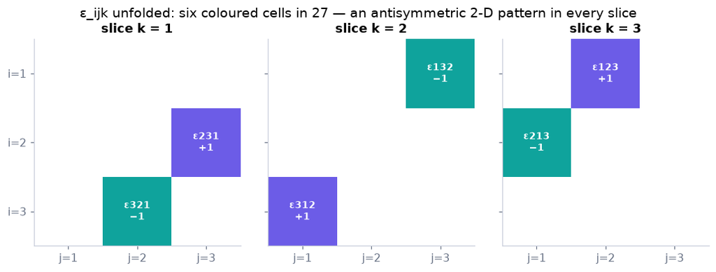

```python
from matplotlib.colors import ListedColormap                          # a colormap from a list of colours
fig, axs = plt.subplots(1, 3, figsize=(9.5, 3.4), sharey=True)         # one slice per k
labels = {1: "+1", -1: "−1"}                                          # cell labels
for k, ax in enumerate(axs):                                          # slice k (Python) = ε_ij(k+1)
    sl = eps[:, :, k]                                                 # the 3×3 slice
    ax.imshow(sl, cmap=ListedColormap([COLORS["teal"], "white", COLORS["accent"]]), vmin=-1, vmax=1)   # imshow draws a 2-D array as coloured cells (a heatmap): −1 teal, 0 white, +1 purple
    ax.grid(False)                                                    # no grid lines through the cells
    for i in range(3):                                                # label the nonzero cells with their index triple
        for j in range(3):
            if sl[i, j] != 0:
                ax.text(j, i, f"ε{i + 1}{j + 1}{k + 1}\n{labels[int(sl[i, j])]}", ha="center", va="center", fontsize=9, color="white", fontweight="bold")   # two-line label: index triple, then the value
    ax.set_xticks(range(3), ["j=1", "j=2", "j=3"]); ax.set_yticks(range(3), ["i=1", "i=2", "i=3"]); ax.set_title(f"slice k = {k + 1}")
fig.suptitle("ε_ijk unfolded: six coloured cells in 27 — an antisymmetric 2-D pattern in every slice")
plt.show()
```

**What you see.** Three 3×3 slices, six coloured cells in all: purple +1, teal −1, white 0; the coloured pair shifts by one place from slice to slice.

**How to read it.** Each slice k holds the 2-D antisymmetric pattern of the remaining two indices — the matrix $\mathbf R = \left(\begin{smallmatrix}0&-\omega_3&\omega_2\\\omega_3&0&-\omega_1\\-\omega_2&\omega_1&0\end{smallmatrix}\right)$ (2.26) of C12 in disguise: $-\varepsilon_{ijk}\omega_k$ fills exactly these cells.

**What would change if…** …you relabelled 1 ↔ 2 everywhere (a mirror): every colour flips — ε changes sign under a reflection (N42).

**What would change if…** the second vector were the operator $\partial/\partial x_j$? $\varepsilon_{ijk}\,\partial u_k/\partial x_j$ — the curl (C11). And $-\varepsilon_{ijk}\omega_k$ packs a vector into an antisymmetric matrix (C12). ε is the bridge between vectors and antisymmetric tensors.

## 2.9 Gradient, Divergence, and Curl

**What is this section about?** The del operator acting three ways: on a scalar it gives the direction of steepest climb (gradient), on a vector either how much the field spreads (divergence) or how much it spins (curl). We compute all three on a grid you will meet again in every chapter, and check the stencils converge at second order.

> 🔁 **Recap — The del operator ∇** (Ch. 1 §1.5 primers P21, P22, P25). Ch. 1 primed the partial derivative (P25: the slope in one variable with the others held fixed) and ∇ as the vector that "points uphill", and finite differences as its numerical form (P21: the central difference is second order; P22: `np.gradient`'s one-sided edges). New here: the index form $\nabla = \mathbf e_i\,\partial/\partial x_i$ (2.22) — an operator with one free index, so it raises the order of whatever it acts on by one, or lowers it by one when contracted.

### 🧩 The gradient ∇φ: perpendicular to the level sets, along the steepest climb `C09`

*The question:* On a contour map of a scalar φ, which way is steepest, how steep is it, and how steep is it in some *other* direction n?

#### The problem in plain words

Pressure maps drive the wind: air accelerates from high to low pressure, fastest where the isobars are closest — down $-\nabla p$. A temperature map drives heat flux down $-\nabla T$ (Ch. 1, Fourier). The gradient turns a scalar map into a vector field: direction of fastest increase, magnitude the rate.

#### The idea

```
contours of φ (level sets)  ──  ∇φ is perpendicular to them  (moving along a contour changes nothing)
|∇φ| = the slope in that steepest direction;  in any other unit direction n:  ∂φ/∂n = ∇φ · n = |∇φ| cos(angle)
```

> 📎 **Primer — level sets and the directional derivative.** `P75` · A level set (contour line in 2-D, surface in 3-D) is where φ takes one value. The directional derivative ∂φ/∂n is the rate of change of φ per metre when you walk along the unit vector n; by the chain rule (🔁 Ch. 1 P49) it equals ∇φ·n, so it is zero along a contour (n ⊥ ∇φ) and largest along ∇φ.

```python
g_ = np.array([2 * 1.0, 2 * 2.0])                                  # ∇φ of φ = x² + y² at (1, 2) = (2, 4)
for n_ in ([1, 0], [0, 1], g_ / np.linalg.norm(g_), np.array([-2, 1]) / np.sqrt(5)):   # four unit directions
    print(np.round(g_ @ np.asarray(n_), 3))                        # 2.0 4.0 4.472 0.0 — the last one walks along the contour
```

```
2.0
4.0
4.472
0.0
```

> 📎 **Primer — np.meshgrid and the project grid layout.** `P76` · `np.meshgrid` turns 1-D coordinate arrays into arrays that hold the coordinate of every grid point. **Project convention (every later chapter):** 3-D arrays are indexed `[k, j, i]` = (z, y, x) — x on the last axis — built with `np.meshgrid(z, y, x, indexing='ij')`; 2-D arrays are `[j, i]` = (y, x) from `indexing='xy'`. Vector fields stack the component on axis 0 (`np.stack`): `u[c, k, j, i]`. `ch02.grid` and `ch02.grid2d` do this once so nobody transposes a curl by accident. **Two orders to keep apart:** the *arrays* are `[k, j, i]` = (z, y, x), but the spacing tuple `grid.h` and every component index are ordered (x, y, z) — `g3.h = (hx, hy, hz)`, `u[0]` is $u_x$; `partial(f, direction, h)` takes the coordinate direction and maps it to the array axis itself.

```python
g2 = ch02.grid2d(((-1, 1), (-1, 1)), 5)                    # a 5×5 grid on [−1, 1]²
print(g2.X.shape, g2.X[0], g2.Y[:, 0])                     # (5, 5); x varies along the LAST axis, y along the first
g3 = ch02.grid(((0, 1), (0, 2), (0, 3)), 4)                # a 4×4×4 grid with different extents
print(g3.X.shape, g3.h)                                    # (4, 4, 4) laid out as (z, y, x); spacings (hx, hy, hz) = (0.333, 0.667, 1.0)
```

```
(5, 5) [-1.  -0.5  0.   0.5  1. ] [-1.  -0.5  0.   0.5  1. ]
(4, 4, 4) (0.3333333333333333, 0.6666666666666666, 1.0)
```

> 📎 **Primer — numpy broadcasting.** `P77` · An operation between a full grid array and a scalar (or a lower-dimensional array) is applied at every grid point at once; `X**2 + Y**2` on meshgrid arrays evaluates φ everywhere without a loop. Slices like `phi[:, 2:] - phi[:, :-2]` subtract neighbours along one axis for the whole grid.

```python
X, Y = g2.X, g2.Y                                          # the 5×5 coordinate arrays
phi = X**2 + Y**2                                          # φ at all 25 points, no loop
print((phi[:, 2:] - phi[:, :-2]).shape)                    # (5, 3): the differences of x-neighbours two apart (interior only)
```

```
(5, 3)
```

> 📎 **Primer — plt.contour, plt.quiver and plt.streamplot.** `P78` · `ax.contour(X, Y, phi, levels)` draws level curves; `ax.quiver(X, Y, U, V)` draws an arrow at each point; `ax.streamplot(x, y, U, V)` draws curves tangent to a vector field (1-D x, y arrays; the field on an `[j, i]` grid — our layout).

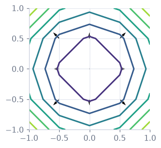

```python
fig, ax = plt.subplots(figsize=(3, 3))                     # a small square panel
ax.contour(X, Y, phi, levels=6)                            # six level curves of φ = x² + y² (circles, coarse on a 5×5 grid)
ax.quiver(X, Y, 2 * X, 2 * Y, scale=20)                    # the gradient (2x, 2y) as arrows
ax.set_aspect('equal'); plt.show()                         # arrows cross the circles at right angles
```

#### The maths, step by step

1. (2.22) $\nabla = \mathbf e_i\,\partial/\partial x_i$; on a scalar, $(\nabla\phi)_i = \partial\phi/\partial x_i$ — a vector (it passes $u'_j = u_iC_{ij}$ (2.8) by the chain rule; the residual table of C03 said so).
2. Along a contour φ is constant, so its rate of change along the tangent t is $\nabla\phi\cdot\mathbf t = 0$: ∇φ ⊥ level sets.
3. In direction n: $\partial\phi/\partial n = \nabla\phi\cdot\mathbf n = |\nabla\phi|\cos\alpha$ — maximal ($|\nabla\phi|$) for n ∥ ∇φ (the book's Fig. 2.7).
4. On the grid: the central difference $(\phi_{i+1} - \phi_{i-1})/2h$ with error ∝ h² (P21); at the edges a one-sided second-order stencil $(-3\phi_i + 4\phi_{i+1} - \phi_{i+2})/2h$ keeps the order.

#### ✏️ Tiny example: φ = x² + y² at (1, 2)

1. $\partial\phi/\partial x = 2x = 2$, $\partial\phi/\partial y = 2y = 4$: ∇φ = (2, 4), $|\nabla\phi| = \sqrt{20} = 4.472$.
2. Along $\mathbf n = (1, 0)$: $\partial\phi/\partial n = 2$.
3. Along the contour direction $(-2, 1)/\sqrt5$: $(-4 + 4)/\sqrt5 = 0$.
4. Along ∇φ itself: 4.472 — the steepest.
5. Central difference with h = 0.1 at x = 1: $(1.1^2 - 0.9^2)/0.2 = (1.21 - 0.81)/0.2 = 2.000$ — exact, because a quadratic has no third derivative.

*Gloss — observed order of convergence:* the slope of log(error) vs log(h) (🔁 Ch. 1 P13 read slopes on log–log axes); `tools.convergence.observed_order(h, err)` fits it by least squares. A second-order stencil has slope 2: halving h quarters the error.

```python
from tools.convergence import observed_order                       # least-squares slope of log(err) vs log(h) (gloss above)
g = ch02.grid2d(((-2, 2), (-2, 2)), 41)                            # 41×41 nodes on [−2, 2]²: h = 0.1 (P76)
phi = g.X**2 + g.Y**2                                              # φ at every node by broadcasting (P77)
grad = ch02.gradient(phi, g.h)                                     # (2.22) on a scalar: (∇φ)_i = ∂φ/∂x_i, components stacked on axis 0 as (x, y)
print(grad.shape, grad[:, 30, 30], (g.x[30], g.y[30]))            # (2, 41, 41); ∇φ at node (i, j) = (30, 30) = the point (1, 1): [2. 2.] — exact for a quadratic
print(ch02.directional_derivative(grad, [1, 0])[30, 30],           # ∂φ/∂n along e_1 at (1, 1): 2.0
      ch02.directional_derivative(grad, np.array([-1, 1]) / np.sqrt(2))[30, 30])   # along the contour direction at (1, 1): 0.0
ns = (8, 16, 32) if FAST else (8, 16, 32, 64)                      # grid sizes for the convergence study (FAST: three levels)
study = {op: ch02.operator_convergence(op, ns) for op in ("gradient", "divergence", "curl")}   # max error vs h on a sin/cos field (cached; reused in C15, C16)
print({op: round(s["order"], 2) for op, s in study.items()})       # observed orders ≈ 2.0 for all three
```

```
(2, 41, 41) [2. 2.] (np.float64(1.0), np.float64(1.0))
1.9999999999999973 0.0
```

```
{'gradient': 1.99, 'divergence': 1.99, 'curl': 2.05}
```

**What does the code above do?**

1. A 41×41 grid on [−2, 2]² (spacing h = 0.1) and φ at every node.
2. `gradient` applies `partial` along each coordinate direction; components are stacked on axis 0 as (x, y).
3. At the node (1, 1) the gradient is (2, 2) exactly (central differences are exact for quadratics).
4. `directional_derivative` is ∇φ·n: 2 along $\mathbf e_1$, 0 along the contour.
5. `operator_convergence` measures the max error of gradient, divergence and curl on a sin/cos field against the exact sympy derivatives for n = 8 … 64 nodes; the log–log slope is 2 — the stencils are second order, edges included.

```python
h = g.h[0]                                                                          # spacing in x
dphidx = np.zeros_like(phi)                                                         # ∂φ/∂x from scratch
dphidx[:, 1:-1] = (phi[:, 2:] - phi[:, :-2]) / (2 * h)                              # central difference inside (P21), along the LAST axis = x
dphidx[:, 0] = (-3 * phi[:, 0] + 4 * phi[:, 1] - phi[:, 2]) / (2 * h)               # second-order one-sided stencil at the left edge
dphidx[:, -1] = (3 * phi[:, -1] - 4 * phi[:, -2] + phi[:, -3]) / (2 * h)            # … and at the right edge
assert np.allclose(dphidx, ch02.partial(phi, 0, h))                                 # direction 0 = x; the library maps it to array axis 1 of the [j, i] layout
assert np.allclose(dphidx, grad[0])                                                 # and it is the first component of `gradient`
print("x is the LAST array axis in the [j, i] layout — `partial` takes the coordinate direction, not the axis")
```

```
x is the LAST array axis in the [j, i] layout — `partial` takes the coordinate direction, not the axis
```

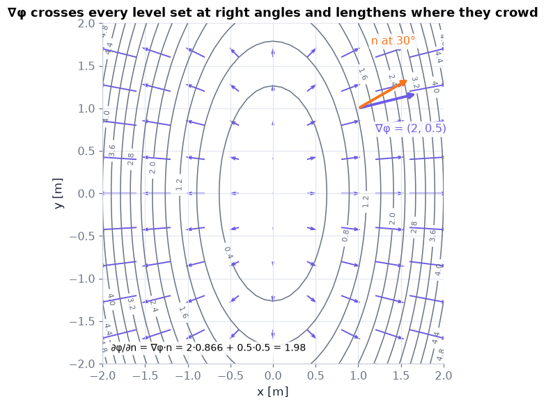

```python
phi7 = g.X**2 + g.Y**2 / 4                                                   # Fig. 2.7's scalar: ellipses as level sets
grad7 = ch02.gradient(phi7, g.h)                                             # its gradient on the grid
probe = np.array([1.0, 1.0]); gp = np.array([2 * probe[0], probe[1] / 2])    # the probe point and ∇φ there = (2, 0.5)
n30 = np.array([np.cos(np.deg2rad(30)), np.sin(np.deg2rad(30))])             # a direction n at 30°
dphidn = float(gp @ n30)                                                     # ∂φ/∂n = ∇φ·n = 2·0.866 + 0.5·0.5 = 1.98
fig, ax = plt.subplots(figsize=(6.2, 5.2))                                   # one square panel
cs = ax.contour(g.X, g.Y, phi7, levels=12, colors=COLORS["muted"], linewidths=1); ax.clabel(cs, fmt="%.1f", fontsize=7)   # level sets (P78)
sk = 4; ax.quiver(g.X[::sk, ::sk], g.Y[::sk, ::sk], grad7[0][::sk, ::sk], grad7[1][::sk, ::sk], color=COLORS["accent"], scale=28, width=0.004)   # ∇φ arrows
ax.annotate("", probe + 0.35 * gp, probe, arrowprops=dict(arrowstyle="->", color=COLORS["accent"], lw=2.5))       # bold ∇φ at the probe
ax.annotate("", probe + 0.7 * n30, probe, arrowprops=dict(arrowstyle="->", color=COLORS["orange"], lw=2.5))       # the direction n
box = dict(boxstyle="round,pad=0.2", fc="white", ec="none", alpha=0.9)                                             # white boxes keep the labels readable over the contours
ax.text(1.2, 0.72, "∇φ = (2, 0.5)", color=COLORS["accent"], bbox=box); ax.text(1.15, 1.75, "n at 30°", color=COLORS["orange"], bbox=box)
ax.text(-1.9, -1.85, f"∂φ/∂n = ∇φ·n = 2·0.866 + 0.5·0.5 = {dphidn:.2f}", fontsize=9, bbox=box)                    # the number
ax.set_aspect("equal"); ax.set_xlabel("x [m]"); ax.set_ylabel("y [m]"); ax.set_title("∇φ crosses every level set at right angles and lengthens where they crowd")
plt.show()
```

**What you see.** Elliptical contours of φ = x² + y²/4; purple arrows crossing every contour at right angles, longer where the contours crowd (left and right); at the probe (1, 1) a bold ∇φ and an orange n at 30° with ∂φ/∂n = 1.98.

**How to read it.** |∇φ| is the local contour density; n's projection on ∇φ is the slope you would feel walking along n — 1.98 here, against 2.06 = |∇φ| straight uphill. `N51`: this is our own Fig. 2.7.

**What would change if…** …you rotated n to lie along a contour (perpendicular to ∇φ, about 104° here): ∂φ/∂n → 0.

```python
ang = np.linspace(0, 2 * np.pi, 121)                                              # to draw the ellipses
def probe_dir(alpha_deg):                                                        # one slider position: n at angle α
    n_ = np.array([np.cos(np.deg2rad(alpha_deg)), np.sin(np.deg2rad(alpha_deg))])   # unit direction
    d = float(gp @ n_)                                                           # ∂φ/∂n = ∇φ·n at the probe
    out = {f"level set φ = {c}": (np.sqrt(c) * np.cos(ang), 2 * np.sqrt(c) * np.sin(ang)) for c in (0.5, 1.25, 2.5)}   # three fixed ellipses of x² + y²/4 = c
    out["∇φ at (1, 1)"] = ([1, 1 + 0.4 * gp[0]], [1, 1 + 0.4 * gp[1]])           # the gradient arrow (fixed)
    out["n (drag α)"] = ([1, 1 + 0.8 * n_[0]], [1, 1 + 0.8 * n_[1]])              # the turning direction
    out["∂φ/∂n · n  (the slope you feel)"] = ([1, 1 + 0.4 * d * n_[0]], [1, 1 + 0.4 * d * n_[1]])   # ∇φ·n drawn along n: positive uphill, negative downhill
    return out
fig = slider_figure(probe_dir, "α", np.linspace(0, 350, 36 if not FAST else 18), unit="°", xlabel="x [m]", ylabel="y [m]",
                    title="∂φ/∂n = ∇φ·n: largest along ∇φ, zero along the contour, negative downhill",
                    xrange=[-2.2, 3.4], yrange=[-3.4, 3.4], height=520, active=1)
fig.update_yaxes(scaleanchor="x", scaleratio=1)                                  # equal axes
fig.show()
```

[interactive chart not shown]

**What does the code above do?**

1. Three level sets of φ = x² + y²/4 are drawn as fixed ellipses; the gradient at the probe (1, 1) is (2, 0.5).
2. Dragging α turns the direction n; the third arrow has length ∇φ·n along n — it is the directional derivative made visible (positive uphill, shrinking to nothing along the contour, negative downhill).

**What you see.** Three ellipses, a fixed purple gradient arrow at (1, 1), and an orange direction n that turns with the slider; a third arrow along n whose length is ∂φ/∂n.

**How to read it.** The third arrow is longest ($|\nabla\phi| \approx 2.06$) when n ∥ ∇φ (α ≈ 14°), vanishes along the contour (α ≈ 104°) and reverses downhill (α ≈ 194°).

**What would change if…** …the probe sat at (0, 1): ∇φ = (0, 0.5) — a shorter arrow pointing straight up; the ellipses are flattest there.

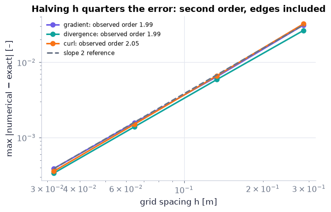

```python
fig, ax = plt.subplots(figsize=(6, 3.8))                                        # one panel, log–log
for op, col in zip(("gradient", "divergence", "curl"), (COLORS["accent"], COLORS["teal"], COLORS["orange"])):   # the three cached studies
    s = study[op]                                                                # dict(n, h, err, order)
    ax.loglog(s["h"], s["err"], "o-", color=col, label=f"{op}: observed order {s['order']:.2f}")   # error vs spacing
h_ref = np.array([study["gradient"]["h"].min(), study["gradient"]["h"].max()])   # for the reference line
ax.loglog(h_ref, study["gradient"]["err"].max() * (h_ref / h_ref.max())**2, "--", color=COLORS["muted"], label="slope 2 reference")   # ∝ h²
ax.set_xlabel("grid spacing h [m]"); ax.set_ylabel("max |numerical − exact| [–]"); ax.legend(fontsize=8)
ax.set_title("Halving h quarters the error: second order, edges included")
plt.show()
```

**What you see.** Three straight lines of slope 2 on log–log axes, parallel to the dashed reference.

**How to read it.** Halving h quarters the error — the stencil is second order also at the edges, thanks to the one-sided second-order stencil (the from-scratch cell above).

**What would change if…** …you replaced the edge stencil by a first-order one (the `np.gradient` default of Ch. 1 P22): the edge error would fall only like h and the slope would drop towards 1.

**What would change if…** ∇ acted on a vector instead? Two choices: contract the operator's index with the vector's (divergence, C10) or cross them with ε (curl, C11).

### 🧩 The divergence ∇·u = ∂u_i/∂x_i `C10`

*The question:* How much does a velocity field *spread out* at a point — and why is that one number the most used quantity in the book?

#### The problem in plain words

Mass conservation (Ch. 4): if more fluid leaves a tiny box than enters, the density inside must drop. "More leaves than enters" per unit volume is the divergence. For water and slow air ∇·u = 0 — the incompressibility condition that shapes every chapter after this one.

#### The idea

```
∂u_1/∂x_1 : does u_1 grow along x_1?  (stretching along 1)        ∇·u = sum of the three stretching rates
a box with more leaving than entering  →  ∇·u > 0  (source);  the same in and out  →  ∇·u = 0  (solenoidal)
```

#### The maths, step by step

1. Contract ∇'s index with u's: $\nabla\cdot\mathbf u = \partial u_i/\partial x_i = \partial u_1/\partial x_1 + \partial u_2/\partial x_2 + \partial u_3/\partial x_3$ (2.23) — a scalar.
2. It is the trace of the velocity gradient $G_{ij} = \partial u_i/\partial x_j$ (N52): $\nabla\cdot\mathbf u = G_{ii}$, hence an invariant (C07).
3. Ex. 2.3: $\mathbf u = a\mathbf x$: $\partial(ax_i)/\partial x_i = a\,\delta_{ii} = 3a$. *Gloss:* $\partial x_i/ \partial x_j = \delta_{ij}$ — each coordinate depends only on itself. The book's third term reads $ax_3\mathbf e_3$ (its "$ax_2\mathbf e_2$" printed twice is a misprint). $\mathbf u = \mathbf b\times\mathbf x$: $\partial(\varepsilon_ {lmk}b_lx_m)/\partial x_k = \varepsilon_{lmk}b_l\delta_{mk} = \varepsilon_{lkk}b_l = 0$.

📝 **Note.** **⚠️ Two index-order conventions to fix once** `N52` — The *gradient of a vector* raises the order: `ch02.vector_gradient(u, h)[i, j] = ∂u_i/∂x_j` (Kundu's Ch. 3 usage, $S_{ij} = \tfrac12(\partial u_i/\partial x_j + \partial u_j/\partial x_i)$). The *divergence of a tensor* lowers it and contracts the **second** index, $(\nabla\cdot\boldsymbol\tau)_i = \partial\tau_{ij}/\partial x_j$ — the opposite index from Cauchy's $f_i = \tau_{ji}n_j$; the two agree only for symmetric τ (Ch. 4's momentum equation uses $\partial\tau_{ij}/\partial x_j$). `ch02.tensor_divergence(T, h, index=1)` exposes the choice. (Comma notation for both: §2.14.)

$$ (\nabla\cdot\boldsymbol\tau)_i = \sum_{j=1}^{3} \frac{\partial\tau_{ij}}{\partial x_j} \equiv \frac{\partial\tau_{ij}}{\partial x_j} \qquad \text{(§2.9)} $$

#### ✏️ Tiny example: Ex. 2.3 with a = 1: u = x

1. $\mathbf u = (x_1, x_2, x_3)$.
2. $\partial u_1/\partial x_1 = 1$, likewise for 2 and 3.
3. $\nabla\cdot\mathbf u = 1 + 1 + 1 = 3 = 3a$ ✓ — every direction stretches at unit rate.
4. On the grid with h ≈ 0.04: central differences of a linear field are exact, so the code prints 3.000 at every point.

```python
g3 = ch02.grid(((-1, 1),) * 3, 48 if not FAST else 24)                # a 3-D grid on [−1, 1]³, layout [k, j, i] (P76); 48³ nodes (FAST: 24³)
u_rad = ch02.radial_field(1.0)(g3.X, g3.Y, g3.Z)                      # Ex. 2.3's u = a x with a = 1, evaluated by broadcasting: shape (3, n, n, n)
div = ch02.divergence(u_rad, g3.h)                                    # (2.23): ∂u_i/∂x_i on the grid
print(div.min(), div.max())                                           # 3.0 3.0 (to round-off): 3a everywhere
u_rot = ch02.solid_body_rotation_field([0, 0, 1.0])(g3.X, g3.Y, g3.Z) # Ex. 2.3's u = b × x with b = e_3
print(np.abs(ch02.divergence(u_rot, g3.h)).max(), ch02.is_solenoidal(u_rot, g3.h))   # ~1e-15, (True, residual): solenoidal
G = ch02.vector_gradient(u_rad, g3.h)                                 # G[i, j] = ∂u_i/∂x_j at every node (N52)
print(G[:, :, 5, 5, 5])                                               # the identity matrix: ∂x_i/∂x_j = δ_ij
print(np.allclose(np.einsum('ii...', G), div))                        # True: the divergence is the trace of G (C07); 'ii...' sums the diagonal at every grid point
X3 = sp.Matrix(ch02.coordinates(3))                                   # the library's sympy coordinates x1, x2, x3 (Ch. 1 P40, P61) — the SAME symbols the fields differentiate with respect to
a_sym = sp.Symbol('a')                                                # a symbolic amplitude
div_sym, curl_sym = ch02.exact_div_curl(a_sym * X3)                   # the symbolic twin of Ex. 2.3: ∇·(a x) and ∇×(a x)
print(div_sym, curl_sym)                                              # 3*a [0, 0, 0]
assert div_sym != 0 and float(div_sym.subs(a_sym, 1.0)) == 3.0 and np.allclose(float(div_sym.subs(a_sym, 1.0)), div.mean())   # the symbolic 3a is non-zero and equals the grid value
assert all(c == 0 for c in curl_sym)                                  # and the curl of a x is exactly zero
```

```
2.999999999999993 3.0000000000000044
2.609024107869118e-15 (True, 2.609024107869118e-15)
[[1. 0. 0.]
 [0. 1. 0.]
 [0. 0. 1.]]
True
3*a [0, 0, 0]
```

**What does the code above do?**

1. A 3-D grid (kept for C11 and C12).
2. `radial_field(1.0)` is a callable field with sympy behind it; evaluated on the grid arrays it returns the three components stacked on axis 0.
3. Its divergence, $\nabla\cdot\mathbf u = \partial u_i/\partial x_i$ (2.23), is 3 everywhere — exact, because the field is linear.
4. The rotation field is solenoidal: its divergence is zero to round-off.
5. The velocity gradient of u = x is δ_ij at every node; its trace is the divergence.
6. `exact_div_curl` computes the same symbolically: 3a and [0, 0, 0] — built on the library's own coordinate symbols (`ch02.coordinates(3)`); the assertions check the symbolic value is non-zero and equals the grid's 3.

```python
div_mine = (ch02.partial(u_rad[0], 0, g3.h[0])                        # ∂u_1/∂x_1: component 0 differentiated along coordinate direction 0 (x)
            + ch02.partial(u_rad[1], 1, g3.h[1])                      # ∂u_2/∂x_2
            + ch02.partial(u_rad[2], 2, g3.h[2]))                     # ∂u_3/∂x_3
assert np.allclose(div_mine, div)                                     # (2.23) written out = the library's divergence
print("component c is differentiated along coordinate direction c; inside `partial`, direction 0 (x) is array axis 2 of [k, j, i]")
```

```
component c is differentiated along coordinate direction c; inside `partial`, direction 0 (x) is array axis 2 of [k, j, i]
```

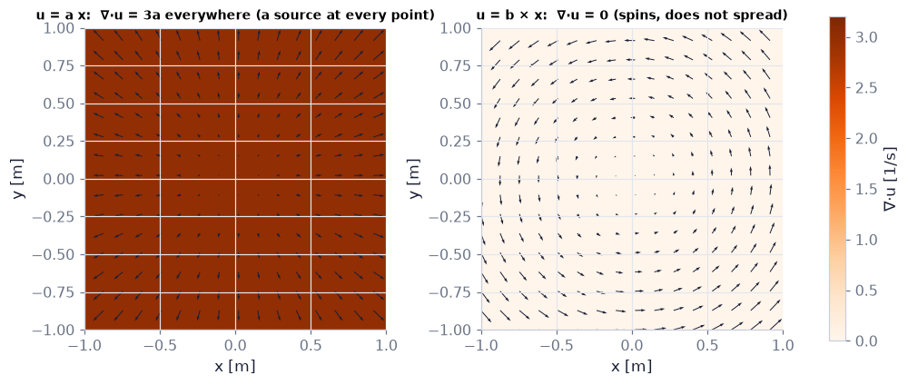

```python
k0 = g3.X.shape[0] // 2                                               # the slice index closest to z = 0
sk = 3 if not FAST else 2                                             # quiver thinning
fig, axs = plt.subplots(1, 2, figsize=(9, 4.2))                       # left: u = a x, right: u = b × x
for ax, U, ttl in zip(axs, (u_rad, u_rot), ("u = a x:  ∇·u = 3a everywhere (a source at every point)", "u = b × x:  ∇·u = 0 (spins, does not spread)")):
    dv = ch02.divergence(U, g3.h)[k0]                                 # the z = 0 slice of ∇·u
    im = ax.imshow(dv, origin="lower", extent=(-1, 1, -1, 1), cmap="Oranges", vmin=0, vmax=3.2)   # heatmap: 0 white … 3 orange
    ax.quiver(g3.X[k0, ::sk, ::sk], g3.Y[k0, ::sk, ::sk], U[0][k0, ::sk, ::sk], U[1][k0, ::sk, ::sk], color=COLORS["ink"], scale=25, width=0.003)   # the field's arrows
    ax.set_title(ttl, fontsize=9); ax.set_xlabel("x [m]"); ax.set_ylabel("y [m]"); ax.set_aspect("equal")
fig.colorbar(im, ax=axs, shrink=0.8, label="∇·u [1/s]")
plt.show()
```

**What you see.** Left: spreading arrows and a uniform orange square (∇·u = 3). Right: circling arrows and a blank white square (∇·u = 0).

**How to read it.** Divergence measures spreading, not speed — the rotating field is fast at the rim yet has zero divergence everywhere.

**What would change if…** …u = (x, −y, 0): stretch in x, squeeze in y, divergence 1 − 1 = 0 — solenoidal without rotating (a pure strain).

*Forward pointer:* the exact tracer positions in the next animation are $\mathbf x(t) = e^{\mathbf Gt}\mathbf x_0$ from `ch02.linear_flow_map(G, t)` — the matrix exponential is primed in C12 (P79); here it is only a way to move the dots exactly.

```python
from fluidpy.core.anim import animate                                     # (Ch. 1 P16)
n_fr = 40 if not FAST else 24                                             # frames (FAST: 24)
ts = np.linspace(0, 0.6, n_fr)                                            # time [s]
ang = np.linspace(0, 2 * np.pi, 40, endpoint=False)                       # a ring of tracers …
ring0 = 0.5 * np.stack([np.cos(ang), np.sin(ang)])                        # … of radius 0.5 m
G_src = 1.0 * np.eye(2)                                                   # velocity gradient of u = a x (a = 1/s): G = a I
G_rot = np.array([[0., -1.], [1., 0.]])                                   # velocity gradient of u = b × x (b = 1/s): G = [b×]
fig, axs = plt.subplots(1, 2, figsize=(8, 3.9))                           # left: source, right: rotation
fig.set_layout_engine("none")                                             # fixed layout: the automatic layout engine would re-run on every frame
dots = []                                                                 # the scatter artists to move
for ax, ttl in zip(axs, ("u = a x:  ∇·u = 3a, ∇×u = 0", "u = b × x:  ∇·u = 0, ∇×u = 2b")):
    ax.plot(*ring0, ".", color=COLORS["muted"], ms=3)                     # the ring at t = 0 (grey ghost)
    dots.append(ax.scatter(*ring0, s=14, color=COLORS["accent"]))         # the moving ring
    ax.set_xlim(-1.1, 1.1); ax.set_ylim(-1.1, 1.1); ax.set_aspect("equal"); ax.set_title(ttl, fontsize=9); ax.set_xlabel("x [m]")
    ax.set_xticks([-1, 0, 1]); ax.set_yticks([-1, 0, 1])                  # few tick labels: text is what makes video frames slow to draw
txt = fig.text(0.5, 0.01, "", ha="center")                                # the clock
def update(i):                                                            # frame i
    for d, G_ in zip(dots, (G_src, G_rot)):                               # each panel
        d.set_offsets((ch02.linear_flow_map(G_, ts[i]) @ ring0).T)        # exact tracer positions x(t) = e^{Gt} x_0
    txt.set_text(f"t = {ts[i]:.2f} s")
    return (*dots, txt)
show_animation(animate(update, frames=n_fr, fig=fig, interval=60), player="video")   # smooth MP4
```

[video not shown]

**What does the code above do?**

1. Forty tracer dots on a ring of radius 0.5 m; each frame moves them exactly with the linear flow's map.
2. Left: u = a x — the ring expands (∇·u = 3a; in this plane the ring's area grows at rate 2a per unit area). Right: u = b × x — the ring turns rigidly and keeps its size (∇·u = 0); its spin is half the curl 2b (C11).

**What you see.** One ring grows; the other spins without changing size.

**How to read it.** Divergence is the rate at which the ring's area grows (2a per unit area in this plane, 3a per unit volume in 3-D); curl is twice the ring's spin rate.

**What would change if…** …a < 0: the ring shrinks — a sink; a mixed G = a I + [b×] would do both at once.

**What would change if…** you crossed ∇ with u instead of dotting? The curl — spin instead of spread.

### 🧩 The curl ∇×u = ε_ijk ∂u_k/∂x_j `C11`

*The question:* How much does a velocity field *spin* at a point — and why does a perfectly straight shear flow have curl?

#### The problem in plain words

Vorticity — the curl of the velocity — is the subject of Ch. 5 and half of Ch. 13: hurricanes, ocean gyres and the planetary vorticity $2\boldsymbol\Omega$ are all $\nabla\times\mathbf u$. A paddle wheel dropped into the flow turns at half the curl. It turns in a whirlpool — and also in a straight river whose speed varies across the channel.

#### The idea

```
(∇×u)_3 = ∂u_2/∂x_1 − ∂u_1/∂x_2 :  does u_2 grow to the right?  (+)   does u_1 grow upward?  (−)
a paddle wheel spins if the flow on one side is faster than on the other   →  shear flow has curl
ε_ijk ∂_j u_k = "cross ∇ with u" with the operator on the left: ∂ acts on u_k, never the other way round
```

#### The maths, step by step

1. (2.21), $(\mathbf u\times\mathbf v)_k = \varepsilon_{ijk}u_iv_j$, with $u_i \to \partial/\partial x_j$: $(\nabla\times\mathbf u)_i = \varepsilon_{ijk}\,\partial u_k/\partial x_j$ (2.24), operator ordering: ∂ acts on u.
2. D12 below expands it into the three components $(\nabla\times\mathbf u)_1 = \partial u_3/\partial x_2 - \partial u_2/\partial x_3$ (and cyclically) (2.25).
3. Ex. 2.3: $\mathbf u = a\mathbf x$: $\varepsilon_{ijk}\partial(ax_k)/\partial x_j = a\varepsilon_{ijk}\delta_{jk} = a\varepsilon_{ijj} = 0$ — irrotational. $\mathbf u = \mathbf b\times\mathbf x$: $\varepsilon_{ijk}\partial_j( \varepsilon_{lmk}b_lx_m) = \varepsilon_{ijk}\varepsilon_{lmk}b_l\delta_{mj} = \varepsilon_{ijk}\varepsilon_{ljk}b_l = 2\delta_{il}b_l = 2b_i$ (the 2δ contraction of D09): **the curl of a solid-body rotation is twice its angular velocity** — Ch. 3's vorticity = 2Ω.

#### 🧮 Derivation — The three components of the curl (Eq. 2.25)

**What we want to show.** Turn the index form of the curl into the three explicit component formulas — and see why only two of the nine terms survive for each component.

**Assumptions.** u differentiable (the partial derivatives exist; every step).

**The plan.**

1. Fix i = 1.
2. Keep only the (j, k) pairs where ε ≠ 0.
3. Insert ±1.
4. Relabel cyclically for i = 2, 3.

**Tools we use** (each explained before this point): enumeration of ε, $\varepsilon_{ijk} = +1$ (cyclic), $-1$ (anticyclic), $0$ (an index repeated) (2.18) (C08) · the cross product in index form (2.21) (N49) · operator ordering: ∂ acts on u_k (gloss in the start line) · partial derivative (Ch. 1 P25)

**We start from**

$$ (\nabla\times\mathbf u)_i = \varepsilon_{ijk}\,\frac{\partial u_k}{\partial x_j} $$

*In words:* (2.24): the cross product $(\mathbf u\times\mathbf v)_k = \varepsilon_{ijk}u_iv_j$ (2.21) with the first vector replaced by the operator ∇ = e_j ∂/∂x_j, acting to the right.

**Step 1 of 5 — Write (2.24) for i = 1 with both sums.**

$$ (\nabla\times\mathbf u)_1 = \sum_{j=1}^{3}\sum_{k=1}^{3}\varepsilon_{1jk}\,\frac{\partial u_k}{\partial x_j} $$

- *Why we can do this:* The summation convention (C01) hides a double sum over j and k — nine terms. We write it out to see which terms are nonzero.
- *In words:* Nine candidate terms for the first component.

**Step 2 of 5 — Drop the terms with a repeated index.**

$$ (\nabla\times\mathbf u)_1 = \varepsilon_{123}\,\frac{\partial u_3}{\partial x_2} + \varepsilon_{132}\,\frac{\partial u_2}{\partial x_3} $$

- *Why we can do this:* ε vanishes whenever two indices agree, $\varepsilon_{1jj} = 0$ (2.18); with i = 1 fixed, only (j, k) = (2, 3) and (3, 2) avoid a repeat. Seven terms die.
- *In words:* Only the two "other" directions contribute.

**Step 3 of 5 — Insert the values of ε.**

$$ (\nabla\times\mathbf u)_1 = \frac{\partial u_3}{\partial x_2} - \frac{\partial u_2}{\partial x_3} $$

- *Why we can do this:* 123 is cyclic, so $\varepsilon_{123} = +1$; 132 is anticyclic, so $\varepsilon_{132} = -1$ (2.18). The minus sign comes from ε, not from the derivative.
- *In words:* The first component is a difference of two cross-derivatives.

**Step 4 of 5 — Relabel cyclically for i = 2.**

$$ (\nabla\times\mathbf u)_2 = \frac{\partial u_1}{\partial x_3} - \frac{\partial u_3}{\partial x_1} $$

- *Why we can do this:* Replacing every index by its cyclic successor 1 → 2 → 3 → 1 leaves ε unchanged (a two-place move, N43), so step 3 maps to this line. The survivors are now (j, k) = (3, 1) and (1, 3).
- *In words:* Second component: the same pattern one step round the cycle.

**Step 5 of 5 — Relabel once more for i = 3 and assemble.**

$$ (\nabla\times\mathbf u)_3 = \frac{\partial u_2}{\partial x_1} - \frac{\partial u_1}{\partial x_2} $$

- *Why we can do this:* Another cyclic step; survivors (1, 2) and (2, 1). The three lines together are (2.25). Throughout, ∂/∂x_j acts on u_k — $u_k\,\partial_j$ would be an operator, not a number.
- *In words:* Third component: does u₂ grow along 1 more than u₁ grows along 2?

**Result**

$$ (\nabla\times\mathbf u)_1 = \partial_2u_3 - \partial_3u_2,\quad (\nabla\times\mathbf u)_2 = \partial_3u_1 - \partial_1u_3,\quad (\nabla\times\mathbf u)_3 = \partial_1u_2 - \partial_2u_1 $$

*In words:* each component of the curl is the "cross-derivative" of the other two velocity components.

**What it means.** The curl measures the local spin: a paddle wheel turns at half of it (D15 + Ex. 2.3). It is nonzero for a straight shear flow and zero for the irrotational vortex away from its core — spin is about differences of speed across a point, not about curved paths. Requires differentiable u; at a vortex core the formula is undefined and the circulation (D26) takes over.

**Check it.** Units: (m/s)/m = 1/s ✓. Number (Ex. 2.3, u = b × x = (−x₂, x₁, 0)): $(\nabla\times\mathbf u)_3 = 1 - (-1) = 2 = 2b_3$, the other two 0 ✓ (`curl_components` = `curl` below). Shear flow $u_1 = \Gamma x_2$: $(\nabla\times\mathbf u)_3 = 0 - \Gamma = -\Gamma$ ✓.

> ⚠️ **Common confusion (traps in this derivation):** writing $u_k\partial_j$. Losing the minus from $\varepsilon_{132}$. Doing i = 1 and saying "similarly" — the cyclic relabelling is the reason, and it is said.

📝 **Note.** **The three components (2.25)** `N53` — D12's result; `ch02.curl_components(u, h)` writes them out and is asserted equal to the einsum form `ch02.curl` below.

$$ (\nabla\times\mathbf u)_1 = \frac{\partial u_3}{\partial x_2} - \frac{\partial u_2}{\partial x_3}, \quad (\nabla\times\mathbf u)_2 = \frac{\partial u_1}{\partial x_3} - \frac{\partial u_3}{\partial x_1}, \quad (\nabla\times\mathbf u)_3 = \frac{\partial u_2}{\partial x_1} - \frac{\partial u_1}{\partial x_2} \qquad \text{(2.25)} $$

📝 **Note.** **Solenoidal and irrotational** `N54` — **Solenoidal** (∇·u = 0; the word comes from magnetism — a field with no sources) and **irrotational** (∇×u = 0). Incompressible flow (Ch. 4) is solenoidal; potential flow (Ch. 6) is both; Ch. 3 explains why "irrotational" means no local spin. `ch02.is_solenoidal`, `ch02.is_irrotational`.

📝 **Note.** **Ex. 2.3, stated** `N55` — $a\mathbf x$: divergence 3a, curl 0; $\mathbf b\times\mathbf x$: divergence 0, curl 2b — the worked numbers of C10 and here, by hand above and by sympy below; pointer: vorticity = 2Ω (Ch. 3 §3.5).

#### ✏️ Tiny example: Ex. 2.3 with b = e₃: u = (−x₂, x₁, 0)

1. $(\nabla\times\mathbf u)_3 = \partial u_2/\partial x_1 - \partial u_1/\partial x_2 = 1 - (-1) = 2$.
2. $(\nabla\times\mathbf u)_1 = \partial u_3/\partial x_2 - \partial u_2/\partial x_3 = 0 - 0 = 0$, likewise component 2.
3. $\nabla\times\mathbf u = (0, 0, 2) = 2\mathbf b$ ✓.
4. A straight shear flow $u_1 = \Gamma x_2$: $(\nabla\times\mathbf u)_3 = 0 - \Gamma = -\Gamma$ — curl without a single curved streamline (the paddle wheel turns clockwise for Γ > 0).

```python
w = ch02.curl(u_rot, g3.h)                                                     # (2.24) on the grid: ε_ijk ∂u_k/∂x_j, shape (3, n, n, n)
print(w[:, 5, 5, 5], np.abs(w[2] - 2).max())                                   # [0 0 2] and ~1e-14: ∇×(b × x) = 2b everywhere
print(np.allclose(np.stack(ch02.curl_components(u_rot, g3.h)), w))             # True: (2.25) written out = the einsum form (N53)
print(ch02.is_irrotational(u_rad, g3.h)[0], ch02.is_irrotational(u_rot, g3.h)[0])   # True False: a x has no spin, b × x does
div_sym, curl_sym = ch02.exact_div_curl(sp.Matrix([0, 0, 1]).cross(X3))        # the sympy twin of b × x on the library's coordinates X3 (C10)
print(div_sym, curl_sym)                                                       # 0 [0, 0, 2]
assert div_sym == 0 and list(curl_sym) == [0, 0, 2] and np.allclose([float(c) for c in curl_sym], w[:, 5, 5, 5])   # non-zero curl 2b, equal to the grid value
Xs = ch02.coordinates(3)                                                       # sympy symbols x1, x2, x3 (the field's coordinates)
shear3 = ch02.VectorField([Xs[1], 0, 0], Xs, name="simple shear u1 = Γ x2, Γ = 1")   # the straight shear flow as a 3-D field (Γ = 1/s)
u_sh = shear3(g3.X, g3.Y, g3.Z)                                                # on the grid (kept for C12)
print(ch02.curl(u_sh, g3.h)[2, 5, 5, 5])                                       # −1.0 = −Γ: straight streamlines, nonzero curl
```

```
[0. 0. 2.] 4.884981308350689e-15
True
True False
0 [0, 0, 2]
-0.9999999999999989
```

**What does the code above do?**

1. The curl of the rotation field is (0, 0, 2b) at every node — exact for a linear field.
2. The three explicit components $(\nabla\times\mathbf u)_1 = \partial u_3/\partial x_2 - \partial u_2/\partial x_3$ (and cyclically) (2.25) agree with the einsum form $(\nabla\times\mathbf u)_i = \varepsilon_{ijk}\,\partial u_k/\partial x_j$ (2.24).
3. The radial field is irrotational, the rotating one is not.
4. The sympy twin gives divergence 0 and curl [0, 0, 2] symbolically, asserted equal to the grid's curl.
5. The straight shear flow $u_1 = \Gamma x_2$ (built as a `VectorField` from sympy expressions) has curl −Γ.

```python
dx = lambda f, c: ch02.partial(f, c, g3.h[c])                                  # ∂f/∂x_c along coordinate direction c (Ch. 1 P29: a one-line function)
w_mine = np.stack([dx(u_rot[2], 1) - dx(u_rot[1], 2),                          # (∇×u)_1 = ∂u_3/∂x_2 − ∂u_2/∂x_3   (2.25)
                   dx(u_rot[0], 2) - dx(u_rot[2], 0),                          # (∇×u)_2 = ∂u_1/∂x_3 − ∂u_3/∂x_1
                   dx(u_rot[1], 0) - dx(u_rot[0], 1)])                         # (∇×u)_3 = ∂u_2/∂x_1 − ∂u_1/∂x_2
assert np.allclose(w_mine, w)                                                  # = the library's einsum curl
print("the three cross-derivative differences of D12 = curl()")
```

```
the three cross-derivative differences of D12 = curl()
```

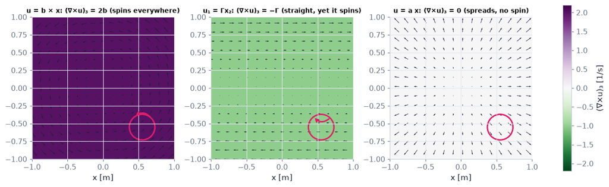

```python
fields = [(u_rot, "u = b × x: (∇×u)₃ = 2b (spins everywhere)"),                 # the whirlpool
          (u_sh, "u₁ = Γx₂: (∇×u)₃ = −Γ (straight, yet it spins)"),              # the straight shear flow
          (u_rad, "u = a x: (∇×u)₃ = 0 (spreads, no spin)")]                     # the source
fig, axs = plt.subplots(1, 3, figsize=(12, 4.2))                                # three heatmaps
for ax, (U, ttl) in zip(axs, fields):                                           # one panel per field
    c3 = ch02.curl(U, g3.h)[2, k0]                                              # the z = 0 slice of (∇×u)_3
    im = ax.imshow(c3, origin="lower", extent=(-1, 1, -1, 1), cmap="PRGn_r", vmin=-2.2, vmax=2.2)   # purple positive, green negative
    ax.quiver(g3.X[k0, ::sk, ::sk], g3.Y[k0, ::sk, ::sk], U[0][k0, ::sk, ::sk], U[1][k0, ::sk, ::sk], color=COLORS["ink"], scale=25, width=0.003)   # the flow's arrows
    wheel = plt.Circle((0.55, -0.55), 0.18, fill=False, color=COLORS["rose"], lw=2); ax.add_patch(wheel)   # a paddle wheel glyph
    spin = float(c3[k0 // 2, -k0 // 2 - 1]) if c3.shape[0] > 4 else 0.0        # its local (∇×u)₃ sets the arrow's sense
    if abs(spin) > 1e-6:                                                        # curved arrow: counterclockwise for positive curl, clockwise for negative
        ax.annotate("", (0.55 + 0.18 * np.cos(2.2), -0.55 + 0.18 * np.sin(2.2)), (0.55 + 0.18 * np.cos(0.8), -0.55 + 0.18 * np.sin(0.8)),   # from angle 0.8 to 2.2 rad on the wheel
                    arrowprops=dict(arrowstyle="->", color=COLORS["rose"], lw=2, connectionstyle=f"arc3,rad={0.5 if spin > 0 else -0.5}"))   # the arc's sense follows the sign
    ax.set_title(ttl, fontsize=9); ax.set_xlabel("x [m]"); ax.set_aspect("equal")   # labels
fig.colorbar(im, ax=axs, shrink=0.8, label="(∇×u)₃ [1/s]")                    # one shared colour scale
plt.show()                                                                      # display
```

**What you see.** Three heatmaps of (∇×u)₃ with the flow's arrows: uniform purple for the whirlpool (+2), uniform green for the straight shear flow (−1), white for the source (0); a paddle-wheel glyph shows the spin sense.

**How to read it.** Curl is the *difference* of speeds across the wheel, not curvature of streamlines: the straight shear flow is as coloured as the whirlpool, and the spreading source has none.

**What would change if…** …you used the *irrotational vortex* — a flow circling the origin with speed $u_\theta = K/r$ (K a constant, m²/s), the speed blowing up at r = 0 (the explainer's preset): curl 0 everywhere except the centre — a whirlpool with no local spin, the case Stokes' theorem (C16) cannot handle across the core.

#### 🎮 Interactive: How much does the flow go round a loop?

Curl and circulation are two views of one thing; dragging a loop over a shear flow (curl without curves) and over an irrotational vortex (curves without curl) removes the confusion no static figure can. (Its theorem, Stokes', is proved in C16 — this explainer is embedded once, here where the curl first bites.)

**What to try:**

- Shear preset: the streamlines are straight, yet the wheel turns and Γ ≠ 0.
- Irrotational-vortex preset: shrink the loop away from the centre — Γ/A → 0; enclose the centre — Γ = 2πK whatever the size (the ⚠️ status).
- Flip the orientation: both sides of $\iint_A(\nabla\times\mathbf u)\cdot\mathbf n\,dA = \oint_C\mathbf u\cdot\mathbf t\,ds$ (2.34) change sign together.
- Rectangle mode: read the four side sums of Ex. 2.6 in the Explain tab.

```python
show_viz("ch02", "stokes_circulation_loop")   # full-width explainer; ⤢ Full screen for more room
```

🎮 Interactive 3/5 How much does the flow go round a loop? Open alone ↗

[interactive chart not shown]

**What would change if…** you split the velocity gradient $G_{ij}$ into its symmetric and antisymmetric halves? The antisymmetric half *is* the curl, packed into a matrix — C12.

## 2.10 Symmetric and Antisymmetric Tensors

**What is this section about?** Every second-order tensor splits uniquely into a symmetric part (6 numbers) and an antisymmetric part (3 numbers). The antisymmetric part is a vector in disguise, and a symmetric tensor cannot see it — the two facts Ch. 3 (strain vs rotation) and Ch. 4 (dissipation) are built on.

### 🧩 Every tensor is a symmetric plus an antisymmetric part — and the antisymmetric part is a vector `C12`

*The question:* A fluid element both stretches and spins. How does the velocity gradient split those two motions apart — and why does the spin hide inside three numbers?

#### The problem in plain words

Ch. 3 will take the velocity gradient $G_{ij} = \partial u_i/\partial x_j$ (nine numbers) and ask: how fast is the fluid element being deformed, and how fast is it turning? The answer is a split: $\mathbf G = \mathbf S + \mathbf A$, S symmetric (the strain rate — deformation), A antisymmetric (the rotation rate — spin). Ch. 4 then shows viscous friction costs energy only through S. So the split is not algebra for its own sake; it separates the motion that heats the fluid from the motion that does not.

#### The idea

```
B = ½(B + Bᵀ) + ½(B − Bᵀ) = S + A       S_ij = S_ji (6 free numbers)     A_ij = −A_ji, A_ii = 0 (3 free numbers)
R =  [  0   −ω₃   ω₂ ]                  three numbers → one vector ω ;  R·x = ω × x  (R rotates x about ω)
     [  ω₃   0   −ω₁ ]
     [ −ω₂   ω₁   0  ]
simple shear u₁ = Γx₂ :  G = [[0, Γ],[0, 0]] = ½[[0, Γ],[Γ, 0]] + ½[[0, Γ],[−Γ, 0]]  = stretch at 45° + spin at Γ/2
```

*Two closely related objects, kept apart on purpose:* the book's **rotation tensor** $R_{ij} = \partial u_i/\partial x_j - \partial u_j/\partial x_i = G - G^{\rm T}$ (no ½) packs the **vorticity** $\boldsymbol\omega = \nabla\times\mathbf u$ by $R_{ij} = -\varepsilon_{ijk}\omega_k$, $\omega_k = -\tfrac12\varepsilon_{ijk}R_{ij}$ (2.26)–(2.27); the **antisymmetric part** $\mathbf A = \tfrac12(\mathbf G - \mathbf G^{\rm T}) = \tfrac12\mathbf R$ packs $\tfrac12\boldsymbol\omega = \tfrac12\nabla\times\mathbf u$, the angular velocity of a material line.

> 📎 **Primer — scipy.linalg.expm.** `P79` · For a linear velocity field u = G·x the trajectory is $\mathbf x(t) = e^{\mathbf Gt}\mathbf x_0$, where the matrix exponential $e^{\mathbf Gt} = \mathbf I + \mathbf Gt + (\mathbf Gt)^2/2 + \dots$. `scipy.linalg.expm(G*t)` computes it; for a pure rotation matrix it returns the rotation by angle |ω|t. `ch02.linear_flow_map(G, t)` wraps it.

```python
from scipy.linalg import expm                              # the matrix exponential
G_rot = np.array([[0., -1.], [1., 0.]])                    # u = (−y, x): solid-body rotation at 1 rad/s
print(np.round(expm(G_rot * np.pi / 2), 12))               # rotation by 90°: [[0, −1], [1, 0]]
```

```
[[ 0. -1.]
 [ 1.  0.]]
```

#### The maths, step by step

1. Add and subtract $\tfrac12B_{ji}$: $B_{ij} = \tfrac12(B_{ij} + B_{ji}) + \tfrac12(B_{ij} - B_{ji}) = S_{ij} + A_{ij}$ — D14 shows the split is unique and frame-independent.
2. Counting: a symmetric 3×3 has 3 diagonal + 3 off-diagonal = 6 independent entries; an antisymmetric one has zero diagonal and 3 (N56).
3. Pack a vector into an antisymmetric tensor: $R_{ij} = -\varepsilon_{ijk}\omega_k$ (2.26)–(2.27) and unpack it: $\omega_k = -\tfrac12\varepsilon_{ijk}R_{ij}$ — D15, which also shows $\mathbf R\cdot\mathbf x = \boldsymbol\omega \times\mathbf x$.
4. A symmetric τ against any B: $\tau_{ij}B_{ij} = \tau_{ij}S_{ij}$, because $\tau_{ij}A_{ij} = 0$ (N59–N61).

📝 **Note.** **Definitions** `N56` — symmetric $B_{ij} = B_{ji}$ (6 independent), antisymmetric $B_{ij} = -B_{ji}$ (zero diagonal, 3 independent); `ch02.independent_components` → 6 / 3 / 9.

#### 🧮 Derivation — The unique split into symmetric and antisymmetric parts (§2.10)

**What we want to show.** Show that any second-order tensor is the sum of a symmetric and an antisymmetric tensor in exactly one way, and that both parts are themselves tensors — the basis of Ch. 3's strain rate and rotation rate.

**Assumptions.** None beyond B being a tensor (step 6).

**The plan.**

1. Add and subtract half the transpose.
2. Check the symmetry of each half.
3. Suppose a second split and show it coincides.
4. Transform each half with $\tau'_{mn} = C_{im}C_{jn}\tau_{ij}$ (2.12).

**Tools we use** (each explained before this point): transpose $B_{ji}$ (P63) · the definitions of symmetric and antisymmetric (N56) · linearity of $\tau'_{mn} = C_{im}C_{jn}\tau_{ij}$ (2.12) (C06) · dummy renaming (N12) · "both symmetric and antisymmetric ⇒ zero" (step 5)

**We start from**

$$ B_{ij}\ \text{— any second-order tensor} $$

*In words:* nine numbers that transform by $\tau'_{mn} = C_{im}C_{jn}\tau_{ij}$ (2.12).

**Step 1 of 6 — Add and subtract $\tfrac12B_{ji}$.**

$$ B_{ij} = \tfrac12(B_{ij} + B_{ji}) + \tfrac12(B_{ij} - B_{ji}) $$

- *Why we can do this:* The right side is $\tfrac12B_{ij} + \tfrac12B_{ij}$ plus and minus the same $\tfrac12B_{ji}$ — an identity. We choose the transpose because swapping i and j is the operation whose behaviour we want to separate.
- *In words:* Split B into "the part that ignores the swap" and "the part that flips".

**Step 2 of 6 — Name the first half and swap its indices.**

$$ S_{ij} \equiv \tfrac12(B_{ij} + B_{ji}),\qquad S_{ji} = S_{ij} $$

- *Why we can do this:* Swapping i ↔ j in the definition gives $\tfrac12(B_{ji} + B_{ij})$, the same sum in the other order. S is symmetric by construction.
- *In words:* The first half does not notice the swap.

**Step 3 of 6 — Name the second half and swap its indices.**

$$ A_{ij} \equiv \tfrac12(B_{ij} - B_{ji}),\qquad A_{ji} = -A_{ij},\quad A_{ii} = 0 $$

- *Why we can do this:* Swapping gives $\tfrac12(B_{ji} - B_{ij}) = -A_{ij}$; for i = j the difference vanishes. A is antisymmetric with zero diagonal — three independent entries.
- *In words:* The second half changes sign under the swap and has an empty diagonal.

**Step 4 of 6 — Suppose another split and subtract.**

$$ B = \tilde S + \tilde A\ \Rightarrow\ \tilde S_{ij} - S_{ij} = A_{ij} - \tilde A_{ij} \equiv X_{ij} $$

- *Why we can do this:* If a second symmetric $\tilde S$ and antisymmetric $\tilde A$ also add to B, subtracting the two splits and moving terms gives one object X written two ways. This is the uniqueness half the book omits.
- *In words:* Any other split differs from ours by one tensor X.

**Step 5 of 6 — Show X is zero.**

$$ X_{ij} = X_{ji} = -X_{ij}\ \Rightarrow\ X_{ij} = 0 $$

- *Why we can do this:* X is a difference of symmetric tensors (so symmetric) and a difference of antisymmetric ones (so antisymmetric); a number equal to its own negative is zero. Hence $\tilde S = S$, $\tilde A = A$.
- *In words:* Only the zero tensor is both symmetric and antisymmetric — the split is unique.

**Step 6 of 6 — Transform S with (2.12).**

$$ S'_{mn} = \tfrac12(B'_{mn} + B'_{nm}) = C_{im}C_{jn}\,\tfrac12(B_{ij} + B_{ji}) = C_{im}C_{jn}S_{ij} $$

- *Why we can do this:* (2.12) is linear, so it applies to each term; in the second term $B'_{nm} = C_{in}C_{jm}B_{ij}$, and renaming the dummies i ↔ j turns it into $C_{im}C_{jn}B_{ji}$. The same lines with a minus give A.
- *In words:* The symmetric part of the transformed B is the transformed symmetric part — S and A are tensors.

**Result**

$$ B_{ij} = S_{ij} + A_{ij},\quad \mathbf S = \tfrac12(\mathbf B + \mathbf B^{\rm T}),\quad \mathbf A = \tfrac12(\mathbf B - \mathbf B^{\rm T})\ \text{— unique, both tensors; } 6 + 3 = 9 $$

*In words:* every tensor is a stretch-like part plus a spin-like part, and every observer agrees on the split.

**What it means.** For the velocity gradient $\partial u_i/\partial x_j$, S is the strain rate (how a fluid element deforms) and A the rotation rate (how it spins) — Ch. 3 §3.4; Ch. 4's viscous dissipation sees only S (N59–N61). Frame-independence (step 6) is what lets us compute the split in any convenient axes.

**Check it.** Units: those of B ✓. Limit: B symmetric ⇒ A = 0; B antisymmetric ⇒ S = 0 ✓. Number: B = [[0, 2], [0, 0]]: S = [[0, 1], [1, 0]], A = [[0, 1], [−1, 0]], S + A = B ✓ (`symmetric_part`, `antisymmetric_part` below); `independent_components` 6, 3, 9.

> ⚠️ **Common confusion (traps in this derivation):** thinking the split depends on the axes. Forgetting the uniqueness half. Counting 3 + 3 = 6 for the antisymmetric part (the diagonal is zero: three numbers).

📝 **Note.** **The antisymmetric tensor of a vector ω** `N57` — `ch02.antisymmetric_from_vector(omega)` builds it. Pointer: with $\boldsymbol\omega = \nabla\times\mathbf u$ this R is Ch. 3's rotation tensor $R_{ij} = \partial u_i/\partial x_j - \partial u_j/\partial x_i$ (`ch02.rotation_tensor(G)`, no ½).

$$ \mathbf R = \begin{bmatrix}0 & -\omega_3 & \omega_2\\ \omega_3 & 0 & -\omega_1\\ -\omega_2 & \omega_1 & 0\end{bmatrix} \qquad \text{(2.26)} $$

📝 **Note.** **The two-way map** `N58` — the book prints the lower limit of the first sum as "i−1"; it is i = 1. Round trip in code to 1e-16 (`ch02.vector_from_antisymmetric`); and $\mathbf R\cdot\mathbf x = \boldsymbol\omega\times\mathbf x$ (D15).

$$ R_{ij} = -\varepsilon_{ijk}\omega_k, \qquad \omega_k = -\tfrac12\,\varepsilon_{ijk}R_{ij} \qquad \text{(2.27)} $$

#### 🧮 Derivation — The vector hidden in an antisymmetric tensor (Eq. 2.26, 2.27)

**What we want to show.** Show that the three independent numbers of an antisymmetric tensor form a vector ω, give the two-way map, and show that R acting on x rotates it: R·x = ω × x. The book checks one entry; the inverse and the sign are ours.

**Assumptions.** Three dimensions (ε has three indices; everywhere).

**The plan.**

1. Check R is antisymmetric and read off its entries.
2. Contract R with ε to get ω back (D09's 2δ).
3. Apply R to a vector and recognise a cross product.

**Tools we use** (each explained before this point): definition and index moves of ε (N43) · the 2δ contraction $\varepsilon_{ijl}\varepsilon_{ijk} = 2\delta_{lk}$ (D09 step 8) · Kronecker substitution (N41) · the cross product in index form (2.21) (N49)

**We start from**

$$ R_{ij} \equiv -\varepsilon_{ijk}\,\omega_k $$

*In words:* (2.27, first part): pack a vector into a 3×3 array with the alternating tensor.

**Step 1 of 7 — Swap the indices of R.**

$$ R_{ji} = -\varepsilon_{jik}\,\omega_k = +\varepsilon_{ijk}\,\omega_k = -R_{ij} $$

- *Why we can do this:* Swapping two indices of ε flips its sign (one-place move, N43). So R is antisymmetric — the object we want to represent.
- *In words:* The packed array is antisymmetric, as promised.

**Step 2 of 7 — Read off the entries.**

$$ R_{12} = -\varepsilon_{123}\omega_3 = -\omega_3,\quad R_{13} = -\varepsilon_{132}\omega_2 = +\omega_2,\quad R_{23} = -\varepsilon_{231}\omega_1 = -\omega_1 $$

- *Why we can do this:* For each (i, j) only the k different from both survives; ε_123 = ε_231 = +1, ε_132 = −1 (2.18). The diagonal is zero by step 1. With step 1 for the lower triangle this is the matrix $\mathbf R = \left(\begin{smallmatrix}0&-\omega_3&\omega_2\\\omega_3&0&-\omega_1\\-\omega_2&\omega_1&0\end{smallmatrix}\right)$ (2.26).
- *In words:* Above the diagonal: −ω₃, +ω₂, −ω₁.

**Step 3 of 7 — Contract R with ε to invert.**

$$ \varepsilon_{ijl}\,R_{ij} = -\varepsilon_{ijl}\,\varepsilon_{ijk}\,\omega_k $$

- *Why we can do this:* Multiply the definition by $\varepsilon_{ijl}$ and sum on i, j. We do this because a product of two ε's sharing two indices collapses to a δ (D09).
- *In words:* Contract both sides with the alternating tensor.

**Step 4 of 7 — Apply the 2δ contraction.**

$$ \varepsilon_{ijl}\,R_{ij} = -2\,\delta_{lk}\,\omega_k = -2\,\omega_l $$

- *Why we can do this:* $\varepsilon_{ijl}\varepsilon_{ijk} = 2\delta_{lk}$ (D09 step 8, the book's $\varepsilon_{pqi}\varepsilon_{pqj} = 2\delta_{ij}$), then δ substitutes.
- *In words:* The contraction returns minus twice the vector.

**Step 5 of 7 — Solve for ω and rename.**

$$ \omega_k = -\tfrac12\,\varepsilon_{ijk}\,R_{ij} $$

- *Why we can do this:* Divide by −2 and rename the free index l → k. This is the second half of (2.27); the sum runs over i = 1..3 and j = 1..3 (the book's lower limit "i−1" is a misprint for i = 1).
- *In words:* Half the contraction of R with ε, sign reversed, gives ω back.

**Step 6 of 7 — Apply R to a vector x.**

$$ R_{ij}\,x_j = -\varepsilon_{ijk}\,\omega_k\,x_j = +\varepsilon_{ikj}\,\omega_k\,x_j $$

- *Why we can do this:* Insert the definition; then swap the last two indices of ε (one place, sign flips) to bring k before j — the order the cross-product formula needs.
- *In words:* R times x is ε contracted with ω and x in the cross-product order.

**Step 7 of 7 — Recognise the cross product.**

$$ R_{ij}\,x_j = (\boldsymbol\omega\times\mathbf x)_i $$

- *Why we can do this:* (2.21) in the form $(\mathbf u\times\mathbf v)_i = \varepsilon_{ikj}u_kv_j$ (free index first, then u's, then v's — a two-place move of $\varepsilon_{kji}$). With u = ω, v = x this is step 6.
- *In words:* R rotates x about ω: R·x = ω × x.

**Result**

$$ R_{ij} = -\varepsilon_{ijk}\omega_k,\qquad \omega_k = -\tfrac12\varepsilon_{ijk}R_{ij},\qquad \mathbf R\cdot\mathbf x = \boldsymbol\omega\times\mathbf x $$

*In words:* an antisymmetric tensor *is* a vector, and acting with it means "cross with that vector".

**What it means.** For the velocity gradient $\mathbf G$, the book's rotation tensor $\mathbf R = \mathbf G - \mathbf G^{\rm T}$ (no ½) packs exactly the vorticity $\boldsymbol\omega = \nabla\times\mathbf u$ (Ch. 3, (3.15)/(3.17)); the antisymmetric part $\mathbf A = \tfrac12\mathbf R$ therefore carries $\tfrac12\boldsymbol\omega = \tfrac12\nabla\times\mathbf u$, and $\mathbf A\cdot\mathbf x = \tfrac12\boldsymbol\omega\times\mathbf x$ is the velocity of a solid-body rotation at angular velocity $\tfrac12\boldsymbol\omega$ (Ex. 2.3 read backwards). That is *why* the antisymmetric part means "spin": a material line turns at half the vorticity. The sign in $R_{ij} = -\varepsilon_{ijk}\omega_k$ (2.27) is chosen so that this works; with the opposite sign R·x = −ω × x.

**Check it.** Units: those of ω ✓. Round trip: ω = (1, 2, 3) → R → ω to 1e-16 (`antisymmetric_from_vector`, `vector_from_antisymmetric`). Number: ω = (0, 0, −1), x = (1, 0, 0): R = [[0, 1, 0], [−1, 0, 0], [0, 0, 0]], R·x = (0, −1, 0); ω × x = (0·0 − (−1)·0, (−1)·1 − 0·0, 0) = (0, −1, 0) ✓ (the sign-discrimination test).

> ⚠️ **Common confusion (traps in this derivation):** the sign in step 6 (a one-place move). The lower limit misprint. Forgetting that $\delta_{lk}\omega_k = \omega_l$ (not 3ω). Calling the vector of A "ω": it is ½ω — the book's R has no ½, A does.

📝 **Note.** **A symmetric tensor against a general one** `N59` — `ch02.symmetric_double_contraction(τ, B)` returns (P, P_S, P_A) with the Frobenius pairing $\tau_{kl}B_{kl}$.

$$ P = \tau_{kl}B_{kl} = \tau_{kl}(S_{kl} + A_{kl}) = \tau_{ij}S_{ij} + \tau_{ij}A_{ij} \qquad \text{(2.28)} $$

📝 **Note.** **The antisymmetric part drops out (stated)** `N60` — swapping A's indices and renaming dummies gives $P = \tau_{kl}S_{kl} - \tau_{kl}A_{kl}$; comparing with $P = \tau_{kl}S_{kl} + \tau_{kl}A_{kl}$ (2.28), $X = \tau_{ij}A_{ij}$ satisfies $X = -X$, so $X = 0$. **Hence** `N61`: $\tau_{ij}B_{ij} = \tau_{ij}S_{ij} = \tfrac12 \tau_{ij}(B_{ij} + B_{ji})$ — like the integral of even × odd over a symmetric interval vanishing; Ch. 4 §4.5: the dissipation $\tau_{ij}\,\partial u_i/\partial x_j$ sees only the strain rate.

$$ P = \tau_{kl}S_{kl} - \tau_{kl}A_{kl} \qquad \text{(2.29)} $$

#### ✏️ Tiny example: simple shear u₁ = Γx₂ with Γ = 2 s⁻¹

1. $\mathbf G = \begin{bmatrix}0 & 2\\ 0 & 0\end{bmatrix}$ s⁻¹ ($G_{12} = \partial u_1/\partial x_2$).
2. $\mathbf S = \tfrac12(\mathbf G + \mathbf G^{\rm T}) = \begin{bmatrix}0 & 1\\ 1 & 0\end{bmatrix}$, $\mathbf A = \tfrac12(\mathbf G - \mathbf G^{\rm T}) = \begin{bmatrix}0 & 1\\ -1 & 0\end{bmatrix}$; S + A = G ✓.
3. The vector of A (3-D, $A_{12} = -(\tfrac12\omega)_3$): $(\tfrac12\omega)_3 = -A_{12} = -1$ s⁻¹ — a material line turns clockwise at 1 rad/s. So the vorticity is $\omega_3 = -2$ s⁻¹ $= -\Gamma$ — exactly C11's curl of the shear flow ✓; the book's $\mathbf R = \mathbf G - \mathbf G^{\rm T} = 2\mathbf A$ packs this ω directly.
4. Check $\mathbf A\cdot\mathbf x = \tfrac12\boldsymbol\omega\times\mathbf x$ at x = (1, 0, 0): A·x = (0, −1, 0); $(0, 0, -1)\times(1, 0, 0) = (0\cdot0 - (-1)\cdot0,\ (-1)\cdot1 - 0\cdot0,\ 0) = (0, -1, 0)$ ✓.
5. S:S = 2, A:A (Frobenius) = 2, S:A = 0 — equal parts stretch and spin, orthogonal to each other.

```python
G = ch02.velocity_gradient_preset("simple_shear", Gamma=2.0, dim=3)  # G[i, j] = ∂u_i/∂x_j of u_1 = Γ x_2: [[0, 2, 0], [0, 0, 0], [0, 0, 0]] s⁻¹
S, A_ = ch02.symmetric_part(G), ch02.antisymmetric_part(G)          # the two halves (D14): S = ½(G + Gᵀ), A = ½(G − Gᵀ)
print(S); print(A_)                                                 # the tiny example's matrices, padded to 3×3
assert np.allclose(S + A_, G)                                        # they add back to G
half_omega = ch02.vector_from_antisymmetric(A_)                     # (2.27) on A: the vector of A = ½ω = ½∇×u
print(half_omega)                                                   # [0 0 −1] s⁻¹: a material line turns clockwise at 1 rad/s
print(np.allclose(ch02.antisymmetric_from_vector(half_omega), A_))  # True: (2.26) rebuilds A from its vector
R_book = ch02.rotation_tensor(G)                                    # the book's rotation tensor R = G − Gᵀ = 2A (no ½)
print(ch02.vector_from_antisymmetric(R_book))                       # [0 0 −2] = ω = ∇×u: the vorticity, −Γ
x = np.array([1., 0., 0.])                                          # a test vector
print(A_ @ x, np.cross(half_omega, x))                              # [0 −1 0] twice: A·x = ½ω × x (D15 step 7)
print(ch02.independent_components(S), ch02.independent_components(A_), ch02.independent_components(G))   # 6 3 9 (N56)
print(ch02.symmetric_double_contraction(S, G))                      # (P, P_S, P_A) = (2, 2, 0): a symmetric tensor cannot see A (N59–N61)
Gnum = ch02.vector_gradient(u_sh, g3.h)[:, :, 5, 5, 5]              # the NUMERICAL velocity gradient of C11's shear flow (Γ = 1) at one node
print(ch02.vector_from_antisymmetric(ch02.antisymmetric_part(Gnum)), 0.5 * ch02.curl(u_sh, g3.h)[:, 5, 5, 5])   # [0 0 −0.5] twice: vector(A) = ½∇×u — the sign convention pinned
```

```
[[0. 1. 0.]
 [1. 0. 0.]
 [0. 0. 0.]]
[[ 0.  1.  0.]
 [-1.  0.  0.]
 [ 0.  0.  0.]]
[-0. -0. -1.]
True
[-0. -0. -2.]
[ 0. -1.  0.] [ 0. -1.  0.]
6 3 9
(2.0, 2.0, 0.0)
[-0.  -0.  -0.5] [ 0.   0.  -0.5]
```

**What does the code above do?**

1. The preset G of simple shear with $\partial u_1/\partial x_2 = 2$ s⁻¹. 2–3. The two parts and their sum.
2. The vector of A by $\omega_k = -\tfrac12\varepsilon_{ijk}R_{ij}$ (2.27) is ½ω = (0, 0, −1) s⁻¹ — never call it ω: the book's R = G − Gᵀ = 2A carries the vorticity ω = (0, 0, −2) s⁻¹ itself (`rotation_tensor`), and −2 = −Γ is C11's curl.
3. Packing ω back into $\mathbf R = \left(\begin{smallmatrix}0&-\omega_3&\omega_2\\\omega_3&0&-\omega_1\\-\omega_2&\omega_1&0\end{smallmatrix}\right)$ (2.26) inverts the map exactly.
4. A·x = ½ω × x — the antisymmetric part *acts* as a rotation at angular velocity ½ω.
5. Component counts 6, 3, 9.
6. $P = \tau_{kl}S_{kl} + \tau_{kl}A_{kl}$ (2.28) and $P = \tau_{kl}S_{kl} - \tau_{kl}A_{kl}$ (2.29): P = P_S and P_A = 0.
7. The same relation on a *numerical* velocity gradient from the grid of C11: the vector of A is half the curl — the convention G[i, j] = ∂u_i/∂x_j is what makes the sign come out right.

```python
S_mine, A_mine = 0.5 * (G + G.T), 0.5 * (G - G.T)                    # D14 step 1 by hand
half_om_mine = np.array([A_mine[2, 1], A_mine[0, 2], A_mine[1, 0]])  # reading (2.26): ω₁ = R₃₂, ω₂ = R₁₃, ω₃ = R₂₁ — applied to A, so this is ½ω
assert np.allclose(S_mine, S) and np.allclose(A_mine, A_)            # the library's split
assert np.allclose(half_om_mine, half_omega)                         # the library's (2.27)
print("½(G ± Gᵀ) and the three off-diagonal entries of A = the library")
```

```
½(G ± Gᵀ) and the three off-diagonal entries of A = the library
```

```python
n_fr = 48 if not FAST else 24                                             # frames (FAST: 24)
ts = np.linspace(0, 0.8, n_fr)                                            # time [s]; Γ t up to 1.6
G2, S2, A2 = G[:2, :2], S[:2, :2], A_[:2, :2]                             # the 2×2 blocks (the flow is planar)
sq0 = ch02.deform_square(G2, 0.0, 10)                                     # a 10×10 lattice of material points at t = 0, shape (2, 100)
fig, axs = plt.subplots(1, 3, figsize=(10.5, 3.8))                        # G | S | A
fig.set_layout_engine("none")                                             # fixed layout: the automatic layout engine would re-run on every frame
titles =("G = S + A: the square leans", "S alone: stretch at +45°, squeeze at −45°", "A alone: rigid spin at ½ω = 1 rad/s")
dots = []                                                                 # the moving lattices
for ax, ttl in zip(axs, titles):
    ax.plot(*sq0, ".", color=COLORS["muted"], ms=2)                       # the t = 0 lattice (grey ghost)
    dots.append(ax.scatter(*sq0, s=8, color=COLORS["accent"]))            # the moving lattice
    ax.set_xlim(-2.6, 2.6); ax.set_ylim(-2.6, 2.6); ax.set_aspect("equal"); ax.set_title(ttl, fontsize=9)
    ax.set_xticks([-2, 0, 2]); ax.set_yticks([-2, 0, 2])                  # few tick labels: text is what makes video frames slow to draw
for sgn, col in ((1, COLORS["blue"]), (-1, COLORS["rose"])):              # the eigen-axes of S at ±45° (N62/N63 preview, C13)
    axs[1].plot([-2.2, 2.2], [-2.2 * sgn, 2.2 * sgn], "--", color=col, lw=1)
wheel = plt.Circle((1.6, 1.6), 0.35, fill=False, color=COLORS["rose"], lw=2); axs[2].add_patch(wheel)   # a paddle wheel on the A panel
(spoke,) = axs[2].plot([1.6, 1.95], [1.6, 1.6], color=COLORS["rose"], lw=2)   # its spoke, turning at ½ω
clock = fig.text(0.5, 0.01, "", ha="center")                              # the clock
def update(i):                                                            # frame i
    t = ts[i]
    for d, M in zip(dots, (G2, S2, A2)):                                  # each panel's tensor
        d.set_offsets(ch02.deform_square(M, t, 10).T)                     # x(t) = e^{Mt} x_0 for the whole lattice (P79)
    spoke.set_data([1.6, 1.6 + 0.35 * np.cos(-1.0 * t)], [1.6, 1.6 + 0.35 * np.sin(-1.0 * t)])   # the spoke turns at ½ω₃ = −1 rad/s
    clock.set_text(f"t = {t:.2f} s   (Γ = 2 s⁻¹)")
    return (*dots, spoke, clock)
show_animation(animate(update, frames=n_fr, fig=fig, interval=60), player="video")   # smooth MP4
```

[video not shown]

**What does the code above do?**

1. The same 10×10 square of material points is carried by three linear flows from the same start: the full velocity gradient G, its symmetric part S and its antisymmetric part A.
2. `deform_square(M, t)` moves every point exactly along $\mathbf x(t) = e^{\mathbf Mt}\mathbf x_0$ (P79).
3. The dashed lines in the middle panel are the eigen-axes of S at ±45° (C13); the paddle wheel on the right turns at the vector of A, ½ω₃ = −1 rad/s (clockwise).

**What you see.** Lean = stretch + spin: under G the square shears into a parallelogram; under S it stretches along +45° and squeezes along −45°, keeping those axes fixed; under A it turns rigidly clockwise at 1 rad/s.

**How to read it.** The S panel keeps the axes at 45° fixed and changes lengths (by $e^{\pm t}$); the A panel keeps lengths and changes angles; G does both at once.

**What would change if…** …solid-body preset (`velocity_gradient_preset('solid_body_rotation')`): S = 0, the middle panel does nothing at all, and A turns the square at the full rate Γ.

#### 🎮 Interactive: Is simple shear a rotation?

The decomposition is a statement about motion: only watching the same square under G, S and A on one clock shows that shear is half stretch, half spin — and the term bars make τ:A = 0 a thing you see.

**What to try:**

- Simple-shear preset: play; the stretch factor e^{Γt/2} and the turned angle Γt/2 appear on the end card.
- Set G₁₂ = G₂₁: A vanishes, the wheel stops.
- Solid-body preset: S = 0, the square keeps its shape.
- Watch the S:A bar stay at zero while you drag any slider.

```python
show_viz("ch02", "strain_vs_rotation_split")   # full-width explainer; ⤢ Full screen for more room
```

🎮 Interactive 4/5 Is simple shear a rotation? Open alone ↗

[interactive chart not shown]

**What would change if…** you looked for the directions in which S *only* stretches, with no shear? Those are its eigenvectors — C13.

## 2.11 Eigenvalues and Eigenvectors of a Symmetric Tensor

**What is this section about?** For a real symmetric tensor there are three perpendicular directions on which it acts as a pure stretch; in those axes it is diagonal, and its three eigenvalues bound the normal stress (or strain rate) on every plane. The book lists the facts; we prove them (D17) and then read Ex. 2.4 by hand.

### 🧩 Principal axes of a symmetric tensor `C13`

*The question:* Which planes through a point carry *no* shear — and why are the normal stresses on them the largest and smallest of all?

#### The problem in plain words

A material fails on the plane where the shear is largest; a fluid element stretches fastest along one line and shrinks along another. The C05 explainer let you *find* the shear-free planes by dragging n. The eigenvalue problem finds them exactly, for any symmetric tensor, and tells you the extreme normal stresses without searching.

#### The idea

```
ask: is there a plane whose traction is purely normal?   τ·b = λ b   (f parallel to n = b)
→ (τ − λδ)·b = 0 has a nonzero b only if det(τ − λδ) = 0 → cubic in λ → three roots λ¹ λ² λ³ (real!)
→ three perpendicular b's ;  axes along them:  τ' = diag(λ¹, λ², λ³) ;  n·τ·n ∈ [λ_min, λ_max] for every n
```

> 📎 **Primer — eigenvalues and eigenvectors.** `P80` · $\mathbf A\cdot\mathbf b = \lambda\mathbf b$: the matrix only *scales* the vector b by λ. Nonzero b exist exactly when $\det(\mathbf A - \lambda\mathbf I) = 0$ (🔁 Ch. 1 P53: a zero determinant means dependent columns), a polynomial in λ of degree n — the characteristic polynomial of D18. `np.linalg.eigh` solves the symmetric case (returns λ ascending and unit eigenvectors as columns); `np.roots` finds polynomial roots.

```python
M2 = np.array([[2., 1.], [1., 2.]])                        # a symmetric 2×2
lam, Bv = np.linalg.eigh(M2)                               # eigenvalues (ascending) and unit eigenvectors as columns (Ch. 1 P14: tuple unpacking)
print(lam, np.round(Bv, 4))                                # [1. 3.], columns (1,−1)/√2 and (1,1)/√2
print(np.allclose(M2 @ Bv[:, 1], lam[1] * Bv[:, 1]))       # True: A·b = λb
print(np.roots([1, -4, 3]))                                # [3. 1.]: the roots of the characteristic polynomial λ² − 4λ + 3
```

```
[1. 3.] [[-0.7071  0.7071]
 [ 0.7071  0.7071]]
True
[3. 1.]
```

> 📎 **Primer — complex conjugate.** `P81` · For $z = a + ib$ the conjugate is $\bar z = a - ib$; $z\bar z = a^2 + b^2 = |z|^2 \ge 0$, and $z = \bar z$ exactly when z is real. Conjugating a product conjugates each factor; a real number is its own conjugate. (🔁 Ch. 1 P45 introduced i² = −1.)

```python
z = 3 + 4j                                                 # a complex number (Python writes i as j)
print(z.conjugate(), (z * z.conjugate()).real, abs(z)**2)  # (3−4j) 25.0 25.0
```

```
(3-4j) 25.0 25.0
```

> 📎 **Primer — quadratic form and the Rayleigh quotient.** `P82` · $n_i\tau_{ij}n_j = \mathbf n\cdot\boldsymbol\tau\cdot\mathbf n$ is a quadratic form — for a unit n it is the *normal* component of the traction on the plane ⊥ n. Its values over all unit n range between the smallest and largest eigenvalue (the Rayleigh quotient bound, proved in D17). *Gloss — repeated eigenvalues:* any orthonormal pair in the eigenplane works (Gram–Schmidt picks one; `eigh` does it for you).

```python
tau_ = np.array([[0., 1.], [1., 0.]])                      # pure shear (eigenvalues ±1)
for deg in (0, 30, 45, 90):                                # four unit normals
    n_ = np.array([np.cos(np.deg2rad(deg)), np.sin(np.deg2rad(deg))])
    print(deg, np.round(n_ @ tau_ @ n_, 3))                # 0.0 0.866 1.0 0.0 — never outside [−1, 1]
```

```
0 0.0
30 0.866
45 1.0
90 0.0
```

#### The maths, step by step

1. Eigen-equation $\tau_{ij}b_j = \lambda b_i$; nonzero b needs $\det|\tau_{ij} - \lambda\delta_{ij}| = 0$, the cubic $\lambda^3 - I_1\lambda^2 + I_2\lambda - I_3 = 0$ (C07, D18).
2. Facts (D17): (1) the three λ are real; (2) eigenvectors of distinct λ are orthogonal; (3) with $\mathbf C = [\mathbf b^1\,\mathbf b^2\,\mathbf b^3]$ (columns = new axes, exactly C02's C), $\boldsymbol\tau' = \mathbf C^{\rm T} \boldsymbol\tau\mathbf C = \mathrm{diag}(\lambda^1, \lambda^2, \lambda^3)$; (4) for every unit n, $\lambda_{\min} \le n_i\tau_{ij}n_j \le \lambda_{\max}$ and the shear on any plane is at most $(\lambda_{\max} - \lambda_{\min})/2$.
3. ⚠️ The book's fact (4) says the λ bound "the elements τ_ij"; the sharp and useful statement is about the *normal stress on every plane* and the shear bound (Mohr's circle, Ch. 4).
4. 2-D shortcut: principal angle $\tfrac12\arctan2(2S_{12}, S_{11} - S_{22})$, principal values $\tfrac12(\tau_{11} + \tau_{22}) \pm \sqrt{(\tfrac12(\tau_{11} - \tau_{22}))^2 + \tau_{12}^2}$.

#### 🧮 Derivation — Real eigenvalues, orthogonal axes, diagonal form and the bounds — for a real symmetric tensor (§2.11 facts (1)–(4))

**What we want to show.** Prove the four facts §2.11 states without proof: for a real symmetric τ (1) the eigenvalues are real, (2) eigenvectors of distinct eigenvalues are perpendicular, (3) in the axes of the eigenvectors τ is diagonal, (4) the normal stress on every plane lies between the smallest and largest eigenvalue (and the shear is bounded by half their spread).

**Assumptions.** τ real (step 3) and symmetric (steps 4 and 7 — used twice, said both times) · the eigenvectors are normalised to unit length (steps 9, 12) · a right-handed choice of signs (step 9).

**The plan.**

1. Contract the eigen-equation with the conjugate eigenvector, conjugate, use symmetry: λ = λ̄.
2. Do the same with two eigenpairs: (λ¹ − λ²) b¹·b² = 0.
3. Put the unit eigenvectors as columns of C — exactly C02's C — and apply $\tau'_{mn} = C_{im}C_{jn}\tau_{ij}$ (2.12).
4. Expand any unit n in the eigenbasis and read the normal stress as a weighted mean of the λ's.

**Tools we use** (each explained before this point): eigenvalues and eigenvectors (P80) · complex conjugate and |z|² = z z̄ (P81) · symmetry τ_ij = τ_ji (N56) · dummy renaming (N12) · orthonormality and completeness (P65) and D02 · the transformation rule $A'_{mn} = C_{im}C_{jn}A_{ij}$ (2.12) (C06) · quadratic form / Rayleigh quotient (P82) · Gram–Schmidt for repeated λ (gloss in step 8)

**We start from**

$$ \tau_{ij}\,b_j = \lambda\,b_i \quad\text{with}\quad \tau_{ij} = \tau_{ji}\ \text{real} $$

*In words:* a direction b that τ only scales (no shear on the plane ⊥ b); λ and b may be complex until we prove otherwise.

**Step 1 of 15 — Contract the eigen-equation with the conjugate eigenvector.**

$$ \bar b_i\,\tau_{ij}\,b_j = \lambda\,\bar b_i b_i $$

- *Why we can do this:* Multiply both sides by $\bar b_i$ and sum on i; $\bar b_ib_i = \sum|b_i|^2 > 0$ for a nonzero b. We conjugate one factor so that a real number appears on the right.
- *In words:* A complex "normal stress" of τ along b equals λ times a positive number.

**Step 2 of 15 — Take the complex conjugate of the whole line.**

$$ b_i\,\bar\tau_{ij}\,\bar b_j = \bar\lambda\,b_i\bar b_i $$

- *Why we can do this:* Conjugating a product conjugates each factor (P81); an equation stays true under conjugation. We do it to produce λ̄ next to λ.
- *In words:* The mirror-image statement with λ̄.

**Step 3 of 15 — Use that τ is real.**

$$ b_i\,\tau_{ij}\,\bar b_j = \bar\lambda\,b_i\bar b_i $$

- *Why we can do this:* $\bar\tau_{ij} = \tau_{ij}$ because the components are real numbers. Assumption "real" enters here.
- *In words:* τ is unchanged by the mirror.

**Step 4 of 15 — Rename the dummies and use symmetry.**

$$ b_i\,\tau_{ij}\,\bar b_j = \bar b_j\,\tau_{ji}\,b_i = \bar b_i\,\tau_{ij}\,b_j $$

- *Why we can do this:* Reorder the scalar factors, rename i ↔ j (both summed, N12), then $\tau_{ji} = \tau_{ij}$ (symmetry, first use). The left side of step 3 has become the left side of step 1.
- *In words:* Thanks to symmetry the two "normal stresses" are the same number.

**Step 5 of 15 — Subtract step 3 from step 1.**

$$ (\lambda - \bar\lambda)\,\bar b_ib_i = 0\ \Rightarrow\ \lambda = \bar\lambda $$

- *Why we can do this:* Equal left sides give equal right sides; $\bar b_ib_i > 0$ can be divided out, leaving λ = λ̄ — λ is real (fact 1). A real λ makes $(\tau - \lambda\delta)b = 0$ a real linear system, so b can be chosen real.
- *In words:* The eigenvalues of a real symmetric tensor are real numbers.

**Step 6 of 15 — Contract two eigen-equations crosswise.**

$$ b^2_i\,\tau_{ij}\,b^1_j = \lambda^1\,b^2_ib^1_i,\qquad b^1_i\,\tau_{ij}\,b^2_j = \lambda^2\,b^1_ib^2_i $$

- *Why we can do this:* Take eigenpairs (λ¹, b¹) and (λ², b²) (superscripts are labels, not powers); contract the first equation with $b^2_i$ and the second with $b^1_i$. Same trick as step 1 with two vectors.
- *In words:* Two mixed "normal stresses", each equal to an eigenvalue times b¹·b².

**Step 7 of 15 — Show the two left sides are equal.**

$$ b^1_i\,\tau_{ij}\,b^2_j = b^2_j\,\tau_{ji}\,b^1_i = b^2_i\,\tau_{ij}\,b^1_j $$

- *Why we can do this:* Rename i ↔ j, then $\tau_{ji} = \tau_{ij}$ (symmetry, second use). Without symmetry this step fails and eigenvectors need not be perpendicular.
- *In words:* τ between b¹ and b² does not care about the order.

**Step 8 of 15 — Subtract: orthogonality for distinct eigenvalues.**

$$ (\lambda^1 - \lambda^2)\,\mathbf b^1\cdot\mathbf b^2 = 0\ \Rightarrow\ \mathbf b^1\cdot\mathbf b^2 = 0\ \ (\lambda^1 \neq \lambda^2) $$

- *Why we can do this:* Equal left sides in step 6 force the right sides equal. If λ¹ ≠ λ² the dot product must vanish (fact 2). If λ¹ = λ², any vector in the eigenplane is an eigenvector and an orthogonal pair can be chosen (Gram–Schmidt — `eigh` does this).
- *In words:* Principal axes of different eigenvalues are perpendicular; equal ones let us choose them so.

**Step 9 of 15 — Build C from the unit eigenvectors.**

$$ C_{ij} \equiv b^j_i = \mathbf e_i\cdot\mathbf b^j,\qquad \mathbf C^{\rm T}\mathbf C = \mathbf I $$

- *Why we can do this:* Take the new axes $\mathbf e'_j = \mathbf b^j$ (normalised, mutually perpendicular by step 8): then $C_{ij} = \mathbf e_i\cdot\mathbf e'_j$ is precisely C02's matrix, orthogonal by D02. Flip the sign of one b if det C = −1, to keep a rotation.
- *In words:* The columns of C are the principal axes.

**Step 10 of 15 — Apply the transformation rule (2.12).**

$$ \tau'_{mn} = C_{im}\,C_{jn}\,\tau_{ij} = b^m_i\,\tau_{ij}\,b^n_j $$

- *Why we can do this:* (2.12) for a second-order tensor (D06) with step 9's C inserted. The right side is "τ between b^m and b^n" — the quantity of step 6.
- *In words:* The new components are τ sandwiched between two principal axes.

**Step 11 of 15 — Use the eigen-equation on b^n.**

$$ \tau'_{mn} = \lambda^n\,b^m_ib^n_i = \lambda^n\,\delta_{mn} $$

- *Why we can do this:* $\tau_{ij}b^n_j = \lambda^nb^n_i$ (no sum on n), then orthonormality $\mathbf b^m\cdot\mathbf b^n = \delta_{mn}$ (steps 8–9). So τ' is diagonal with the eigenvalues on the diagonal (fact 3).
- *In words:* In the principal axes there is no shear at all — only λ¹, λ², λ³.

**Step 12 of 15 — Expand a unit normal in the eigenbasis.**

$$ \mathbf n = c_k\,\mathbf b^k,\qquad c_k = \mathbf n\cdot\mathbf b^k,\qquad c_kc_k = 1 $$

- *Why we can do this:* Completeness of the orthonormal set {b^k} (P65); $|\mathbf n|^2 = c_kc_k$ by orthonormality. We expand n because τ is simple on the b's.
- *In words:* Any cut direction is a mix of the three principal axes, with weights whose squares add to 1.

**Step 13 of 15 — Compute the normal stress on the plane ⊥ n.**

$$ n_i\,\tau_{ij}\,n_j = c_kc_l\,\mathbf b^k\cdot\boldsymbol\tau\mathbf b^l = \lambda^k\,c_k^2 $$

- *Why we can do this:* Insert step 12 twice; by steps 6–8 and 11, $\mathbf b^k\cdot\boldsymbol\tau\mathbf b^l = \lambda^l\delta_{kl}$, so only k = l survives. The normal stress is a weighted mean of the eigenvalues with weights $c_k^2$.
- *In words:* The normal stress on any plane is an average of the principal stresses.

**Step 14 of 15 — Bound the weighted mean.**

$$ \lambda_{\min} \le n_i\tau_{ij}n_j \le \lambda_{\max} $$

- *Why we can do this:* Replace every λ^k by λ_min (or λ_max) in $\lambda^kc_k^2$: the sum can only decrease (increase), and $c_kc_k = 1$ gives the bound (Rayleigh quotient, P82). Equality when n is the corresponding b^k (fact 4, sharp form).
- *In words:* No cut carries more pull than λ_max or more squeeze than λ_min.

**Step 15 of 15 — Bound the shear too.**

$$ \tau_s^2 = \lambda^k\lambda^k c_k^2 - (\lambda^kc_k^2)^2 \le \Big(\tfrac{\lambda_{\max} - \lambda_{\min}}{2}\Big)^2 $$

- *Why we can do this:* $|\mathbf f|^2 = f_if_i = \lambda^k\lambda^kc_k^2$ by the same expansion, and $\tau_s^2 = |\mathbf f|^2 - \sigma_n^2$ is the *variance* of the values λ^k under the weights $c_k^2$. A variance of numbers confined to an interval of length L is at most (L/2)² (Popoviciu's inequality): Var X ≤ E[(X − c)²] for any constant c, and with c the midpoint of $[\lambda_{\min}, \lambda_{\max}]$ every $|X - c| \le L/2$.
- *In words:* The shear on any plane is at most half the spread of the eigenvalues (Mohr's circle radius).

**Result**

$$ \text{real } \lambda^k;\quad \text{orthonormal } \mathbf b^k;\quad \boldsymbol\tau' = \mathbf C^{\rm T}\boldsymbol\tau\mathbf C = \mathrm{diag}(\lambda^1, \lambda^2, \lambda^3),\ \mathbf C = [\mathbf b^1\ \mathbf b^2\ \mathbf b^3];\quad \lambda_{\min} \le \mathbf n\cdot\boldsymbol\tau\cdot\mathbf n \le \lambda_{\max},\ \ \tau_s \le \tfrac12(\lambda_{\max} - \lambda_{\min}) $$

*In words:* a symmetric tensor is a pure stretch along three perpendicular axes, and those stretches bound what any plane can feel.

**What it means.** Ch. 3: the strain rate has three perpendicular directions of pure stretching (no shearing), with rates $\lambda^k$; Ch. 4: principal stresses and Mohr's circle; Ch. 11: normal modes of a symmetric operator. The book's loose "λ bound the elements τ_ij" is true but the useful statement is about the normal stress on planes and the shear bound. Every fact fails for a non-symmetric tensor (complex λ, skew eigenvectors) — `principal_axes` refuses one.

**Check it.** Units: those of τ ✓. Limit τ = −pδ: all λ = −p, every direction principal, τ_s = 0 ✓. Number (Ex. 2.4, Γ = 1): λ = ±1, b¹ = (1, 1)/√2, b² = (−1, 1)/√2, C = 45° rotation, S' = diag(1, −1); on the 30° plane n·S·n = sin 60° = 0.866 ∈ [−1, 1], τ_s = cos 60° = 0.5 ≤ 1 ✓ (`principal_axes`, `diagonalize`, `normal_stress_bounds` below). The sympy cell below re-runs the construction for a general symmetric 2×2.

```python
# D17 verified symbolically for a general real symmetric 2×2 — the construction, not only the result (Ch. 1 P40, P61)
p, q, r, th = sp.symbols('p q r theta', real=True)             # τ = [[p, q], [q, r]] real symmetric; θ = the cut angle
tau_s = sp.Matrix([[p, q], [q, r]])                             # the symmetric tensor
lam_s = sp.symbols('lambda')                                    # the eigenvalue variable
poly = sp.expand((tau_s - lam_s * sp.eye(2)).det())             # characteristic polynomial λ² − (p + r)λ + (pr − q²)  (D18 step 6 in 2-D)
disc = sp.expand(poly.coeff(lam_s, 1)**2 - 4 * poly.coeff(lam_s, 0))   # its discriminant b² − 4c
assert sp.simplify(disc - ((p - r)**2 + 4 * q**2)) == 0         # step 5: the discriminant is (p − r)² + 4q² ≥ 0 → both roots real
lam1, lam2 = [sp.simplify(s) for s in sp.solve(poly, lam_s)]    # the two eigenvalues
b1 = sp.Matrix([q, lam1 - p]); b2 = sp.Matrix([q, lam2 - p])    # eigenvectors from the first row of (τ − λI)·b = 0
assert sp.simplify(b1.dot(b2)) == 0                             # step 8: orthogonal (uses pr − q² = λ1 λ2, Vieta P71)
C_s = sp.Matrix.hstack(b1 / sp.sqrt(b1.dot(b1)), b2 / sp.sqrt(b2.dot(b2)))   # step 9: unit eigenvectors as columns (sqrt(b·b), not .norm(): .norm() adds Abs() and blocks simplify)
D_s = sp.simplify(C_s.T * tau_s * C_s)                          # step 11: τ' = CᵀτC
assert sp.simplify(D_s[0, 1]) == 0 and sp.simplify(D_s[1, 0]) == 0   # the off-diagonals vanish: no shear in the principal axes
assert sp.simplify(D_s[0, 0] - lam1) == 0 and sp.simplify(D_s[1, 1] - lam2) == 0   # the diagonal holds the eigenvalues
n_s = sp.Matrix([sp.cos(th), sp.sin(th)])                       # step 12: any unit normal
c1, c2 = n_s.dot(C_s[:, 0]), n_s.dot(C_s[:, 1])                 # its weights on the principal axes
assert sp.simplify((n_s.T * tau_s * n_s)[0] - (lam1 * c1**2 + lam2 * c2**2)) == 0   # step 13: σ_n = Σ λ_k c_k²
assert sp.simplify(c1**2 + c2**2 - 1) == 0                      # the weights add to 1 → the bounds of step 14 follow
print("D17 verified symbolically: real λ, orthogonal b, CᵀτC diagonal, σ_n = Σ λ_k c_k² with Σ c_k² = 1")
```

```
D17 verified symbolically: real λ, orthogonal b, CᵀτC diagonal, σ_n = Σ λ_k c_k² with Σ c_k² = 1
```

> ⚠️ **Common confusion (traps in this derivation):** symmetry is used twice (steps 4 and 7) — one use gives realness, the other orthogonality. Repeated eigenvalues: orthogonal eigenvectors exist but are not unique (test with projectors, not vectors). det C = −1 from an unlucky sign choice: flip one b. $\lambda^k$ is a label, not a power.

📝 **Note.** **Ex. 2.4, stated (traced in the tiny example below)** `N62` — ⚠️ The book writes "$2S_{12} = du_1/dx_2 = \Gamma$" *and* $\mathbf S = [[0, \Gamma], [\Gamma, 0]]$. Those disagree by a factor 2 (for $u_1(x_2)$ alone, $S_{12} = \tfrac12\,du_1/dx_2$). Every later line of the example uses $S_{12} = \Gamma$, so we take **Γ ≡ S₁₂** (`ch02.example_2_4(Gamma)`); with $du_1/dx_2 = 2$ s⁻¹ as in C12, Γ = 1 s⁻¹. Also "$\det|E_{ij} - \lambda\delta_{ij}|$" means $S_{ij}$. Interpretation: stretching at rate Γ along $\mathbf b^1$ (45°), compression at −Γ along $\mathbf b^2$ (135°) — the S panel of C12's animation; Ch. 3 §3.4 makes this the definition of strain rate. **Fig. 2.8** `N63` (the 45° axes) is our slider figure below.